# Wrangle and Analyze Data - WeRateDogs Twitter Data

## Libraries

```python
import pandas as pd
import numpy as np
import requests
import tweepy
import json
import time
import pprint as pp
```

## Gather

### Enhanced Twitter Archive (Local File)

```python
# Import manually downloaded CSV file
twitter_archive = pd.read_csv('twitter-archive-enhanced.csv')
```

### Tweet Image Predicitons (File from URL)

```python
# Download Image Predictions file from URL programmatically
# Reference: http://docs.python-requests.org/en/master/user/quickstart/
r = requests.get('https://d17h27t6h515a5.cloudfront.net/topher/2017/August/599fd2ad_image-predictions/image-predictions.tsv')

# Save TSV file locally
with open('image-predictions.tsv', 'wb') as fd:
    fd.write(r.content)

# Import TSV file
image_predictions = pd.read_csv('image-predictions.tsv', sep = '\t')
```

### Additional Tweet Data (Via Twitter API)

```python
# Create API object to gather additional Twitter data
consumer_key = ''
consumer_secret = ''
access_token = ''
access_secret = ''

auth = tweepy.OAuthHandler(consumer_key, consumer_secret)
auth.set_access_token(access_token, access_secret)

api = tweepy.API(auth_handler = auth,
                 wait_on_rate_limit = True,
                 wait_on_rate_limit_notify = True)
```

```python
# Tweet IDs from Twitter Archive to query
tweet_ids = twitter_archive.tweet_id.values
# Check number of Twitter IDs
print("Number of tweet IDs to query:", len(tweet_ids))
```

```
Number of tweet IDs to query: 2356
```

```python
# Query Twitter's API for JSON data for each tweet ID in the Twitter archive
# Reference: 'twitter-api.py' file provided in course material,  and
# https://stackoverflow.com/questions/28384588/twitter-api-get-tweets-with-specific-id and
# https://wiki.python.org/moin/HandlingExceptions and
# # https://stackoverflow.com/questions/7370801/measure-time-elapsed-in-python
count = 0
fails_dict = {}
start = time.time()
# Save each tweet's returned JSON as a new line in a .txt file
with open('tweet_json.txt', 'w') as outfile:
    for tweet_id in tweet_ids:
        count += 1
        print(str(count) + ": " + str(tweet_id))
        try:
            tweet = api.get_status(tweet_id, tweet_mode='extended')
            print("Success")
            json.dump(tweet._json, outfile)
            outfile.write('\n')
        # Tweet IDs that could not be found (deleted tweets)
        except tweepy.TweepError as e:
            print("Fail")
            fails_dict[tweet_id] = e
            pass
end = time.time()
print(end - start)
print("Number of tweet IDs that could not be found:", len(fails_dict))
print("Tweet IDs that could not be found:", fails_dict)
```

```python
# Create list with json data to be able to read one line of data and see which columns to import
# Reference: https://stackoverflow.com/questions/21058935/python-json-loads-shows-valueerror-extra-data and
# https://stackoverflow.com/questions/12451431/loading-and-parsing-a-json-file-with-multiple-json-objects-in-python and
# File format is JSON Lines text file, parse file line by line (per tweet)
with open('tweet_json.txt') as file:
    tweet = [json.loads(line) for line in file]

print("Number of tweet IDs in file:", len(tweet))
# Use pprint library to better visualise data structure
pp.pprint(tweet[0])
```

```
Number of tweet IDs in file: 2342
{'contributors': None,
 'coordinates': None,
 'created_at': 'Tue Aug 01 16:23:56 +0000 2017',
 'display_text_range': [0, 85],
 'entities': {'hashtags': [],
              'media': [{'display_url': 'pic.twitter.com/MgUWQ76dJU',
                         'expanded_url': 'https://twitter.com/dog_rates/status/892420643555336193/photo/1',
                         'id': 892420639486877696,
                         'id_str': '892420639486877696',
                         'indices': [86, 109],
                         'media_url': 'http://pbs.twimg.com/media/DGKD1-bXoAAIAUK.jpg',
                         'media_url_https': 'https://pbs.twimg.com/media/DGKD1-bXoAAIAUK.jpg',
                         'sizes': {'large': {'h': 528,
                                             'resize': 'fit',
                                             'w': 540},
                                   'medium': {'h': 528,
                                              'resize': 'fit',
                                              'w': 540},
                                   'small': {'h': 528,
                                             'resize': 'fit',
                                             'w': 540},
                                   'thumb': {'h': 150,
                                             'resize': 'crop',
                                             'w': 150}},
                         'type': 'photo',
                         'url': 'https://t.co/MgUWQ76dJU'}],
              'symbols': [],
              'urls': [],
              'user_mentions': []},
 'extended_entities': {'media': [{'display_url': 'pic.twitter.com/MgUWQ76dJU',
                                  'expanded_url': 'https://twitter.com/dog_rates/status/892420643555336193/photo/1',
                                  'id': 892420639486877696,
                                  'id_str': '892420639486877696',
                                  'indices': [86, 109],
                                  'media_url': 'http://pbs.twimg.com/media/DGKD1-bXoAAIAUK.jpg',
                                  'media_url_https': 'https://pbs.twimg.com/media/DGKD1-bXoAAIAUK.jpg',
                                  'sizes': {'large': {'h': 528,
                                                      'resize': 'fit',
                                                      'w': 540},
```

[output cut: 66 more lines]

```
          'profile_image_url': 'http://pbs.twimg.com/profile_images/1067470785256849414/sCJfrauj_normal.jpg',
          'profile_image_url_https': 'https://pbs.twimg.com/profile_images/1067470785256849414/sCJfrauj_normal.jpg',
          'profile_link_color': 'F5ABB5',
          'profile_sidebar_border_color': '000000',
          'profile_sidebar_fill_color': '000000',
          'profile_text_color': '000000',
          'profile_use_background_image': False,
          'protected': False,
          'screen_name': 'dog_rates',
          'statuses_count': 9319,
          'time_zone': None,
          'translator_type': 'none',
          'url': 'https://t.co/EX5QHWmlHo',
          'utc_offset': None,
          'verified': True}}
```

```python
# Reference: https://thispointer.com/python-pandas-how-to-add-rows-in-a-dataframe-using-dataframe-append-loc-iloc/ and
# https://stackabuse.com/reading-and-writing-json-to-a-file-in-python/
with open('tweet_json.txt') as file:
    # Create pandas dataframe with relevant columns
    tweets_json = pd.DataFrame(columns = ['tweet_id',
                                        'retweet_count',
                                        'favorite_count',
                                        'followers_count'])
    for line in file:
        # Parse file line by line (per tweet)
        tweet = json.loads(line)
        # Use parser to map data to dataframe columns
        tweets_json = tweets_json.append({
            'tweet_id': tweet['id'],
            'retweet_count': tweet['retweet_count'],
            'favorite_count': tweet['favorite_count'],
            'followers_count': tweet['user']['followers_count']
        }, ignore_index = True)

tweets_json.info()
```

```
<class 'pandas.core.frame.DataFrame'>
RangeIndex: 2342 entries, 0 to 2341
Data columns (total 4 columns):
tweet_id           2342 non-null object
retweet_count      2342 non-null object
favorite_count     2342 non-null object
followers_count    2342 non-null object
dtypes: object(4)
memory usage: 73.3+ KB
```

```python
tweets_json.head()
```

|  | tweet_id | retweet_count | favorite_count | followers_count |
| --- | --- | --- | --- | --- |
| 0 | 892420643555336193 | 8358 | 38184 | 7486907 |
| 1 | 892177421306343426 | 6174 | 32742 | 7486907 |
| 2 | 891815181378084864 | 4085 | 24653 | 7486907 |
| 3 | 891689557279858688 | 8500 | 41514 | 7486907 |
| 4 | 891327558926688256 | 9193 | 39685 | 7486907 |

## Assess

```python
# Change dataframe settings to view all columns and rows and full string text
# Reference: http://songhuiming.github.io/pages/2017/04/02/jupyter-and-pandas-display/
pd.set_option('display.max_colwidth', 300)
pd.set_option('display.max_rows', 2500)
pd.set_option('display.max_columns', 500)
```

### Visual Assessment

```python
twitter_archive
```

|  | tweet_id | in_reply_to_status_id | in_reply_to_user_id | timestamp | source | text | retweeted_status_id | retweeted_status_user_id | retweeted_status_timestamp | expanded_urls | rating_numerator | rating_denominator | name | doggo | floofer | pupper | puppo |
| --- | --- | --- | --- | --- | --- | --- | --- | --- | --- | --- | --- | --- | --- | --- | --- | --- | --- |
| 0 | 892420643555336193 | NaN | NaN | 2017-08-01 16:23:56 +0000 | <a href="http://twitter.com/download/iphone" rel="nofollow">Twitter for iPhone</a> | This is Phineas. He's a mystical boy. Only ever appears in the hole of a donut. 13/10 https://t.co/MgUWQ76dJU | NaN | NaN | NaN | https://twitter.com/dog_rates/status/892420643555336193/photo/1 | 13 | 10 | Phineas | None | None | None | None |
| 1 | 892177421306343426 | NaN | NaN | 2017-08-01 00:17:27 +0000 | <a href="http://twitter.com/download/iphone" rel="nofollow">Twitter for iPhone</a> | This is Tilly. She's just checking pup on you. Hopes you're doing ok. If not, she's available for pats, snugs, boops, the whole bit. 13/10 https://t.co/0Xxu71qeIV | NaN | NaN | NaN | https://twitter.com/dog_rates/status/892177421306343426/photo/1 | 13 | 10 | Tilly | None | None | None | None |
| 2 | 891815181378084864 | NaN | NaN | 2017-07-31 00:18:03 +0000 | <a href="http://twitter.com/download/iphone" rel="nofollow">Twitter for iPhone</a> | This is Archie. He is a rare Norwegian Pouncing Corgo. Lives in the tall grass. You never know when one may strike. 12/10 https://t.co/wUnZnhtVJB | NaN | NaN | NaN | https://twitter.com/dog_rates/status/891815181378084864/photo/1 | 12 | 10 | Archie | None | None | None | None |
| 3 | 891689557279858688 | NaN | NaN | 2017-07-30 15:58:51 +0000 | <a href="http://twitter.com/download/iphone" rel="nofollow">Twitter for iPhone</a> | This is Darla. She commenced a snooze mid meal. 13/10 happens to the best of us https://t.co/tD36da7qLQ | NaN | NaN | NaN | https://twitter.com/dog_rates/status/891689557279858688/photo/1 | 13 | 10 | Darla | None | None | None | None |
| 4 | 891327558926688256 | NaN | NaN | 2017-07-29 16:00:24 +0000 | <a href="http://twitter.com/download/iphone" rel="nofollow">Twitter for iPhone</a> | This is Franklin. He would like you to stop calling him "cute." He is a very fierce shark and should be respected as such. 12/10 #BarkWeek https://t.co/AtUZn91f7f | NaN | NaN | NaN | https://twitter.com/dog_rates/status/891327558926688256/photo/1,https://twitter.com/dog_rates/status/891327558926688256/photo/1 | 12 | 10 | Franklin | None | None | None | None |
| 5 | 891087950875897856 | NaN | NaN | 2017-07-29 00:08:17 +0000 | <a href="http://twitter.com/download/iphone" rel="nofollow">Twitter for iPhone</a> | Here we have a majestic great white breaching off South Africa's coast. Absolutely h*ckin breathtaking. 13/10 (IG: tucker_marlo) #BarkWeek https://t.co/kQ04fDDRmh | NaN | NaN | NaN | https://twitter.com/dog_rates/status/891087950875897856/photo/1 | 13 | 10 | None | None | None | None | None |
| 6 | 890971913173991426 | NaN | NaN | 2017-07-28 16:27:12 +0000 | <a href="http://twitter.com/download/iphone" rel="nofollow">Twitter for iPhone</a> | Meet Jax. He enjoys ice cream so much he gets nervous around it. 13/10 help Jax enjoy more things by clicking below\n\nhttps://t.co/Zr4hWfAs1H https://t.co/tVJBRMnhxl | NaN | NaN | NaN | https://gofundme.com/ydvmve-surgery-for-jax,https://twitter.com/dog_rates/status/890971913173991426/photo/1 | 13 | 10 | Jax | None | None | None | None |
| 7 | 890729181411237888 | NaN | NaN | 2017-07-28 00:22:40 +0000 | <a href="http://twitter.com/download/iphone" rel="nofollow">Twitter for iPhone</a> | When you watch your owner call another dog a good boy but then they turn back to you and say you're a great boy. 13/10 https://t.co/v0nONBcwxq | NaN | NaN | NaN | https://twitter.com/dog_rates/status/890729181411237888/photo/1,https://twitter.com/dog_rates/status/890729181411237888/photo/1 | 13 | 10 | None | None | None | None | None |
| 8 | 890609185150312448 | NaN | NaN | 2017-07-27 16:25:51 +0000 | <a href="http://twitter.com/download/iphone" rel="nofollow">Twitter for iPhone</a> | This is Zoey. She doesn't want to be one of the scary sharks. Just wants to be a snuggly pettable boatpet. 13/10 #BarkWeek https://t.co/9TwLuAGH0b | NaN | NaN | NaN | https://twitter.com/dog_rates/status/890609185150312448/photo/1 | 13 | 10 | Zoey | None | None | None | None |
| 9 | 890240255349198849 | NaN | NaN | 2017-07-26 15:59:51 +0000 | <a href="http://twitter.com/download/iphone" rel="nofollow">Twitter for iPhone</a> | This is Cassie. She is a college pup. Studying international doggo communication and stick theory. 14/10 so elegant much sophisticate https://t.co/t1bfwz5S2A | NaN | NaN | NaN | https://twitter.com/dog_rates/status/890240255349198849/photo/1 | 14 | 10 | Cassie | doggo | None | None | None |
| 10 | 890006608113172480 | NaN | NaN | 2017-07-26 00:31:25 +0000 | <a href="http://twitter.com/download/iphone" rel="nofollow">Twitter for iPhone</a> | This is Koda. He is a South Australian deckshark. Deceptively deadly. Frighteningly majestic. 13/10 would risk a petting #BarkWeek https://t.co/dVPW0B0Mme | NaN | NaN | NaN | https://twitter.com/dog_rates/status/890006608113172480/photo/1,https://twitter.com/dog_rates/status/890006608113172480/photo/1 | 13 | 10 | Koda | None | None | None | None |
| 11 | 889880896479866881 | NaN | NaN | 2017-07-25 16:11:53 +0000 | <a href="http://twitter.com/download/iphone" rel="nofollow">Twitter for iPhone</a> | This is Bruno. He is a service shark. Only gets out of the water to assist you. 13/10 terrifyingly good boy https://t.co/u1XPQMl29g | NaN | NaN | NaN | https://twitter.com/dog_rates/status/889880896479866881/photo/1 | 13 | 10 | Bruno | None | None | None | None |
| 12 | 889665388333682689 | NaN | NaN | 2017-07-25 01:55:32 +0000 | <a href="http://twitter.com/download/iphone" rel="nofollow">Twitter for iPhone</a> | Here's a puppo that seems to be on the fence about something haha no but seriously someone help her. 13/10 https://t.co/BxvuXk0UCm | NaN | NaN | NaN | https://twitter.com/dog_rates/status/889665388333682689/photo/1 | 13 | 10 | None | None | None | None | puppo |
| 13 | 889638837579907072 | NaN | NaN | 2017-07-25 00:10:02 +0000 | <a href="http://twitter.com/download/iphone" rel="nofollow">Twitter for iPhone</a> | This is Ted. He does his best. Sometimes that's not enough. But it's ok. 12/10 would assist https://t.co/f8dEDcrKSR | NaN | NaN | NaN | https://twitter.com/dog_rates/status/889638837579907072/photo/1,https://twitter.com/dog_rates/status/889638837579907072/photo/1 | 12 | 10 | Ted | None | None | None | None |
| 14 | 889531135344209921 | NaN | NaN | 2017-07-24 17:02:04 +0000 | <a href="http://twitter.com/download/iphone" rel="nofollow">Twitter for iPhone</a> | This is Stuart. He's sporting his favorite fanny pack. Secretly filled with bones only. 13/10 puppared puppo #BarkWeek https://t.co/y70o6h3isq | NaN | NaN | NaN | https://twitter.com/dog_rates/status/889531135344209921/photo/1 | 13 | 10 | Stuart | None | None | None | puppo |
| 15 | 889278841981685760 | NaN | NaN | 2017-07-24 00:19:32 +0000 | <a href="http://twitter.com/download/iphone" rel="nofollow">Twitter for iPhone</a> | This is Oliver. You're witnessing one of his many brutal attacks. Seems to be playing with his victim. 13/10 fr*ckin frightening #BarkWeek https://t.co/WpHvrQedPb | NaN | NaN | NaN | https://twitter.com/dog_rates/status/889278841981685760/video/1 | 13 | 10 | Oliver | None | None | None | None |
| 16 | 888917238123831296 | NaN | NaN | 2017-07-23 00:22:39 +0000 | <a href="http://twitter.com/download/iphone" rel="nofollow">Twitter for iPhone</a> | This is Jim. He found a fren. Taught him how to sit like the good boys. 12/10 for both https://t.co/chxruIOUJN | NaN | NaN | NaN | https://twitter.com/dog_rates/status/888917238123831296/photo/1 | 12 | 10 | Jim | None | None | None | None |
| 17 | 888804989199671297 | NaN | NaN | 2017-07-22 16:56:37 +0000 | <a href="http://twitter.com/download/iphone" rel="nofollow">Twitter for iPhone</a> | This is Zeke. He has a new stick. Very proud of it. Would like you to throw it for him without taking it. 13/10 would do my best https://t.co/HTQ77yNQ5K | NaN | NaN | NaN | https://twitter.com/dog_rates/status/888804989199671297/photo/1,https://twitter.com/dog_rates/status/888804989199671297/photo/1 | 13 | 10 | Zeke | None | None | None | None |
| 18 | 888554962724278272 | NaN | NaN | 2017-07-22 00:23:06 +0000 | <a href="http://twitter.com/download/iphone" rel="nofollow">Twitter for iPhone</a> | This is Ralphus. He's powering up. Attempting maximum borkdrive. 13/10 inspirational af https://t.co/YnYAFCTTiK | NaN | NaN | NaN | https://twitter.com/dog_rates/status/888554962724278272/photo/1,https://twitter.com/dog_rates/status/888554962724278272/photo/1,https://twitter.com/dog_rates/status/888554962724278272/photo/1,https://… | 13 | 10 | Ralphus | None | None | None | None |
| 19 | 888202515573088257 | NaN | NaN | 2017-07-21 01:02:36 +0000 | <a href="http://twitter.com/download/iphone" rel="nofollow">Twitter for iPhone</a> | RT @dog_rates: This is Canela. She attempted some fancy porch pics. They were unsuccessful. 13/10 someone help her https://t.co/cLyzpcUcMX | 8.874740e+17 | 4.196984e+09 | 2017-07-19 00:47:34 +0000 | https://twitter.com/dog_rates/status/887473957103951883/photo/1,https://twitter.com/dog_rates/status/887473957103951883/photo/1,https://twitter.com/dog_rates/status/887473957103951883/photo/1,https://… | 13 | 10 | Canela | None | None | None | None |
| 20 | 888078434458587136 | NaN | NaN | 2017-07-20 16:49:33 +0000 | <a href="http://twitter.com/download/iphone" rel="nofollow">Twitter for iPhone</a> | This is Gerald. He was just told he didn't get the job he interviewed for. A h*ckin injustice. 12/10 didn't want the job anyway https://t.co/DK7iDPfuRX | NaN | NaN | NaN | https://twitter.com/dog_rates/status/888078434458587136/photo/1,https://twitter.com/dog_rates/status/888078434458587136/photo/1 | 12 | 10 | Gerald | None | None | None | None |
| 21 | 887705289381826560 | NaN | NaN | 2017-07-19 16:06:48 +0000 | <a href="http://twitter.com/download/iphone" rel="nofollow">Twitter for iPhone</a> | This is Jeffrey. He has a monopoly on the pool noodles. Currently running a 'boop for two' midweek sale. 13/10 h*ckin strategic https://t.co/PhrUk20Q64 | NaN | NaN | NaN | https://twitter.com/dog_rates/status/887705289381826560/photo/1 | 13 | 10 | Jeffrey | None | None | None | None |
| 22 | 887517139158093824 | NaN | NaN | 2017-07-19 03:39:09 +0000 | <a href="http://twitter.com/download/iphone" rel="nofollow">Twitter for iPhone</a> | I've yet to rate a Venezuelan Hover Wiener. This is such an honor. 14/10 paw-inspiring af (IG: roxy.thedoxy) https://t.co/20VrLAA8ba | NaN | NaN | NaN | https://twitter.com/dog_rates/status/887517139158093824/video/1 | 14 | 10 | such | None | None | None | None |
| 23 | 887473957103951883 | NaN | NaN | 2017-07-19 00:47:34 +0000 | <a href="http://twitter.com/download/iphone" rel="nofollow">Twitter for iPhone</a> | This is Canela. She attempted some fancy porch pics. They were unsuccessful. 13/10 someone help her https://t.co/cLyzpcUcMX | NaN | NaN | NaN | https://twitter.com/dog_rates/status/887473957103951883/photo/1,https://twitter.com/dog_rates/status/887473957103951883/photo/1 | 13 | 10 | Canela | None | None | None | None |
| 24 | 887343217045368832 | NaN | NaN | 2017-07-18 16:08:03 +0000 | <a href="http://twitter.com/download/iphone" rel="nofollow">Twitter for iPhone</a> | You may not have known you needed to see this today. 13/10 please enjoy (IG: emmylouroo) https://t.co/WZqNqygEyV | NaN | NaN | NaN | https://twitter.com/dog_rates/status/887343217045368832/video/1 | 13 | 10 | None | None | None | None | None |
| 25 | 887101392804085760 | NaN | NaN | 2017-07-18 00:07:08 +0000 | <a href="http://twitter.com/download/iphone" rel="nofollow">Twitter for iPhone</a> | This... is a Jubilant Antarctic House Bear. We only rate dogs. Please only send dogs. Thank you... 12/10 would suffocate in floof https://t.co/4Ad1jzJSdp | NaN | NaN | NaN | https://twitter.com/dog_rates/status/887101392804085760/photo/1 | 12 | 10 | None | None | None | None | None |
| 26 | 886983233522544640 | NaN | NaN | 2017-07-17 16:17:36 +0000 | <a href="http://twitter.com/download/iphone" rel="nofollow">Twitter for iPhone</a> | This is Maya. She's very shy. Rarely leaves her cup. 13/10 would find her an environment to thrive in https://t.co/I6oNy0CgiT | NaN | NaN | NaN | https://twitter.com/dog_rates/status/886983233522544640/photo/1,https://twitter.com/dog_rates/status/886983233522544640/photo/1 | 13 | 10 | Maya | None | None | None | None |
| 27 | 886736880519319552 | NaN | NaN | 2017-07-16 23:58:41 +0000 | <a href="http://twitter.com/download/iphone" rel="nofollow">Twitter for iPhone</a> | This is Mingus. He's a wonderful father to his smol pup. Confirmed 13/10, but he needs your help\n\nhttps://t.co/bVi0Yr4Cff https://t.co/ISvKOSkd5b | NaN | NaN | NaN | https://www.gofundme.com/mingusneedsus,https://twitter.com/dog_rates/status/886736880519319552/photo/1,https://twitter.com/dog_rates/status/886736880519319552/photo/1 | 13 | 10 | Mingus | None | None | None | None |
| 28 | 886680336477933568 | NaN | NaN | 2017-07-16 20:14:00 +0000 | <a href="http://twitter.com/download/iphone" rel="nofollow">Twitter for iPhone</a> | This is Derek. He's late for a dog meeting. 13/10 pet...al to the metal https://t.co/BCoWue0abA | NaN | NaN | NaN | https://twitter.com/dog_rates/status/886680336477933568/photo/1 | 13 | 10 | Derek | None | None | None | None |
| 29 | 886366144734445568 | NaN | NaN | 2017-07-15 23:25:31 +0000 | <a href="http://twitter.com/download/iphone" rel="nofollow">Twitter for iPhone</a> | This is Roscoe. Another pupper fallen victim to spontaneous tongue ejections. Get the BlepiPen immediate. 12/10 deep breaths Roscoe https://t.co/RGE08MIJox | NaN | NaN | NaN | https://twitter.com/dog_rates/status/886366144734445568/photo/1,https://twitter.com/dog_rates/status/886366144734445568/photo/1 | 12 | 10 | Roscoe | None | None | pupper | None |

[output cut: 2326 more lines]

```python
image_predictions
```

|  | tweet_id | jpg_url | img_num | p1 | p1_conf | p1_dog | p2 | p2_conf | p2_dog | p3 | p3_conf | p3_dog |
| --- | --- | --- | --- | --- | --- | --- | --- | --- | --- | --- | --- | --- |
| 0 | 666020888022790149 | https://pbs.twimg.com/media/CT4udn0WwAA0aMy.jpg | 1 | Welsh_springer_spaniel | 0.465074 | True | collie | 1.566650e-01 | True | Shetland_sheepdog | 6.142850e-02 | True |
| 1 | 666029285002620928 | https://pbs.twimg.com/media/CT42GRgUYAA5iDo.jpg | 1 | redbone | 0.506826 | True | miniature_pinscher | 7.419170e-02 | True | Rhodesian_ridgeback | 7.201000e-02 | True |
| 2 | 666033412701032449 | https://pbs.twimg.com/media/CT4521TWwAEvMyu.jpg | 1 | German_shepherd | 0.596461 | True | malinois | 1.385840e-01 | True | bloodhound | 1.161970e-01 | True |
| 3 | 666044226329800704 | https://pbs.twimg.com/media/CT5Dr8HUEAA-lEu.jpg | 1 | Rhodesian_ridgeback | 0.408143 | True | redbone | 3.606870e-01 | True | miniature_pinscher | 2.227520e-01 | True |
| 4 | 666049248165822465 | https://pbs.twimg.com/media/CT5IQmsXIAAKY4A.jpg | 1 | miniature_pinscher | 0.560311 | True | Rottweiler | 2.436820e-01 | True | Doberman | 1.546290e-01 | True |
| 5 | 666050758794694657 | https://pbs.twimg.com/media/CT5Jof1WUAEuVxN.jpg | 1 | Bernese_mountain_dog | 0.651137 | True | English_springer | 2.637880e-01 | True | Greater_Swiss_Mountain_dog | 1.619920e-02 | True |
| 6 | 666051853826850816 | https://pbs.twimg.com/media/CT5KoJ1WoAAJash.jpg | 1 | box_turtle | 0.933012 | False | mud_turtle | 4.588540e-02 | False | terrapin | 1.788530e-02 | False |
| 7 | 666055525042405380 | https://pbs.twimg.com/media/CT5N9tpXIAAifs1.jpg | 1 | chow | 0.692517 | True | Tibetan_mastiff | 5.827940e-02 | True | fur_coat | 5.444860e-02 | False |
| 8 | 666057090499244032 | https://pbs.twimg.com/media/CT5PY90WoAAQGLo.jpg | 1 | shopping_cart | 0.962465 | False | shopping_basket | 1.459380e-02 | False | golden_retriever | 7.958960e-03 | True |
| 9 | 666058600524156928 | https://pbs.twimg.com/media/CT5Qw94XAAA_2dP.jpg | 1 | miniature_poodle | 0.201493 | True | komondor | 1.923050e-01 | True | soft-coated_wheaten_terrier | 8.208610e-02 | True |
| 10 | 666063827256086533 | https://pbs.twimg.com/media/CT5Vg_wXIAAXfnj.jpg | 1 | golden_retriever | 0.775930 | True | Tibetan_mastiff | 9.371780e-02 | True | Labrador_retriever | 7.242660e-02 | True |
| 11 | 666071193221509120 | https://pbs.twimg.com/media/CT5cN_3WEAAlOoZ.jpg | 1 | Gordon_setter | 0.503672 | True | Yorkshire_terrier | 1.742010e-01 | True | Pekinese | 1.094540e-01 | True |
| 12 | 666073100786774016 | https://pbs.twimg.com/media/CT5d9DZXAAALcwe.jpg | 1 | Walker_hound | 0.260857 | True | English_foxhound | 1.753820e-01 | True | Ibizan_hound | 9.747050e-02 | True |
| 13 | 666082916733198337 | https://pbs.twimg.com/media/CT5m4VGWEAAtKc8.jpg | 1 | pug | 0.489814 | True | bull_mastiff | 4.047220e-01 | True | French_bulldog | 4.895950e-02 | True |
| 14 | 666094000022159362 | https://pbs.twimg.com/media/CT5w9gUW4AAsBNN.jpg | 1 | bloodhound | 0.195217 | True | German_shepherd | 7.825980e-02 | True | malinois | 7.562780e-02 | True |
| 15 | 666099513787052032 | https://pbs.twimg.com/media/CT51-JJUEAA6hV8.jpg | 1 | Lhasa | 0.582330 | True | Shih-Tzu | 1.661920e-01 | True | Dandie_Dinmont | 8.968830e-02 | True |
| 16 | 666102155909144576 | https://pbs.twimg.com/media/CT54YGiWUAEZnoK.jpg | 1 | English_setter | 0.298617 | True | Newfoundland | 1.498420e-01 | True | borzoi | 1.336490e-01 | True |
| 17 | 666104133288665088 | https://pbs.twimg.com/media/CT56LSZWoAAlJj2.jpg | 1 | hen | 0.965932 | False | cock | 3.391940e-02 | False | partridge | 5.206580e-05 | False |
| 18 | 666268910803644416 | https://pbs.twimg.com/media/CT8QCd1WEAADXws.jpg | 1 | desktop_computer | 0.086502 | False | desk | 8.554740e-02 | False | bookcase | 7.947970e-02 | False |
| 19 | 666273097616637952 | https://pbs.twimg.com/media/CT8T1mtUwAA3aqm.jpg | 1 | Italian_greyhound | 0.176053 | True | toy_terrier | 1.118840e-01 | True | basenji | 1.111520e-01 | True |
| 20 | 666287406224695296 | https://pbs.twimg.com/media/CT8g3BpUEAAuFjg.jpg | 1 | Maltese_dog | 0.857531 | True | toy_poodle | 6.306380e-02 | True | miniature_poodle | 2.558060e-02 | True |
| 21 | 666293911632134144 | https://pbs.twimg.com/media/CT8mx7KW4AEQu8N.jpg | 1 | three-toed_sloth | 0.914671 | False | otter | 1.525000e-02 | False | great_grey_owl | 1.320720e-02 | False |
| 22 | 666337882303524864 | https://pbs.twimg.com/media/CT9OwFIWEAMuRje.jpg | 1 | ox | 0.416669 | False | Newfoundland | 2.784070e-01 | True | groenendael | 1.026430e-01 | True |
| 23 | 666345417576210432 | https://pbs.twimg.com/media/CT9Vn7PWoAA_ZCM.jpg | 1 | golden_retriever | 0.858744 | True | Chesapeake_Bay_retriever | 5.478680e-02 | True | Labrador_retriever | 1.424090e-02 | True |
| 24 | 666353288456101888 | https://pbs.twimg.com/media/CT9cx0tUEAAhNN_.jpg | 1 | malamute | 0.336874 | True | Siberian_husky | 1.476550e-01 | True | Eskimo_dog | 9.341240e-02 | True |
| 25 | 666362758909284353 | https://pbs.twimg.com/media/CT9lXGsUcAAyUFt.jpg | 1 | guinea_pig | 0.996496 | False | skunk | 2.402450e-03 | False | hamster | 4.608630e-04 | False |
| 26 | 666373753744588802 | https://pbs.twimg.com/media/CT9vZEYWUAAlZ05.jpg | 1 | soft-coated_wheaten_terrier | 0.326467 | True | Afghan_hound | 2.595510e-01 | True | briard | 2.068030e-01 | True |
| 27 | 666396247373291520 | https://pbs.twimg.com/media/CT-D2ZHWIAA3gK1.jpg | 1 | Chihuahua | 0.978108 | True | toy_terrier | 9.396970e-03 | True | papillon | 4.576810e-03 | True |
| 28 | 666407126856765440 | https://pbs.twimg.com/media/CT-NvwmW4AAugGZ.jpg | 1 | black-and-tan_coonhound | 0.529139 | True | bloodhound | 2.442200e-01 | True | flat-coated_retriever | 1.738100e-01 | True |
| 29 | 666411507551481857 | https://pbs.twimg.com/media/CT-RugiWIAELEaq.jpg | 1 | coho | 0.404640 | False | barracouta | 2.714850e-01 | False | gar | 1.899450e-01 | False |

[output cut: 2045 more lines]

```python
tweets_json
```

|  | tweet_id | retweet_count | favorite_count | followers_count |
| --- | --- | --- | --- | --- |
| 0 | 892420643555336193 | 8358 | 38184 | 7486907 |
| 1 | 892177421306343426 | 6174 | 32742 | 7486907 |
| 2 | 891815181378084864 | 4085 | 24653 | 7486907 |
| 3 | 891689557279858688 | 8500 | 41514 | 7486907 |
| 4 | 891327558926688256 | 9193 | 39685 | 7486907 |
| 5 | 891087950875897856 | 3060 | 19925 | 7486907 |
| 6 | 890971913173991426 | 2028 | 11650 | 7486907 |
| 7 | 890729181411237888 | 18539 | 64398 | 7486907 |
| 8 | 890609185150312448 | 4199 | 27372 | 7486907 |
| 9 | 890240255349198849 | 7260 | 31417 | 7486907 |
| 10 | 890006608113172480 | 7207 | 30207 | 7486907 |
| 11 | 889880896479866881 | 4891 | 27376 | 7486907 |
| 12 | 889665388333682689 | 9880 | 47376 | 7486907 |
| 13 | 889638837579907072 | 4470 | 26744 | 7486907 |
| 14 | 889531135344209921 | 2207 | 14880 | 7486907 |
| 15 | 889278841981685760 | 5280 | 24862 | 7486907 |
| 16 | 888917238123831296 | 4417 | 28658 | 7486907 |
| 17 | 888804989199671297 | 4223 | 25173 | 7486907 |
| 18 | 888554962724278272 | 3490 | 19528 | 7486907 |
| 19 | 888078434458587136 | 3439 | 21431 | 7486907 |
| 20 | 887705289381826560 | 5296 | 29715 | 7486907 |
| 21 | 887517139158093824 | 11471 | 45579 | 7486907 |
| 22 | 887473957103951883 | 17862 | 68020 | 7486907 |
| 23 | 887343217045368832 | 10232 | 33173 | 7486907 |
| 24 | 887101392804085760 | 5868 | 30109 | 7486907 |
| 25 | 886983233522544640 | 7638 | 34617 | 7486907 |
| 26 | 886736880519319552 | 3226 | 11873 | 7486907 |
| 27 | 886680336477933568 | 4391 | 22096 | 7486907 |
| 28 | 886366144734445568 | 3144 | 20870 | 7486907 |
| 29 | 886267009285017600 | 4 | 116 | 7486907 |

[output cut: 2312 more lines]

### Programmatic Assessment

```python
twitter_archive.info()
```

```
<class 'pandas.core.frame.DataFrame'>
RangeIndex: 2356 entries, 0 to 2355
Data columns (total 17 columns):
tweet_id                      2356 non-null int64
in_reply_to_status_id         78 non-null float64
in_reply_to_user_id           78 non-null float64
timestamp                     2356 non-null object
source                        2356 non-null object
text                          2356 non-null object
retweeted_status_id           181 non-null float64
retweeted_status_user_id      181 non-null float64
retweeted_status_timestamp    181 non-null object
expanded_urls                 2297 non-null object
rating_numerator              2356 non-null int64
rating_denominator            2356 non-null int64
name                          2356 non-null object
doggo                         2356 non-null object
floofer                       2356 non-null object
pupper                        2356 non-null object
puppo                         2356 non-null object
dtypes: float64(4), int64(3), object(10)
memory usage: 313.0+ KB
```

```python
twitter_archive.describe()
```

|  | tweet_id | in_reply_to_status_id | in_reply_to_user_id | retweeted_status_id | retweeted_status_user_id | rating_numerator | rating_denominator |
| --- | --- | --- | --- | --- | --- | --- | --- |
| count | 2.356000e+03 | 7.800000e+01 | 7.800000e+01 | 1.810000e+02 | 1.810000e+02 | 2356.000000 | 2356.000000 |
| mean | 7.427716e+17 | 7.455079e+17 | 2.014171e+16 | 7.720400e+17 | 1.241698e+16 | 13.126486 | 10.455433 |
| std | 6.856705e+16 | 7.582492e+16 | 1.252797e+17 | 6.236928e+16 | 9.599254e+16 | 45.876648 | 6.745237 |
| min | 6.660209e+17 | 6.658147e+17 | 1.185634e+07 | 6.661041e+17 | 7.832140e+05 | 0.000000 | 0.000000 |
| 25% | 6.783989e+17 | 6.757419e+17 | 3.086374e+08 | 7.186315e+17 | 4.196984e+09 | 10.000000 | 10.000000 |
| 50% | 7.196279e+17 | 7.038708e+17 | 4.196984e+09 | 7.804657e+17 | 4.196984e+09 | 11.000000 | 10.000000 |
| 75% | 7.993373e+17 | 8.257804e+17 | 4.196984e+09 | 8.203146e+17 | 4.196984e+09 | 12.000000 | 10.000000 |
| max | 8.924206e+17 | 8.862664e+17 | 8.405479e+17 | 8.874740e+17 | 7.874618e+17 | 1776.000000 | 170.000000 |

```python
# Number of unique Twitter IDs in table
len(np.unique(twitter_archive.tweet_id))
```

```
2356
```

```python
# Text for tweets that appear to be replies to other tweets
# Reference: https://pandas.pydata.org/pandas-docs/stable/missing_data.html
print(twitter_archive.loc[twitter_archive.in_reply_to_status_id.notna(), 'text'])
```

```
30                                                                  @NonWhiteHat @MayhewMayhem omg hello tanner you are a scary good boy 12/10 would pet with extreme caution
55                                                                                @roushfenway These are good dogs but 17/10 is an emotional impulse rating. More like 13/10s
64                                                                                                                                            @RealKentMurphy 14/10 confirmed
113                                                                                                              @ComplicitOwl @ShopWeRateDogs &gt;10/10 is reserved for dogs
148                                    @Jack_Septic_Eye I'd need a few more pics to polish a full analysis, but based on the good boy content above I'm leaning towards 12/10
149       Ladies and gentlemen... I found Pipsy. He may have changed his name to Pablo, but he never changed his love for the sea. Pupgraded to 14/10 https://t.co/lVU5GyNFen
179                                                                                                                                              @Marc_IRL pixelated af 12/10
184                                  THIS IS CHARLIE, MARK. HE DID JUST WANT TO SAY HI AFTER ALL. PUPGRADED TO A 14/10. WOULD BE AN HONOR TO FLY WITH https://t.co/p1hBHCmWnA
186     @xianmcguire @Jenna_Marbles Kardashians wouldn't be famous if as a society we didn't place enormous value on what they do. The dogs are very deserving of their 14/10
188                                                                                    @dhmontgomery We also gave snoop dogg a 420/10 but I think that predated your research
189                                     @s8n You tried very hard to portray this good boy as not so good, but you have ultimately failed. His goodness shines through. 666/10
218                                  @markhoppus MARK THAT DOG HAS SEEN AND EXPERIENCED MANY THINGS. PROBABLY LOST OTHER EAR DOING SOMETHING HEROIC. 13/10 HUG THE DOG HOPPUS
228                                   Jerry just apuppologized to me. He said there was no ill-intent to the slippage. I overreacted I admit. Pupgraded to an 11/10 would pet
234                                                                                           .@breaannanicolee PUPDATE: Cannon has a heart on his nose. Pupgraded to a 13/10
251                               PUPDATE: I'm proud to announce that Toby is 236 days sober. Pupgraded to a 13/10. We're all very proud of you, Toby https://t.co/a5OaJeRl9B
```

[output cut: 64 more lines]

```python
twitter_archive.source.value_counts()
```

```
<a href="http://twitter.com/download/iphone" rel="nofollow">Twitter for iPhone</a>     2221
<a href="http://vine.co" rel="nofollow">Vine - Make a Scene</a>                          91
<a href="http://twitter.com" rel="nofollow">Twitter Web Client</a>                       33
<a href="https://about.twitter.com/products/tweetdeck" rel="nofollow">TweetDeck</a>      11
Name: source, dtype: int64
```

```python
# Number of original tweets
len(twitter_archive.loc[twitter_archive.retweeted_status_id.isna()])
```

```
2175
```

```python
# Number of duplicate expanded_urls
sum(twitter_archive.expanded_urls.duplicated())
```

```
137
```

```python
twitter_archive.rating_numerator.value_counts()
```

```
12      558
11      464
10      461
13      351
9       158
8       102
7        55
14       54
5        37
6        32
3        19
4        17
1         9
2         9
420       2
```

[output cut: 26 more lines]

```python
# Table of tweets with a numerator value of less than 5 or more than 20
# Reference: https://stackoverflow.com/questions/24775648/element-wise-logical-or-in-pandas
twitter_archive[(twitter_archive.rating_numerator < 5) | (twitter_archive.rating_numerator > 20)]
```

|  | tweet_id | in_reply_to_status_id | in_reply_to_user_id | timestamp | source | text | retweeted_status_id | retweeted_status_user_id | retweeted_status_timestamp | expanded_urls | rating_numerator | rating_denominator | name | doggo | floofer | pupper | puppo |
| --- | --- | --- | --- | --- | --- | --- | --- | --- | --- | --- | --- | --- | --- | --- | --- | --- | --- |
| 188 | 855862651834028034 | 8.558616e+17 | 1.943518e+08 | 2017-04-22 19:15:32 +0000 | <a href="http://twitter.com/download/iphone" rel="nofollow">Twitter for iPhone</a> | @dhmontgomery We also gave snoop dogg a 420/10 but I think that predated your research | NaN | NaN | NaN | NaN | 420 | 10 | None | None | None | None | None |
| 189 | 855860136149123072 | 8.558585e+17 | 1.361572e+07 | 2017-04-22 19:05:32 +0000 | <a href="http://twitter.com/download/iphone" rel="nofollow">Twitter for iPhone</a> | @s8n You tried very hard to portray this good boy as not so good, but you have ultimately failed. His goodness shines through. 666/10 | NaN | NaN | NaN | NaN | 666 | 10 | None | None | None | None | None |
| 290 | 838150277551247360 | 8.381455e+17 | 2.195506e+07 | 2017-03-04 22:12:52 +0000 | <a href="http://twitter.com/download/iphone" rel="nofollow">Twitter for iPhone</a> | @markhoppus 182/10 | NaN | NaN | NaN | NaN | 182 | 10 | None | None | None | None | None |
| 313 | 835246439529840640 | 8.352460e+17 | 2.625958e+07 | 2017-02-24 21:54:03 +0000 | <a href="http://twitter.com/download/iphone" rel="nofollow">Twitter for iPhone</a> | @jonnysun @Lin_Manuel ok jomny I know you're excited but 960/00 isn't a valid rating, 13/10 is tho | NaN | NaN | NaN | NaN | 960 | 0 | None | None | None | None | None |
| 315 | 835152434251116546 | NaN | NaN | 2017-02-24 15:40:31 +0000 | <a href="http://twitter.com/download/iphone" rel="nofollow">Twitter for iPhone</a> | When you're so blinded by your systematic plagiarism that you forget what day it is. 0/10 https://t.co/YbEJPkg4Ag | NaN | NaN | NaN | https://twitter.com/dog_rates/status/835152434251116546/photo/1,https://twitter.com/dog_rates/status/835152434251116546/photo/1,https://twitter.com/dog_rates/status/835152434251116546/photo/1 | 0 | 10 | None | None | None | None | None |
| 340 | 832215909146226688 | NaN | NaN | 2017-02-16 13:11:49 +0000 | <a href="http://twitter.com/download/iphone" rel="nofollow">Twitter for iPhone</a> | RT @dog_rates: This is Logan, the Chow who lived. He solemnly swears he's up to lots of good. H*ckin magical af 9.75/10 https://t.co/yBO5wu… | 7.867091e+17 | 4.196984e+09 | 2016-10-13 23:23:56 +0000 | https://twitter.com/dog_rates/status/786709082849828864/photo/1 | 75 | 10 | Logan | None | None | None | None |
| 433 | 820690176645140481 | NaN | NaN | 2017-01-15 17:52:40 +0000 | <a href="http://twitter.com/download/iphone" rel="nofollow">Twitter for iPhone</a> | The floofs have been released I repeat the floofs have been released. 84/70 https://t.co/NIYC820tmd | NaN | NaN | NaN | https://twitter.com/dog_rates/status/820690176645140481/photo/1,https://twitter.com/dog_rates/status/820690176645140481/photo/1,https://twitter.com/dog_rates/status/820690176645140481/photo/1 | 84 | 70 | None | None | None | None | None |
| 516 | 810984652412424192 | NaN | NaN | 2016-12-19 23:06:23 +0000 | <a href="http://twitter.com/download/iphone" rel="nofollow">Twitter for iPhone</a> | Meet Sam. She smiles 24/7 &amp; secretly aspires to be a reindeer. \nKeep Sam smiling by clicking and sharing this link:\nhttps://t.co/98tB8y7y7t https://t.co/LouL5vdvxx | NaN | NaN | NaN | https://www.gofundme.com/sams-smile,https://twitter.com/dog_rates/status/810984652412424192/photo/1 | 24 | 7 | Sam | None | None | None | None |
| 605 | 798576900688019456 | NaN | NaN | 2016-11-15 17:22:24 +0000 | <a href="http://twitter.com/download/iphone" rel="nofollow">Twitter for iPhone</a> | RT @dog_rates: Not familiar with this breed. No tail (weird). Only 2 legs. Doesn't bark. Surprisingly quick. Shits eggs. 1/10 https://t.co/… | 6.661041e+17 | 4.196984e+09 | 2015-11-16 04:02:55 +0000 | https://twitter.com/dog_rates/status/666104133288665088/photo/1 | 1 | 10 | None | None | None | None | None |
| 695 | 786709082849828864 | NaN | NaN | 2016-10-13 23:23:56 +0000 | <a href="http://twitter.com/download/iphone" rel="nofollow">Twitter for iPhone</a> | This is Logan, the Chow who lived. He solemnly swears he's up to lots of good. H*ckin magical af 9.75/10 https://t.co/yBO5wuqaPS | NaN | NaN | NaN | https://twitter.com/dog_rates/status/786709082849828864/photo/1 | 75 | 10 | Logan | None | None | None | None |
| 763 | 778027034220126208 | NaN | NaN | 2016-09-20 00:24:34 +0000 | <a href="http://twitter.com/download/iphone" rel="nofollow">Twitter for iPhone</a> | This is Sophie. She's a Jubilant Bush Pupper. Super h*ckin rare. Appears at random just to smile at the locals. 11.27/10 would smile back https://t.co/QFaUiIHxHq | NaN | NaN | NaN | https://twitter.com/dog_rates/status/778027034220126208/photo/1 | 27 | 10 | Sophie | None | None | pupper | None |
| 765 | 777885040357281792 | NaN | NaN | 2016-09-19 15:00:20 +0000 | <a href="http://twitter.com/download/iphone" rel="nofollow">Twitter for iPhone</a> | This is Wesley. He's clearly trespassing. Seems rather h*ckin violent too. Weaponized forehead. 3/10 wouldn't let in https://t.co/pL7wbMRW7M | NaN | NaN | NaN | https://twitter.com/dog_rates/status/777885040357281792/photo/1,https://twitter.com/dog_rates/status/777885040357281792/photo/1 | 3 | 10 | Wesley | None | None | None | None |
| 883 | 760252756032651264 | NaN | NaN | 2016-08-01 23:15:56 +0000 | <a href="http://twitter.com/download/iphone" rel="nofollow">Twitter for iPhone</a> | This is Fido. He can tell the weather. Not good at fetch tho. Never comes when called. 4/10 would probably still pet https://t.co/4gOv2Q3iKP | NaN | NaN | NaN | https://twitter.com/dog_rates/status/760252756032651264/photo/1 | 4 | 10 | Fido | None | None | None | None |
| 902 | 758467244762497024 | NaN | NaN | 2016-07-28 01:00:57 +0000 | <a href="http://twitter.com/download/iphone" rel="nofollow">Twitter for iPhone</a> | Why does this never happen at my front door... 165/150 https://t.co/HmwrdfEfUE | NaN | NaN | NaN | https://twitter.com/dog_rates/status/758467244762497024/video/1 | 165 | 150 | None | None | None | None | None |
| 912 | 757596066325864448 | NaN | NaN | 2016-07-25 15:19:12 +0000 | <a href="http://twitter.com/download/iphone" rel="nofollow">Twitter for iPhone</a> | Here's another picture without a dog in it. Idk why you guys keep sending these. 4/10 just because that's a neat rug https://t.co/mOmnL19Wsl | NaN | NaN | NaN | https://twitter.com/dog_rates/status/757596066325864448/photo/1 | 4 | 10 | None | None | None | None | None |
| 979 | 749981277374128128 | NaN | NaN | 2016-07-04 15:00:45 +0000 | <a href="https://about.twitter.com/products/tweetdeck" rel="nofollow">TweetDeck</a> | This is Atticus. He's quite simply America af. 1776/10 https://t.co/GRXwMxLBkh | NaN | NaN | NaN | https://twitter.com/dog_rates/status/749981277374128128/photo/1 | 1776 | 10 | Atticus | None | None | None | None |
| 1004 | 747816857231626240 | NaN | NaN | 2016-06-28 15:40:07 +0000 | <a href="http://twitter.com/download/iphone" rel="nofollow">Twitter for iPhone</a> | Viewer discretion is advised. This is a terrible attack in progress. Not even in water (tragic af). 4/10 bad sherk https://t.co/L3U0j14N5R | NaN | NaN | NaN | https://twitter.com/dog_rates/status/747816857231626240/photo/1 | 4 | 10 | a | None | None | None | None |
| 1016 | 746906459439529985 | 7.468859e+17 | 4.196984e+09 | 2016-06-26 03:22:31 +0000 | <a href="http://twitter.com/download/iphone" rel="nofollow">Twitter for iPhone</a> | PUPDATE: can't see any. Even if I could, I couldn't reach them to pet. 0/10 much disappointment https://t.co/c7WXaB2nqX | NaN | NaN | NaN | https://twitter.com/dog_rates/status/746906459439529985/photo/1 | 0 | 10 | None | None | None | None | None |
| 1120 | 731156023742988288 | NaN | NaN | 2016-05-13 16:15:54 +0000 | <a href="http://twitter.com/download/iphone" rel="nofollow">Twitter for iPhone</a> | Say hello to this unbelievably well behaved squad of doggos. 204/170 would try to pet all at once https://t.co/yGQI3He3xv | NaN | NaN | NaN | https://twitter.com/dog_rates/status/731156023742988288/photo/1 | 204 | 170 | this | None | None | None | None |
| 1165 | 722974582966214656 | NaN | NaN | 2016-04-21 02:25:47 +0000 | <a href="http://twitter.com/download/iphone" rel="nofollow">Twitter for iPhone</a> | Happy 4/20 from the squad! 13/10 for all https://t.co/eV1diwds8a | NaN | NaN | NaN | https://twitter.com/dog_rates/status/722974582966214656/photo/1 | 4 | 20 | None | None | None | None | None |
| 1189 | 718246886998687744 | NaN | NaN | 2016-04-08 01:19:36 +0000 | <a href="http://twitter.com/download/iphone" rel="nofollow">Twitter for iPhone</a> | This is Alexanderson. He's got a weird ass birth mark. Dreadful at fetch. Won't eat kibble. 3/10 wtf @Target https://t.co/FmxOpf2Sgl | NaN | NaN | NaN | https://twitter.com/dog_rates/status/718246886998687744/photo/1 | 3 | 10 | Alexanderson | None | None | None | None |
| 1202 | 716439118184652801 | NaN | NaN | 2016-04-03 01:36:11 +0000 | <a href="http://twitter.com/download/iphone" rel="nofollow">Twitter for iPhone</a> | This is Bluebert. He just saw that both #FinalFur match ups are split 50/50. Amazed af. 11/10 https://t.co/Kky1DPG4iq | NaN | NaN | NaN | https://twitter.com/dog_rates/status/716439118184652801/photo/1 | 50 | 50 | Bluebert | None | None | None | None |
| 1219 | 714631576617938945 | NaN | NaN | 2016-03-29 01:53:39 +0000 | <a href="http://twitter.com/download/iphone" rel="nofollow">Twitter for iPhone</a> | This is Benedict. He's a feisty pup. Needs a brushing. Portable af. Looks very angry actually. 4/10 might not pet https://t.co/3oeFfHjv0Z | NaN | NaN | NaN | https://twitter.com/dog_rates/status/714631576617938945/photo/1 | 4 | 10 | Benedict | None | None | None | None |
| 1228 | 713900603437621249 | NaN | NaN | 2016-03-27 01:29:02 +0000 | <a href="http://twitter.com/download/iphone" rel="nofollow">Twitter for iPhone</a> | Happy Saturday here's 9 puppers on a bench. 99/90 good work everybody https://t.co/mpvaVxKmc1 | NaN | NaN | NaN | https://twitter.com/dog_rates/status/713900603437621249/photo/1 | 99 | 90 | None | None | None | None | None |
| 1249 | 711306686208872448 | NaN | NaN | 2016-03-19 21:41:44 +0000 | <a href="http://twitter.com/download/iphone" rel="nofollow">Twitter for iPhone</a> | What hooligan sent in pictures w/out a dog in them? Churlish af. 3/10 just bc that's a neat fluffy bean bag chair https://t.co/wcwoGOkZvz | NaN | NaN | NaN | https://twitter.com/dog_rates/status/711306686208872448/photo/1,https://twitter.com/dog_rates/status/711306686208872448/photo/1 | 3 | 10 | None | None | None | None | None |
| 1254 | 710658690886586372 | NaN | NaN | 2016-03-18 02:46:49 +0000 | <a href="http://twitter.com/download/iphone" rel="nofollow">Twitter for iPhone</a> | Here's a brigade of puppers. All look very prepared for whatever happens next. 80/80 https://t.co/0eb7R1Om12 | NaN | NaN | NaN | https://twitter.com/dog_rates/status/710658690886586372/photo/1 | 80 | 80 | None | None | None | None | None |
| 1274 | 709198395643068416 | NaN | NaN | 2016-03-14 02:04:08 +0000 | <a href="http://twitter.com/download/iphone" rel="nofollow">Twitter for iPhone</a> | From left to right:\nCletus, Jerome, Alejandro, Burp, &amp; Titson\nNone know where camera is. 45/50 would hug all at once https://t.co/sedre1ivTK | NaN | NaN | NaN | https://twitter.com/dog_rates/status/709198395643068416/photo/1 | 45 | 50 | None | None | None | None | None |
| 1303 | 707420581654872064 | NaN | NaN | 2016-03-09 04:19:44 +0000 | <a href="http://twitter.com/download/iphone" rel="nofollow">Twitter for iPhone</a> | This is Keurig. He's a rare dog. Laughs like an idiot tho. Head is basically a weapon. Poorly maintained goatee 4/10 https://t.co/xOrUyj7K30 | NaN | NaN | NaN | https://twitter.com/dog_rates/status/707420581654872064/photo/1 | 4 | 10 | Keurig | None | None | None | None |
| 1314 | 706901761596989440 | NaN | NaN | 2016-03-07 17:58:08 +0000 | <a href="http://twitter.com/download/iphone" rel="nofollow">Twitter for iPhone</a> | This is Elliot. He's blocking the roadway. Downright rude as hell. Doesn't care that you're already late. 3/10 https://t.co/FMUxir5pYu | NaN | NaN | NaN | https://twitter.com/dog_rates/status/706901761596989440/photo/1 | 3 | 10 | Elliot | None | None | None | None |
| 1351 | 704054845121142784 | NaN | NaN | 2016-02-28 21:25:30 +0000 | <a href="http://twitter.com/download/iphone" rel="nofollow">Twitter for iPhone</a> | Here is a whole flock of puppers. 60/50 I'll take the lot https://t.co/9dpcw6MdWa | NaN | NaN | NaN | https://twitter.com/dog_rates/status/704054845121142784/photo/1 | 60 | 50 | a | None | None | None | None |
| 1406 | 699088579889332224 | NaN | NaN | 2016-02-15 04:31:20 +0000 | <a href="http://twitter.com/download/iphone" rel="nofollow">Twitter for iPhone</a> | This is Charl. He's a bully. Chucks that dumbbell around like its nothing. Sharp neck. Exceptionally unfluffy. 3/10 https://t.co/VfLoDZecJ7 | NaN | NaN | NaN | https://twitter.com/dog_rates/status/699088579889332224/photo/1 | 3 | 10 | Charl | None | None | None | None |
| 1433 | 697463031882764288 | NaN | NaN | 2016-02-10 16:51:59 +0000 | <a href="http://twitter.com/download/iphone" rel="nofollow">Twitter for iPhone</a> | Happy Wednesday here's a bucket of pups. 44/40 would pet all at once https://t.co/HppvrYuamZ | NaN | NaN | NaN | https://twitter.com/dog_rates/status/697463031882764288/photo/1 | 44 | 40 | None | None | None | None | None |
| 1446 | 696490539101908992 | 6.964887e+17 | 4.196984e+09 | 2016-02-08 00:27:39 +0000 | <a href="http://twitter.com/download/iphone" rel="nofollow">Twitter for iPhone</a> | After reading the comments I may have overestimated this pup. Downgraded to a 1/10. Please forgive me | NaN | NaN | NaN | NaN | 1 | 10 | None | None | None | None | None |
| 1459 | 695064344191721472 | NaN | NaN | 2016-02-04 02:00:27 +0000 | <a href="http://twitter.com/download/iphone" rel="nofollow">Twitter for iPhone</a> | This may be the greatest video I've ever been sent. 4/10 for Charles the puppy, 13/10 overall. (Vid by @stevenxx_) https://t.co/uaJmNgXR2P | NaN | NaN | NaN | https://twitter.com/dog_rates/status/695064344191721472/video/1 | 4 | 10 | None | None | None | None | None |
| 1478 | 693590843962331137 | NaN | NaN | 2016-01-31 00:25:18 +0000 | <a href="http://twitter.com/download/iphone" rel="nofollow">Twitter for iPhone</a> | Meet Phil. He's big af. Currently destroying this nice family home. Completely uncalled for. 3/10 not a good pupper https://t.co/fShNNhBWYx | NaN | NaN | NaN | https://twitter.com/dog_rates/status/693590843962331137/photo/1 | 3 | 10 | Phil | None | None | pupper | None |
| 1598 | 686035780142297088 | 6.860340e+17 | 4.196984e+09 | 2016-01-10 04:04:10 +0000 | <a href="http://twitter.com/download/iphone" rel="nofollow">Twitter for iPhone</a> | Yes I do realize a rating of 4/20 would've been fitting. However, it would be unjust to give these cooperative pups that low of a rating | NaN | NaN | NaN | NaN | 4 | 20 | None | None | None | None | None |
| 1601 | 686003207160610816 | NaN | NaN | 2016-01-10 01:54:44 +0000 | <a href="http://twitter.com/download/iphone" rel="nofollow">Twitter for iPhone</a> | This is Hammond. He's a peculiar pup. Loves long walks. Bark barely audible. Too many legs. 3/10 must be rare https://t.co/NOIiRWr5Jf | NaN | NaN | NaN | https://twitter.com/dog_rates/status/686003207160610816/photo/1 | 3 | 10 | Hammond | None | None | None | None |
| 1629 | 684567543613382656 | NaN | NaN | 2016-01-06 02:49:55 +0000 | <a href="http://twitter.com/download/iphone" rel="nofollow">Twitter for iPhone</a> | This is Bobby. He doesn't give a damn about personal space. Convinced he called shotgun first. 4/10 not the best dog https://t.co/b8XW69gSaU | NaN | NaN | NaN | https://twitter.com/dog_rates/status/684567543613382656/photo/1 | 4 | 10 | Bobby | None | None | None | None |
| 1634 | 684225744407494656 | 6.842229e+17 | 4.196984e+09 | 2016-01-05 04:11:44 +0000 | <a href="http://twitter.com/download/iphone" rel="nofollow">Twitter for iPhone</a> | Two sneaky puppers were not initially seen, moving the rating to 143/130. Please forgive us. Thank you https://t.co/kRK51Y5ac3 | NaN | NaN | NaN | https://twitter.com/dog_rates/status/684225744407494656/photo/1,https://twitter.com/dog_rates/status/684225744407494656/photo/1 | 143 | 130 | None | None | None | None | None |
| 1635 | 684222868335505415 | NaN | NaN | 2016-01-05 04:00:18 +0000 | <a href="http://twitter.com/download/iphone" rel="nofollow">Twitter for iPhone</a> | Someone help the girl is being mugged. Several are distracting her while two steal her shoes. Clever puppers 121/110 https://t.co/1zfnTJLt55 | NaN | NaN | NaN | https://twitter.com/dog_rates/status/684222868335505415/photo/1 | 121 | 110 | None | None | None | None | None |
| 1692 | 681302363064414209 | NaN | NaN | 2015-12-28 02:35:15 +0000 | <a href="http://twitter.com/download/iphone" rel="nofollow">Twitter for iPhone</a> | This is Chuck. He's a neat dog. Very flexible. Trapped in a glass case of emotion. Devastatingly unfluffy 3/10 https://t.co/YqbU9xHV3p | NaN | NaN | NaN | https://twitter.com/dog_rates/status/681302363064414209/photo/1 | 3 | 10 | Chuck | None | None | None | None |
| 1701 | 680940246314430465 | NaN | NaN | 2015-12-27 02:36:20 +0000 | <a href="http://twitter.com/download/iphone" rel="nofollow">Twitter for iPhone</a> | This is Alice. She's an idiot. 4/10 https://t.co/VQXdwJfkyS | NaN | NaN | NaN | https://twitter.com/dog_rates/status/680940246314430465/photo/1 | 4 | 10 | Alice | None | None | None | None |
| 1712 | 680494726643068929 | NaN | NaN | 2015-12-25 21:06:00 +0000 | <a href="http://twitter.com/download/iphone" rel="nofollow">Twitter for iPhone</a> | Here we have uncovered an entire battalion of holiday puppers. Average of 11.26/10 https://t.co/eNm2S6p9BD | NaN | NaN | NaN | https://twitter.com/dog_rates/status/680494726643068929/photo/1 | 26 | 10 | None | None | None | None | None |
| 1761 | 678675843183484930 | NaN | NaN | 2015-12-20 20:38:24 +0000 | <a href="http://twitter.com/download/iphone" rel="nofollow">Twitter for iPhone</a> | Exotic pup here. Tail long af. Throat looks swollen. Might breathe fire. Exceptionally unfluffy 2/10 would still pet https://t.co/a8SqCaSo2r | NaN | NaN | NaN | https://twitter.com/dog_rates/status/678675843183484930/photo/1 | 2 | 10 | None | None | None | None | None |
| 1764 | 678424312106393600 | NaN | NaN | 2015-12-20 03:58:55 +0000 | <a href="http://twitter.com/download/iphone" rel="nofollow">Twitter for iPhone</a> | This is Crystal. She's a shitty fireman. No sense of urgency. People could be dying Crystal. 2/10 just irresponsible https://t.co/rtMtjSl9pz | NaN | NaN | NaN | https://twitter.com/dog_rates/status/678424312106393600/photo/1 | 2 | 10 | Crystal | None | None | None | None |
| 1779 | 677716515794329600 | NaN | NaN | 2015-12-18 05:06:23 +0000 | <a href="http://twitter.com/download/iphone" rel="nofollow">Twitter for iPhone</a> | IT'S PUPPERGEDDON. Total of 144/120 ...I think https://t.co/ZanVtAtvIq | NaN | NaN | NaN | https://twitter.com/dog_rates/status/677716515794329600/photo/1 | 144 | 120 | None | None | None | None | None |
| 1836 | 676098748976615425 | NaN | NaN | 2015-12-13 17:57:57 +0000 | <a href="http://twitter.com/download/iphone" rel="nofollow">Twitter for iPhone</a> | Extremely rare pup here. Very religious. Always praying. Too many legs. Not overwhelmingly fluffy. Won't bark. 3/10 https://t.co/REyE5YKVBb | NaN | NaN | NaN | https://twitter.com/dog_rates/status/676098748976615425/photo/1 | 3 | 10 | None | None | None | None | None |
| 1843 | 675853064436391936 | NaN | NaN | 2015-12-13 01:41:41 +0000 | <a href="http://twitter.com/download/iphone" rel="nofollow">Twitter for iPhone</a> | Here we have an entire platoon of puppers. Total score: 88/80 would pet all at once https://t.co/y93p6FLvVw | NaN | NaN | NaN | https://twitter.com/dog_rates/status/675853064436391936/photo/1,https://twitter.com/dog_rates/status/675853064436391936/photo/1 | 88 | 80 | None | None | None | None | None |
| 1869 | 675153376133427200 | NaN | NaN | 2015-12-11 03:21:23 +0000 | <a href="http://twitter.com/download/iphone" rel="nofollow">Twitter for iPhone</a> | What kind of person sends in a picture without a dog in it? 1/10 just because that's a nice table https://t.co/RDXCfk8hK0 | NaN | NaN | NaN | https://twitter.com/dog_rates/status/675153376133427200/photo/1 | 1 | 10 | None | None | None | None | None |
| 1898 | 674690135443775488 | NaN | NaN | 2015-12-09 20:40:38 +0000 | <a href="http://twitter.com/download/iphone" rel="nofollow">Twitter for iPhone</a> | Meet Patrick. He's an exotic pup. Jumps great distances for a dog. Always gets injured when I toss him a ball. 3/10 https://t.co/Unz1uNrOzo | NaN | NaN | NaN | https://twitter.com/dog_rates/status/674690135443775488/photo/1 | 3 | 10 | Patrick | None | None | None | None |
| 1920 | 674265582246694913 | NaN | NaN | 2015-12-08 16:33:36 +0000 | <a href="http://twitter.com/download/iphone" rel="nofollow">Twitter for iPhone</a> | This is Henry. He's a shit dog. Short pointy ears. Leaves trail of pee. Not fluffy. Doesn't come when called. 2/10 https://t.co/Pu9RhfHDEQ | NaN | NaN | NaN | https://twitter.com/dog_rates/status/674265582246694913/photo/1 | 2 | 10 | Henry | None | None | None | None |
| 1928 | 674045139690631169 | NaN | NaN | 2015-12-08 01:57:39 +0000 | <a href="http://twitter.com/download/iphone" rel="nofollow">Twitter for iPhone</a> | Herd of wild dogs here. Not sure what they're trying to do. No real goals in life. 3/10 find your purpose puppers https://t.co/t5ih0VrK02 | NaN | NaN | NaN | https://twitter.com/dog_rates/status/674045139690631169/photo/1 | 3 | 10 | None | None | None | None | None |
| 1938 | 673906403526995968 | NaN | NaN | 2015-12-07 16:46:21 +0000 | <a href="http://twitter.com/download/iphone" rel="nofollow">Twitter for iPhone</a> | Guys I'm getting real tired of this. We only rate dogs. Please don't send in other things like this Bulbasaur. 3/10 https://t.co/t5rQHl6W8M | NaN | NaN | NaN | https://twitter.com/dog_rates/status/673906403526995968/photo/1 | 3 | 10 | None | None | None | None | None |
| 1940 | 673716320723169284 | 6.737159e+17 | 4.196984e+09 | 2015-12-07 04:11:02 +0000 | <a href="http://twitter.com/download/iphone" rel="nofollow">Twitter for iPhone</a> | The millennials have spoken and we've decided to immediately demote to a 1/10. Thank you | NaN | NaN | NaN | NaN | 1 | 10 | None | None | None | None | None |
| 1941 | 673715861853720576 | NaN | NaN | 2015-12-07 04:09:13 +0000 | <a href="http://twitter.com/download/iphone" rel="nofollow">Twitter for iPhone</a> | This is a heavily opinionated dog. Loves walls. Nobody knows how the hair works. Always ready for a kiss. 4/10 https://t.co/dFiaKZ9cDl | NaN | NaN | NaN | https://twitter.com/dog_rates/status/673715861853720576/photo/1 | 4 | 10 | a | None | None | None | None |
| 1947 | 673700254269775872 | NaN | NaN | 2015-12-07 03:07:12 +0000 | <a href="http://twitter.com/download/iphone" rel="nofollow">Twitter for iPhone</a> | Large blue dog here. Cool shades. Flipping us off w both hands. Obviously a preteen. 3/10 for rude blue preteen pup https://t.co/mcPd5AFfhA | NaN | NaN | NaN | https://twitter.com/dog_rates/status/673700254269775872/photo/1 | 3 | 10 | None | None | None | None | None |
| 2038 | 671550332464455680 | 6.715449e+17 | 4.196984e+09 | 2015-12-01 04:44:10 +0000 | <a href="http://twitter.com/download/iphone" rel="nofollow">Twitter for iPhone</a> | After 22 minutes of careful deliberation this dog is being demoted to a 1/10. The longer you look at him the more terrifying he becomes | NaN | NaN | NaN | NaN | 1 | 10 | None | None | None | None | None |
| 2070 | 671122204919246848 | NaN | NaN | 2015-11-30 00:22:57 +0000 | <a href="http://twitter.com/download/iphone" rel="nofollow">Twitter for iPhone</a> | Two miniature golden retrievers here. Webbed paws. Don't walk very efficiently. Can't catch a tennis ball. 4/10s https://t.co/WzVLdSHJU7 | NaN | NaN | NaN | https://twitter.com/dog_rates/status/671122204919246848/photo/1 | 4 | 10 | None | None | None | None | None |
| 2074 | 670842764863651840 | NaN | NaN | 2015-11-29 05:52:33 +0000 | <a href="http://twitter.com/download/iphone" rel="nofollow">Twitter for iPhone</a> | After so many requests... here you go.\n\nGood dogg. 420/10 https://t.co/yfAAo1gdeY | NaN | NaN | NaN | https://twitter.com/dog_rates/status/670842764863651840/photo/1 | 420 | 10 | None | None | None | None | None |
| 2076 | 670838202509447168 | NaN | NaN | 2015-11-29 05:34:25 +0000 | <a href="http://twitter.com/download/iphone" rel="nofollow">Twitter for iPhone</a> | Pink dogs here. Unreasonably long necks. Left guy has only 1 leg. Quite nimble. Don't bark tho 4/10s would still pet https://t.co/QY5uvMmmQk | NaN | NaN | NaN | https://twitter.com/dog_rates/status/670838202509447168/photo/1 | 4 | 10 | None | None | None | None | None |
| 2079 | 670826280409919488 | NaN | NaN | 2015-11-29 04:47:03 +0000 | <a href="http://twitter.com/download/iphone" rel="nofollow">Twitter for iPhone</a> | Scary dog here. Too many legs. Extra tail. Not soft, let alone fluffy. Won't bark. Moves sideways. Has weapon. 2/10 https://t.co/XOPXCSXiUT | NaN | NaN | NaN | https://twitter.com/dog_rates/status/670826280409919488/photo/1 | 2 | 10 | None | None | None | None | None |
| 2091 | 670783437142401025 | NaN | NaN | 2015-11-29 01:56:48 +0000 | <a href="http://twitter.com/download/iphone" rel="nofollow">Twitter for iPhone</a> | Flamboyant pup here. Probably poisonous. Won't eat kibble. Doesn't bark. Slow af. Petting doesn't look fun. 1/10 https://t.co/jxukeh2BeO | NaN | NaN | NaN | https://twitter.com/dog_rates/status/670783437142401025/photo/1 | 1 | 10 | None | None | None | None | None |
| 2136 | 670055038660800512 | NaN | NaN | 2015-11-27 01:42:24 +0000 | <a href="http://twitter.com/download/iphone" rel="nofollow">Twitter for iPhone</a> | This is Tommy. He's a cool dog. Hard not to step on. Won't let go of seashell. Not fast by any means. 3/10 https://t.co/0gY6XTOpn3 | NaN | NaN | NaN | https://twitter.com/dog_rates/status/670055038660800512/photo/1 | 3 | 10 | Tommy | None | None | None | None |
| 2183 | 668989615043424256 | NaN | NaN | 2015-11-24 03:08:48 +0000 | <a href="http://twitter.com/download/iphone" rel="nofollow">Twitter for iPhone</a> | This is Bernie. He's taking his Halloween costume very seriously. Wants to be baked. 3/10 not a good idea Bernie smh https://t.co/1zBp1moFlX | NaN | NaN | NaN | https://twitter.com/dog_rates/status/668989615043424256/photo/1 | 3 | 10 | Bernie | None | None | None | None |
| 2186 | 668981893510119424 | NaN | NaN | 2015-11-24 02:38:07 +0000 | <a href="http://twitter.com/download/iphone" rel="nofollow">Twitter for iPhone</a> | Unique dog here. Oddly shaped tail. Long pink front legs. I don't think dogs breath underwater sos. 4/10 bad owner https://t.co/0EJXxE9UxW | NaN | NaN | NaN | https://twitter.com/dog_rates/status/668981893510119424/photo/1 | 4 | 10 | None | None | None | None | None |
| 2202 | 668643542311546881 | NaN | NaN | 2015-11-23 04:13:37 +0000 | <a href="http://twitter.com/download/iphone" rel="nofollow">Twitter for iPhone</a> | Fascinating dog here. Loves beach. Oddly long nose for dog. Massive ass paws. Hard to cuddle w. 3/10 would still pet https://t.co/IiSdmhkC5N | NaN | NaN | NaN | https://twitter.com/dog_rates/status/668643542311546881/photo/1 | 3 | 10 | None | None | None | None | None |
| 2222 | 668466899341221888 | NaN | NaN | 2015-11-22 16:31:42 +0000 | <a href="http://twitter.com/download/iphone" rel="nofollow">Twitter for iPhone</a> | Here is a mother dog caring for her pups. Snazzy red mohawk. Doesn't wag tail. Pups look confused. Overall 4/10 https://t.co/YOHe6lf09m | NaN | NaN | NaN | https://twitter.com/dog_rates/status/668466899341221888/photo/1 | 4 | 10 | a | None | None | None | None |
| 2237 | 668142349051129856 | NaN | NaN | 2015-11-21 19:02:04 +0000 | <a href="http://twitter.com/download/iphone" rel="nofollow">Twitter for iPhone</a> | This lil pup is Oliver. Hops around. Has wings but doesn't fly (lame). Annoying chirp. Won't catch tennis balls 2/10 https://t.co/DnhUw0aBM2 | NaN | NaN | NaN | https://twitter.com/dog_rates/status/668142349051129856/photo/1 | 2 | 10 | None | None | None | None | None |
| 2239 | 667937095915278337 | NaN | NaN | 2015-11-21 05:26:27 +0000 | <a href="http://twitter.com/download/iphone" rel="nofollow">Twitter for iPhone</a> | This dog resembles a baked potato. Bed looks uncomfortable. No tail. Comes with butter tho. 3/10 petting still fun https://t.co/x89NSCEZCq | NaN | NaN | NaN | https://twitter.com/dog_rates/status/667937095915278337/photo/1 | 3 | 10 | None | None | None | None | None |
| 2246 | 667878741721415682 | NaN | NaN | 2015-11-21 01:34:35 +0000 | <a href="http://twitter.com/download/iphone" rel="nofollow">Twitter for iPhone</a> | This is Tedrick. He lives on the edge. Needs someone to hit the gas tho. Other than that he's a baller. 10&amp;2/10 https://t.co/LvP1TTYSCN | NaN | NaN | NaN | https://twitter.com/dog_rates/status/667878741721415682/photo/1 | 2 | 10 | Tedrick | None | None | None | None |
| 2261 | 667549055577362432 | NaN | NaN | 2015-11-20 03:44:31 +0000 | <a href="http://twitter.com" rel="nofollow">Twitter Web Client</a> | Never seen dog like this. Breathes heavy. Tilts head in a pattern. No bark. Shitty at fetch. Not even cordless. 1/10 https://t.co/i9iSGNn3fx | NaN | NaN | NaN | https://twitter.com/dog_rates/status/667549055577362432/photo/1 | 1 | 10 | None | None | None | None | None |
| 2288 | 667176164155375616 | NaN | NaN | 2015-11-19 03:02:47 +0000 | <a href="http://twitter.com/download/iphone" rel="nofollow">Twitter for iPhone</a> | These are strange dogs. All have toupees. Long neck for dogs. In a shed of sorts? Work in groups? 4/10 still petable https://t.co/PZxSarAfSN | NaN | NaN | NaN | https://twitter.com/dog_rates/status/667176164155375616/photo/1 | 4 | 10 | None | None | None | None | None |
| 2305 | 666837028449972224 | NaN | NaN | 2015-11-18 04:35:11 +0000 | <a href="http://twitter.com/download/iphone" rel="nofollow">Twitter for iPhone</a> | My goodness. Very rare dog here. Large. Tail dangerous. Kinda fat. Only eats leaves. Doesn't come when called 3/10 https://t.co/xYGdBrMS9h | NaN | NaN | NaN | https://twitter.com/dog_rates/status/666837028449972224/photo/1 | 3 | 10 | None | None | None | None | None |
| 2310 | 666786068205871104 | NaN | NaN | 2015-11-18 01:12:41 +0000 | <a href="http://twitter.com/download/iphone" rel="nofollow">Twitter for iPhone</a> | Unfamiliar with this breed. Ears pointy af. Won't let go of seashell. Won't eat kibble. Not very fast. Bad dog 2/10 https://t.co/EIn5kElY1S | NaN | NaN | NaN | https://twitter.com/dog_rates/status/666786068205871104/photo/1 | 2 | 10 | None | None | None | None | None |
| 2316 | 666649482315059201 | NaN | NaN | 2015-11-17 16:09:56 +0000 | <a href="http://twitter.com/download/iphone" rel="nofollow">Twitter for iPhone</a> | Cool dog. Enjoys couch. Low monotone bark. Very nice kicks. Pisses milk (must be rare). Can't go down stairs. 4/10 https://t.co/vXMKrJC81s | NaN | NaN | NaN | https://twitter.com/dog_rates/status/666649482315059201/photo/1 | 4 | 10 | None | None | None | None | None |
| 2326 | 666411507551481857 | NaN | NaN | 2015-11-17 00:24:19 +0000 | <a href="http://twitter.com/download/iphone" rel="nofollow">Twitter for iPhone</a> | This is quite the dog. Gets really excited when not in water. Not very soft tho. Bad at fetch. Can't do tricks. 2/10 https://t.co/aMCTNWO94t | NaN | NaN | NaN | https://twitter.com/dog_rates/status/666411507551481857/photo/1 | 2 | 10 | quite | None | None | None | None |
| 2334 | 666293911632134144 | NaN | NaN | 2015-11-16 16:37:02 +0000 | <a href="http://twitter.com/download/iphone" rel="nofollow">Twitter for iPhone</a> | This is a funny dog. Weird toes. Won't come down. Loves branch. Refuses to eat his food. Hard to cuddle with. 3/10 https://t.co/IIXis0zta0 | NaN | NaN | NaN | https://twitter.com/dog_rates/status/666293911632134144/photo/1 | 3 | 10 | a | None | None | None | None |
| 2335 | 666287406224695296 | NaN | NaN | 2015-11-16 16:11:11 +0000 | <a href="http://twitter.com/download/iphone" rel="nofollow">Twitter for iPhone</a> | This is an Albanian 3 1/2 legged Episcopalian. Loves well-polished hardwood flooring. Penis on the collar. 9/10 https://t.co/d9NcXFKwLv | NaN | NaN | NaN | https://twitter.com/dog_rates/status/666287406224695296/photo/1 | 1 | 2 | an | None | None | None | None |
| 2338 | 666104133288665088 | NaN | NaN | 2015-11-16 04:02:55 +0000 | <a href="http://twitter.com/download/iphone" rel="nofollow">Twitter for iPhone</a> | Not familiar with this breed. No tail (weird). Only 2 legs. Doesn't bark. Surprisingly quick. Shits eggs. 1/10 https://t.co/Asgdc6kuLX | NaN | NaN | NaN | https://twitter.com/dog_rates/status/666104133288665088/photo/1 | 1 | 10 | None | None | None | None | None |
| 2349 | 666051853826850816 | NaN | NaN | 2015-11-16 00:35:11 +0000 | <a href="http://twitter.com/download/iphone" rel="nofollow">Twitter for iPhone</a> | This is an odd dog. Hard on the outside but loving on the inside. Petting still fun. Doesn't play catch well. 2/10 https://t.co/v5A4vzSDdc | NaN | NaN | NaN | https://twitter.com/dog_rates/status/666051853826850816/photo/1 | 2 | 10 | an | None | None | None | None |

```python
twitter_archive.rating_denominator.value_counts()
```

```
10     2333
11        3
50        3
80        2
20        2
2         1
16        1
40        1
70        1
15        1
90        1
110       1
120       1
130       1
150       1
170       1
7         1
0         1
Name: rating_denominator, dtype: int64
```

```python
# Table of tweets with a denominator value of other than 10
twitter_archive[twitter_archive.rating_denominator != 10]
```

|  | tweet_id | in_reply_to_status_id | in_reply_to_user_id | timestamp | source | text | retweeted_status_id | retweeted_status_user_id | retweeted_status_timestamp | expanded_urls | rating_numerator | rating_denominator | name | doggo | floofer | pupper | puppo |
| --- | --- | --- | --- | --- | --- | --- | --- | --- | --- | --- | --- | --- | --- | --- | --- | --- | --- |
| 313 | 835246439529840640 | 8.352460e+17 | 2.625958e+07 | 2017-02-24 21:54:03 +0000 | <a href="http://twitter.com/download/iphone" rel="nofollow">Twitter for iPhone</a> | @jonnysun @Lin_Manuel ok jomny I know you're excited but 960/00 isn't a valid rating, 13/10 is tho | NaN | NaN | NaN | NaN | 960 | 0 | None | None | None | None | None |
| 342 | 832088576586297345 | 8.320875e+17 | 3.058208e+07 | 2017-02-16 04:45:50 +0000 | <a href="http://twitter.com/download/iphone" rel="nofollow">Twitter for iPhone</a> | @docmisterio account started on 11/15/15 | NaN | NaN | NaN | NaN | 11 | 15 | None | None | None | None | None |
| 433 | 820690176645140481 | NaN | NaN | 2017-01-15 17:52:40 +0000 | <a href="http://twitter.com/download/iphone" rel="nofollow">Twitter for iPhone</a> | The floofs have been released I repeat the floofs have been released. 84/70 https://t.co/NIYC820tmd | NaN | NaN | NaN | https://twitter.com/dog_rates/status/820690176645140481/photo/1,https://twitter.com/dog_rates/status/820690176645140481/photo/1,https://twitter.com/dog_rates/status/820690176645140481/photo/1 | 84 | 70 | None | None | None | None | None |
| 516 | 810984652412424192 | NaN | NaN | 2016-12-19 23:06:23 +0000 | <a href="http://twitter.com/download/iphone" rel="nofollow">Twitter for iPhone</a> | Meet Sam. She smiles 24/7 &amp; secretly aspires to be a reindeer. \nKeep Sam smiling by clicking and sharing this link:\nhttps://t.co/98tB8y7y7t https://t.co/LouL5vdvxx | NaN | NaN | NaN | https://www.gofundme.com/sams-smile,https://twitter.com/dog_rates/status/810984652412424192/photo/1 | 24 | 7 | Sam | None | None | None | None |
| 784 | 775096608509886464 | NaN | NaN | 2016-09-11 22:20:06 +0000 | <a href="http://twitter.com/download/iphone" rel="nofollow">Twitter for iPhone</a> | RT @dog_rates: After so many requests, this is Bretagne. She was the last surviving 9/11 search dog, and our second ever 14/10. RIP https:/… | 7.403732e+17 | 4.196984e+09 | 2016-06-08 02:41:38 +0000 | https://twitter.com/dog_rates/status/740373189193256964/photo/1,https://twitter.com/dog_rates/status/740373189193256964/photo/1,https://twitter.com/dog_rates/status/740373189193256964/photo/1,https://… | 9 | 11 | None | None | None | None | None |
| 902 | 758467244762497024 | NaN | NaN | 2016-07-28 01:00:57 +0000 | <a href="http://twitter.com/download/iphone" rel="nofollow">Twitter for iPhone</a> | Why does this never happen at my front door... 165/150 https://t.co/HmwrdfEfUE | NaN | NaN | NaN | https://twitter.com/dog_rates/status/758467244762497024/video/1 | 165 | 150 | None | None | None | None | None |
| 1068 | 740373189193256964 | NaN | NaN | 2016-06-08 02:41:38 +0000 | <a href="http://twitter.com/download/iphone" rel="nofollow">Twitter for iPhone</a> | After so many requests, this is Bretagne. She was the last surviving 9/11 search dog, and our second ever 14/10. RIP https://t.co/XAVDNDaVgQ | NaN | NaN | NaN | https://twitter.com/dog_rates/status/740373189193256964/photo/1,https://twitter.com/dog_rates/status/740373189193256964/photo/1,https://twitter.com/dog_rates/status/740373189193256964/photo/1,https://… | 9 | 11 | None | None | None | None | None |
| 1120 | 731156023742988288 | NaN | NaN | 2016-05-13 16:15:54 +0000 | <a href="http://twitter.com/download/iphone" rel="nofollow">Twitter for iPhone</a> | Say hello to this unbelievably well behaved squad of doggos. 204/170 would try to pet all at once https://t.co/yGQI3He3xv | NaN | NaN | NaN | https://twitter.com/dog_rates/status/731156023742988288/photo/1 | 204 | 170 | this | None | None | None | None |
| 1165 | 722974582966214656 | NaN | NaN | 2016-04-21 02:25:47 +0000 | <a href="http://twitter.com/download/iphone" rel="nofollow">Twitter for iPhone</a> | Happy 4/20 from the squad! 13/10 for all https://t.co/eV1diwds8a | NaN | NaN | NaN | https://twitter.com/dog_rates/status/722974582966214656/photo/1 | 4 | 20 | None | None | None | None | None |
| 1202 | 716439118184652801 | NaN | NaN | 2016-04-03 01:36:11 +0000 | <a href="http://twitter.com/download/iphone" rel="nofollow">Twitter for iPhone</a> | This is Bluebert. He just saw that both #FinalFur match ups are split 50/50. Amazed af. 11/10 https://t.co/Kky1DPG4iq | NaN | NaN | NaN | https://twitter.com/dog_rates/status/716439118184652801/photo/1 | 50 | 50 | Bluebert | None | None | None | None |
| 1228 | 713900603437621249 | NaN | NaN | 2016-03-27 01:29:02 +0000 | <a href="http://twitter.com/download/iphone" rel="nofollow">Twitter for iPhone</a> | Happy Saturday here's 9 puppers on a bench. 99/90 good work everybody https://t.co/mpvaVxKmc1 | NaN | NaN | NaN | https://twitter.com/dog_rates/status/713900603437621249/photo/1 | 99 | 90 | None | None | None | None | None |
| 1254 | 710658690886586372 | NaN | NaN | 2016-03-18 02:46:49 +0000 | <a href="http://twitter.com/download/iphone" rel="nofollow">Twitter for iPhone</a> | Here's a brigade of puppers. All look very prepared for whatever happens next. 80/80 https://t.co/0eb7R1Om12 | NaN | NaN | NaN | https://twitter.com/dog_rates/status/710658690886586372/photo/1 | 80 | 80 | None | None | None | None | None |
| 1274 | 709198395643068416 | NaN | NaN | 2016-03-14 02:04:08 +0000 | <a href="http://twitter.com/download/iphone" rel="nofollow">Twitter for iPhone</a> | From left to right:\nCletus, Jerome, Alejandro, Burp, &amp; Titson\nNone know where camera is. 45/50 would hug all at once https://t.co/sedre1ivTK | NaN | NaN | NaN | https://twitter.com/dog_rates/status/709198395643068416/photo/1 | 45 | 50 | None | None | None | None | None |
| 1351 | 704054845121142784 | NaN | NaN | 2016-02-28 21:25:30 +0000 | <a href="http://twitter.com/download/iphone" rel="nofollow">Twitter for iPhone</a> | Here is a whole flock of puppers. 60/50 I'll take the lot https://t.co/9dpcw6MdWa | NaN | NaN | NaN | https://twitter.com/dog_rates/status/704054845121142784/photo/1 | 60 | 50 | a | None | None | None | None |
| 1433 | 697463031882764288 | NaN | NaN | 2016-02-10 16:51:59 +0000 | <a href="http://twitter.com/download/iphone" rel="nofollow">Twitter for iPhone</a> | Happy Wednesday here's a bucket of pups. 44/40 would pet all at once https://t.co/HppvrYuamZ | NaN | NaN | NaN | https://twitter.com/dog_rates/status/697463031882764288/photo/1 | 44 | 40 | None | None | None | None | None |
| 1598 | 686035780142297088 | 6.860340e+17 | 4.196984e+09 | 2016-01-10 04:04:10 +0000 | <a href="http://twitter.com/download/iphone" rel="nofollow">Twitter for iPhone</a> | Yes I do realize a rating of 4/20 would've been fitting. However, it would be unjust to give these cooperative pups that low of a rating | NaN | NaN | NaN | NaN | 4 | 20 | None | None | None | None | None |
| 1634 | 684225744407494656 | 6.842229e+17 | 4.196984e+09 | 2016-01-05 04:11:44 +0000 | <a href="http://twitter.com/download/iphone" rel="nofollow">Twitter for iPhone</a> | Two sneaky puppers were not initially seen, moving the rating to 143/130. Please forgive us. Thank you https://t.co/kRK51Y5ac3 | NaN | NaN | NaN | https://twitter.com/dog_rates/status/684225744407494656/photo/1,https://twitter.com/dog_rates/status/684225744407494656/photo/1 | 143 | 130 | None | None | None | None | None |
| 1635 | 684222868335505415 | NaN | NaN | 2016-01-05 04:00:18 +0000 | <a href="http://twitter.com/download/iphone" rel="nofollow">Twitter for iPhone</a> | Someone help the girl is being mugged. Several are distracting her while two steal her shoes. Clever puppers 121/110 https://t.co/1zfnTJLt55 | NaN | NaN | NaN | https://twitter.com/dog_rates/status/684222868335505415/photo/1 | 121 | 110 | None | None | None | None | None |
| 1662 | 682962037429899265 | NaN | NaN | 2016-01-01 16:30:13 +0000 | <a href="http://twitter.com/download/iphone" rel="nofollow">Twitter for iPhone</a> | This is Darrel. He just robbed a 7/11 and is in a high speed police chase. Was just spotted by the helicopter 10/10 https://t.co/7EsP8LmSp5 | NaN | NaN | NaN | https://twitter.com/dog_rates/status/682962037429899265/photo/1 | 7 | 11 | Darrel | None | None | None | None |
| 1663 | 682808988178739200 | 6.827884e+17 | 4.196984e+09 | 2016-01-01 06:22:03 +0000 | <a href="http://twitter.com/download/iphone" rel="nofollow">Twitter for iPhone</a> | I'm aware that I could've said 20/16, but here at WeRateDogs we are very professional. An inconsistent rating scale is simply irresponsible | NaN | NaN | NaN | NaN | 20 | 16 | None | None | None | None | None |
| 1779 | 677716515794329600 | NaN | NaN | 2015-12-18 05:06:23 +0000 | <a href="http://twitter.com/download/iphone" rel="nofollow">Twitter for iPhone</a> | IT'S PUPPERGEDDON. Total of 144/120 ...I think https://t.co/ZanVtAtvIq | NaN | NaN | NaN | https://twitter.com/dog_rates/status/677716515794329600/photo/1 | 144 | 120 | None | None | None | None | None |
| 1843 | 675853064436391936 | NaN | NaN | 2015-12-13 01:41:41 +0000 | <a href="http://twitter.com/download/iphone" rel="nofollow">Twitter for iPhone</a> | Here we have an entire platoon of puppers. Total score: 88/80 would pet all at once https://t.co/y93p6FLvVw | NaN | NaN | NaN | https://twitter.com/dog_rates/status/675853064436391936/photo/1,https://twitter.com/dog_rates/status/675853064436391936/photo/1 | 88 | 80 | None | None | None | None | None |
| 2335 | 666287406224695296 | NaN | NaN | 2015-11-16 16:11:11 +0000 | <a href="http://twitter.com/download/iphone" rel="nofollow">Twitter for iPhone</a> | This is an Albanian 3 1/2 legged Episcopalian. Loves well-polished hardwood flooring. Penis on the collar. 9/10 https://t.co/d9NcXFKwLv | NaN | NaN | NaN | https://twitter.com/dog_rates/status/666287406224695296/photo/1 | 1 | 2 | an | None | None | None | None |

```python
twitter_archive.name.value_counts()
```

```
None              745
a                  55
Charlie            12
Cooper             11
Oliver             11
Lucy               11
Lola               10
Penny              10
Tucker             10
Bo                  9
Winston             9
the                 8
Sadie               8
Toby                7
an                  7
Buddy               7
Daisy               7
Bailey              7
Rusty               6
Jax                 6
Jack                6
Koda                6
Bella               6
Dave                6
Leo                 6
Stanley             6
Milo                6
Scout               6
Oscar               6
very                5
Sammy               5
Louis               5
Alfie               5
Phil                5
Gus                 5
Oakley              5
Larry               5
Chester             5
George              5
Bentley             5
```

[output cut: 903 more lines]

```
Rodman              1
Theo                1
Cleopatricia        1
Stefan              1
Pancake             1
Walker              1
Skye                1
Meera               1
Lolo                1
Godi                1
Dido                1
Devón               1
Pavlov              1
Jazz                1
Name: name, dtype: int64
```

```python
# Value counts of names starting with lowercase in name column
# Reference: https://stackoverflow.com/questions/50599934/removing-rows-from-dataframe-whose-first-letter-is-in-lowercase
twitter_archive.loc[twitter_archive.name.str[0].str.islower(), 'name'].value_counts()
```

```
a               55
the              8
an               7
very             5
one              4
just             4
quite            4
actually         2
mad              2
not              2
getting          2
his              1
infuriating      1
by               1
officially       1
unacceptable     1
old              1
this             1
such             1
light            1
all              1
life             1
incredibly       1
my               1
space            1
Name: name, dtype: int64
```

```python
# Value counts of names with less than 3 letters in name column
# Reference: https://stackoverflow.com/questions/39306229/using-len-in-pandas-dataframe
twitter_archive.loc[twitter_archive.name.str.len() < 3, 'name'].value_counts()
```

```
a     55
Bo     9
an     7
my     1
Jo     1
Ed     1
JD     1
Al     1
by     1
Mo     1
O      1
Name: name, dtype: int64
```

```python
# Text for some tweets that seem to have a faulty dog name
print(twitter_archive.loc[twitter_archive.name == 'the', 'text'])
print(twitter_archive.loc[twitter_archive.name == 'an', 'text'])
print(twitter_archive.loc[twitter_archive.name == 'O', 'text'])
```

```
1527                                   Stop sending in lobsters. This is the final warning. We only rate dogs. Thank you... 9/10 https://t.co/B9ZXXKJYNx
1603        This is the newly formed pupper a capella group. They're just starting out but I see tons of potential. 8/10 for all https://t.co/wbAcvFoNtn
1797                                                    This is the happiest pupper I've ever seen. 10/10 would trade lives with https://t.co/ep8ATEJwRb
1815                                                          This is the saddest/sweetest/best picture I've been sent. 12/10 😢🐶 https://t.co/vQ2Lw1BLBF
2037    This is the best thing I've ever seen so spread it like wildfire &amp; maybe we'll find the genius who created it. 13/10 https://t.co/q6RsuOVYwU
2212              Never forget this vine. You will not stop watching for at least 15 minutes. This is the second coveted.. 13/10 https://t.co/roqIxCvEB3
2345                                         This is the happiest dog you will ever see. Very committed owner. Nice couch. 10/10 https://t.co/RhUEAloehK
2346             Here is the Rand Paul of retrievers folks! He's probably good at poker. Can drink beer (lol rad). 8/10 good dog https://t.co/pYAJkAe76p
Name: text, dtype: object
759     RT @dog_rates: This is an East African Chalupa Seal. We only rate dogs. Please only send in dogs. Thank you... 10/10 https://t.co/iHe6liLwWR
1025      This is an Iraqi Speed Kangaroo. It is not a dog. Please only send in dogs. I'm very angry with all of you ...9/10 https://t.co/5qpBTTpgUt
1362                   This is an East African Chalupa Seal. We only rate dogs. Please only send in dogs. Thank you... 10/10 https://t.co/iHe6liLwWR
2204     This is an Irish Rigatoni terrier named Berta. Completely made of rope. No eyes. Quite large. Loves to dance. 10/10 https://t.co/EM5fDykrJg
2333     This is an extremely rare horned Parthenon. Not amused. Wears shoes. Overall very nice. 9/10 would pet aggressively https://t.co/QpRjllzWAL
2335        This is an Albanian 3 1/2 legged  Episcopalian. Loves well-polished hardwood flooring. Penis on the collar. 9/10 https://t.co/d9NcXFKwLv
2349      This is an odd dog. Hard on the outside but loving on the inside. Petting still fun. Doesn't play catch well. 2/10 https://t.co/v5A4vzSDdc
Name: text, dtype: object
775    This is O'Malley. That is how he sleeps. Doesn't care what you think about it. 10/10 comfy af https://t.co/Pq150LeRaC
Name: text, dtype: object
```

```python
print(twitter_archive.doggo.value_counts())
print(twitter_archive.floofer.value_counts())
print(twitter_archive.pupper.value_counts())
print(twitter_archive.puppo.value_counts())
```

```
None     2259
doggo      97
Name: doggo, dtype: int64
None       2346
floofer      10
Name: floofer, dtype: int64
None      2099
pupper     257
Name: pupper, dtype: int64
None     2326
puppo      30
Name: puppo, dtype: int64
```

```python
image_predictions.info()
```

```
<class 'pandas.core.frame.DataFrame'>
RangeIndex: 2075 entries, 0 to 2074
Data columns (total 12 columns):
tweet_id    2075 non-null int64
jpg_url     2075 non-null object
img_num     2075 non-null int64
p1          2075 non-null object
p1_conf     2075 non-null float64
p1_dog      2075 non-null bool
p2          2075 non-null object
p2_conf     2075 non-null float64
p2_dog      2075 non-null bool
p3          2075 non-null object
p3_conf     2075 non-null float64
p3_dog      2075 non-null bool
dtypes: bool(3), float64(3), int64(2), object(4)
memory usage: 152.1+ KB
```

```python
# Number of unique Twitter IDs in table
len(np.unique(image_predictions.tweet_id))
```

```
2075
```

```python
# Number of duplicate jpg_urls
sum(image_predictions.jpg_url.duplicated())
```

```
66
```

```python
# Check information about tweets that include the same image, for ex. if p1 dog breed prediction seems correct
# Reference: https://stackoverflow.com/questions/14657241/how-do-i-get-a-list-of-all-the-duplicate-items-using-pandas-in-python
pd.concat(g for _, g in image_predictions.groupby("jpg_url") if len(g) > 1)
```

|  | tweet_id | jpg_url | img_num | p1 | p1_conf | p1_dog | p2 | p2_conf | p2_dog | p3 | p3_conf | p3_dog |
| --- | --- | --- | --- | --- | --- | --- | --- | --- | --- | --- | --- | --- |
| 480 | 675354435921575936 | https://pbs.twimg.com/ext_tw_video_thumb/675354114423808004/pu/img/qL1R_nGLqa6lmkOx.jpg | 1 | upright | 0.303415 | False | golden_retriever | 0.181351 | True | Brittany_spaniel | 0.162084 | True |
| 1297 | 752309394570878976 | https://pbs.twimg.com/ext_tw_video_thumb/675354114423808004/pu/img/qL1R_nGLqa6lmkOx.jpg | 1 | upright | 0.303415 | False | golden_retriever | 0.181351 | True | Brittany_spaniel | 0.162084 | True |
| 1641 | 807106840509214720 | https://pbs.twimg.com/ext_tw_video_thumb/807106774843039744/pu/img/8XZg1xW35Xp2J6JW.jpg | 1 | Chihuahua | 0.505370 | True | Pomeranian | 0.120358 | True | toy_terrier | 0.077008 | True |
| 1864 | 842892208864923648 | https://pbs.twimg.com/ext_tw_video_thumb/807106774843039744/pu/img/8XZg1xW35Xp2J6JW.jpg | 1 | Chihuahua | 0.505370 | True | Pomeranian | 0.120358 | True | toy_terrier | 0.077008 | True |
| 1691 | 815966073409433600 | https://pbs.twimg.com/ext_tw_video_thumb/815965888126062592/pu/img/JleSw4wRhgKDWQj5.jpg | 1 | Tibetan_mastiff | 0.506312 | True | Tibetan_terrier | 0.295690 | True | otterhound | 0.036251 | True |
| 1703 | 817181837579653120 | https://pbs.twimg.com/ext_tw_video_thumb/815965888126062592/pu/img/JleSw4wRhgKDWQj5.jpg | 1 | Tibetan_mastiff | 0.506312 | True | Tibetan_terrier | 0.295690 | True | otterhound | 0.036251 | True |
| 1705 | 817423860136083457 | https://pbs.twimg.com/ext_tw_video_thumb/817423809049493505/pu/img/5OFW0yueFu9oTUiQ.jpg | 1 | ice_bear | 0.336200 | False | Samoyed | 0.201358 | True | Eskimo_dog | 0.186789 | True |
| 1858 | 841833993020538882 | https://pbs.twimg.com/ext_tw_video_thumb/817423809049493505/pu/img/5OFW0yueFu9oTUiQ.jpg | 1 | ice_bear | 0.336200 | False | Samoyed | 0.201358 | True | Eskimo_dog | 0.186789 | True |
| 1715 | 819004803107983360 | https://pbs.twimg.com/media/C12whDoVEAALRxa.jpg | 1 | standard_poodle | 0.351308 | True | toy_poodle | 0.271929 | True | Tibetan_terrier | 0.094759 | True |
| 1718 | 819015337530290176 | https://pbs.twimg.com/media/C12whDoVEAALRxa.jpg | 1 | standard_poodle | 0.351308 | True | toy_poodle | 0.271929 | True | Tibetan_terrier | 0.094759 | True |
| 1716 | 819006400881917954 | https://pbs.twimg.com/media/C12x-JTVIAAzdfl.jpg | 4 | prison | 0.907083 | False | palace | 0.020089 | False | umbrella | 0.007850 | False |
| 1717 | 819015331746349057 | https://pbs.twimg.com/media/C12x-JTVIAAzdfl.jpg | 4 | prison | 0.907083 | False | palace | 0.020089 | False | umbrella | 0.007850 | False |
| 1738 | 822244816520155136 | https://pbs.twimg.com/media/C2kzTGxWEAEOpPL.jpg | 1 | Samoyed | 0.585441 | True | Pomeranian | 0.193654 | True | Arctic_fox | 0.071648 | False |
| 1746 | 823269594223824897 | https://pbs.twimg.com/media/C2kzTGxWEAEOpPL.jpg | 1 | Samoyed | 0.585441 | True | Pomeranian | 0.193654 | True | Arctic_fox | 0.071648 | False |
| 1740 | 822489057087389700 | https://pbs.twimg.com/media/C2oRbOuWEAAbVSl.jpg | 1 | Samoyed | 0.416769 | True | malamute | 0.252706 | True | kuvasz | 0.157028 | True |
| 1742 | 822647212903690241 | https://pbs.twimg.com/media/C2oRbOuWEAAbVSl.jpg | 1 | Samoyed | 0.416769 | True | malamute | 0.252706 | True | kuvasz | 0.157028 | True |
| 1767 | 826958653328592898 | https://pbs.twimg.com/media/C3nygbBWQAAjwcW.jpg | 1 | golden_retriever | 0.617389 | True | Labrador_retriever | 0.337053 | True | tennis_ball | 0.008554 | False |
| 1789 | 829878982036299777 | https://pbs.twimg.com/media/C3nygbBWQAAjwcW.jpg | 1 | golden_retriever | 0.617389 | True | Labrador_retriever | 0.337053 | True | tennis_ball | 0.008554 | False |
| 1785 | 829374341691346946 | https://pbs.twimg.com/media/C4KHj-nWQAA3poV.jpg | 1 | Staffordshire_bullterrier | 0.757547 | True | American_Staffordshire_terrier | 0.149950 | True | Chesapeake_Bay_retriever | 0.047523 | True |
| 1903 | 851953902622658560 | https://pbs.twimg.com/media/C4KHj-nWQAA3poV.jpg | 1 | Staffordshire_bullterrier | 0.757547 | True | American_Staffordshire_terrier | 0.149950 | True | Chesapeake_Bay_retriever | 0.047523 | True |
| 1791 | 830583320585068544 | https://pbs.twimg.com/media/C4bTH6nWMAAX_bJ.jpg | 1 | Labrador_retriever | 0.908703 | True | seat_belt | 0.057091 | False | pug | 0.011933 | True |
| 2041 | 885311592912609280 | https://pbs.twimg.com/media/C4bTH6nWMAAX_bJ.jpg | 1 | Labrador_retriever | 0.908703 | True | seat_belt | 0.057091 | False | pug | 0.011933 | True |
| 224 | 670319130621435904 | https://pbs.twimg.com/media/CU1zsMSUAAAS0qW.jpg | 1 | Irish_terrier | 0.254856 | True | briard | 0.227716 | True | soft-coated_wheaten_terrier | 0.223263 | True |
| 1345 | 759159934323924993 | https://pbs.twimg.com/media/CU1zsMSUAAAS0qW.jpg | 1 | Irish_terrier | 0.254856 | True | briard | 0.227716 | True | soft-coated_wheaten_terrier | 0.223263 | True |
| 241 | 670444955656130560 | https://pbs.twimg.com/media/CU3mITUWIAAfyQS.jpg | 1 | English_springer | 0.403698 | True | Brittany_spaniel | 0.347609 | True | Welsh_springer_spaniel | 0.137186 | True |
| 1590 | 798644042770751489 | https://pbs.twimg.com/media/CU3mITUWIAAfyQS.jpg | 1 | English_springer | 0.403698 | True | Brittany_spaniel | 0.347609 | True | Welsh_springer_spaniel | 0.137186 | True |
| 85 | 667509364010450944 | https://pbs.twimg.com/media/CUN4Or5UAAAa5K4.jpg | 1 | beagle | 0.636169 | True | Labrador_retriever | 0.119256 | True | golden_retriever | 0.082549 | True |
| 1589 | 798628517273620480 | https://pbs.twimg.com/media/CUN4Or5UAAAa5K4.jpg | 1 | beagle | 0.636169 | True | Labrador_retriever | 0.119256 | True | golden_retriever | 0.082549 | True |
| 327 | 671896809300709376 | https://pbs.twimg.com/media/CVMOlMiWwAA4Yxl.jpg | 1 | chow | 0.243529 | True | hamster | 0.227150 | False | Pomeranian | 0.056057 | True |
| 1591 | 798665375516884993 | https://pbs.twimg.com/media/CVMOlMiWwAA4Yxl.jpg | 1 | chow | 0.243529 | True | hamster | 0.227150 | False | Pomeranian | 0.056057 | True |

[output cut: 102 more lines]

```python
image_predictions.p1.value_counts()
```

```
golden_retriever                  150
Labrador_retriever                100
Pembroke                           89
Chihuahua                          83
pug                                57
chow                               44
Samoyed                            43
toy_poodle                         39
Pomeranian                         38
cocker_spaniel                     30
malamute                           30
French_bulldog                     26
Chesapeake_Bay_retriever           23
miniature_pinscher                 23
seat_belt                          22
Staffordshire_bullterrier          20
German_shepherd                    20
Siberian_husky                     20
web_site                           19
Cardigan                           19
Maltese_dog                        18
beagle                             18
Eskimo_dog                         18
Shetland_sheepdog                  18
teddy                              18
Lakeland_terrier                   17
Shih-Tzu                           17
Rottweiler                         17
Italian_greyhound                  16
kuvasz                             16
West_Highland_white_terrier        14
Great_Pyrenees                     14
Pekinese                           13
American_Staffordshire_terrier     13
vizsla                             13
dalmatian                          13
basset                             13
Airedale                           12
Border_collie                      12
Old_English_sheepdog               12
```

[output cut: 324 more lines]

```
bighorn                             1
scorpion                            1
bib                                 1
coil                                1
convertible                         1
sunglasses                          1
espresso                            1
pedestal                            1
studio_couch                        1
mortarboard                         1
nail                                1
bison                               1
pillow                              1
pitcher                             1
Name: p1, dtype: int64
```

```python
image_predictions.p1_dog.value_counts()
```

```
True     1532
False     543
Name: p1_dog, dtype: int64
```

```python
# Check p1 dog breed values where p1_dog prediction is true to explore if true/false prediction seems correct
image_predictions.loc[image_predictions.p1_dog == True, 'p1'].value_counts()
```

```
golden_retriever                  150
Labrador_retriever                100
Pembroke                           89
Chihuahua                          83
pug                                57
chow                               44
Samoyed                            43
toy_poodle                         39
Pomeranian                         38
malamute                           30
cocker_spaniel                     30
French_bulldog                     26
Chesapeake_Bay_retriever           23
miniature_pinscher                 23
Siberian_husky                     20
German_shepherd                    20
Staffordshire_bullterrier          20
Cardigan                           19
Shetland_sheepdog                  18
Eskimo_dog                         18
Maltese_dog                        18
beagle                             18
Shih-Tzu                           17
Lakeland_terrier                   17
Rottweiler                         17
Italian_greyhound                  16
kuvasz                             16
West_Highland_white_terrier        14
Great_Pyrenees                     14
Pekinese                           13
American_Staffordshire_terrier     13
vizsla                             13
dalmatian                          13
basset                             13
Old_English_sheepdog               12
Border_collie                      12
Airedale                           12
soft-coated_wheaten_terrier        11
kelpie                             11
Blenheim_spaniel                   11
```

[output cut: 57 more lines]

```
Brabancon_griffon                   3
black-and-tan_coonhound             2
wire-haired_fox_terrier             2
Sussex_spaniel                      2
Australian_terrier                  2
Appenzeller                         2
toy_terrier                         2
Japanese_spaniel                    1
Scotch_terrier                      1
silky_terrier                       1
standard_schnauzer                  1
clumber                             1
EntleBucher                         1
groenendael                         1
Name: p1, dtype: int64
```

```python
# Check p1 dog breed values where p1_dog prediction is false to explore if true/false prediction seems correct
image_predictions.loc[image_predictions.p1_dog == False, 'p1'].value_counts()
```

```
seat_belt                   22
web_site                    19
teddy                       18
tennis_ball                  9
dingo                        9
doormat                      8
Siamese_cat                  7
bath_towel                   7
tub                          7
hamster                      7
swing                        7
llama                        6
car_mirror                   6
home_theater                 6
ice_bear                     6
shopping_cart                5
ox                           5
porcupine                    5
hippopotamus                 5
minivan                      5
bathtub                      4
jigsaw_puzzle                4
wombat                       4
hog                          4
Arctic_fox                   4
goose                        4
guinea_pig                   4
patio                        4
brown_bear                   4
barrow                       4
bow_tie                      4
window_shade                 3
sea_lion                     3
Arabian_camel                3
motor_scooter                3
ram                          3
ski_mask                     3
triceratops                  3
refrigerator                 3
muzzle                       3
```

[output cut: 213 more lines]

```
trombone                     1
water_bottle                 1
wild_boar                    1
fire_engine                  1
African_crocodile            1
toilet_seat                  1
bib                          1
minibus                      1
agama                        1
Madagascar_cat               1
remote_control               1
carton                       1
mortarboard                  1
pitcher                      1
Name: p1, dtype: int64
```

```python
tweets_json.info()
```

```
<class 'pandas.core.frame.DataFrame'>
RangeIndex: 2342 entries, 0 to 2341
Data columns (total 4 columns):
tweet_id           2342 non-null object
retweet_count      2342 non-null object
favorite_count     2342 non-null object
followers_count    2342 non-null object
dtypes: object(4)
memory usage: 73.3+ KB
```

```python
# Number of unique Twitter IDs in table
len(np.unique(tweets_json.tweet_id))
```

```
2342
```

### Quality

- The tables have different numbers of unique tweets (*tweet_id*): `twitter_archive`: 2356 `image_predictions`: 2075 `tweets_json`: 2342, we only want to keep original tweets (no retweets or replies) that includes a rating and an image of a dog

#### `twitter_archive` table

- Table contains 78 replies (*in_reply_to_status_id*) and 181 retweets (*retweeted_status_id*), only keep original tweets
- *in_reply_to_status_id*, *in_reply_to_user_id* are floats and not integers and have rows with missing data, NaN values. However, these columns might not have to be included if only original tweets are present in the table
- *retweeted_status_id*, *retweeted_status_user_id* are floats and not integers and have rows with missing data, NaN values. However, these columns might not have to be included if only original tweets are present in the table (missing data goes for *retweeted_status_timestamp* as well)
- *timestamp* is a string and not datetime and has +0000 in text
- *source* is a string and and has HTML code in it, it would probably be more useful as categorical and to only include text “Twitter for iPhone”, “Vine - Make a Scene”, “Twitter Web Client”, “TweetDeck” for each category option
- Some tweets have the same expanded url, there are 137 duplicates of *expanded_urls* in the table
- Not all *rating_numerator*s seem to have been fetched from *text* correctly
- Not all *rating_denominator*s seem to have been fetched from *text* correctly
- *rating_numerator* and *rating_denominator* are integers and not floats, there are ratings with decimals in tweet text
- The *name* column seems to have faulty names, such as: ’a’, ‘the’, ‘an’, ‘one’, ‘O’
- Have the columns *doggo*, *floofer*, *pupper*, *puppo* been correctly fetched from the text column?
- Columns *doggo*, *floofer*, *pupper*, *puppo* are strings and not categorical
- Doge stage names are in lowercase in columns *doggo*, *floofer*, *pupper*, *puppo*
- There are extra characters after “&” in tweet text

#### `image_predictions` table

- Some tweets have the same image url, there are 66 duplicates of *jpg_url* in the table
- *p1*, *p2*, *p3* are objects and not categorical and some names are in lowercase with an underscore instead of a space between words
- Not all images are of dogs, see True/False in columns *p1_dog*, *p2_dog*, *p3_dog*

#### `tweets_json` table

- *tweet_id*, *retweet_count*, *favorite_count*, *followers_count* are strings and not integers

### Tidiness

- There are 3 separate tables for the same type of observational unit, `image_predictions` and `tweets_json` should be part of the `twitter_archive` table
- *tweet_id* must be of the same data type in all tables to be able to merge these
- One variable representing dog stage in `twitter_archive` table (for existing columns *doggo*, *floofer*, *pupper*, *puppo*)
- Two variables for dog breed and confidence level in image prediction file, only containing predictions of dogs ( for existing columns: *p1*, *p1_conf*, *p1_dog*, *p2*, *p2_conf*, *p2_dog*, *p3*, *p3_conf*, *p3_dog*)
- Values in *p1_conf*, *p2_conf*, *p3_conf* would be better expressed as whole number percentages

## Clean

```python
twitter_archive_clean = twitter_archive.copy()
image_predictions_clean = image_predictions.copy()
tweets_json_clean = tweets_json.copy()
```

### Tidiness

#### Define

- Change *tweet_id* to an integer in tweets_json table to be able to merge tables

#### Code

```python
tweets_json_clean['tweet_id'] = pd.to_numeric(tweets_json_clean['tweet_id'])
```

#### Test

```python
tweets_json_clean.info()
```

```
<class 'pandas.core.frame.DataFrame'>
RangeIndex: 2342 entries, 0 to 2341
Data columns (total 4 columns):
tweet_id           2342 non-null int64
retweet_count      2342 non-null object
favorite_count     2342 non-null object
followers_count    2342 non-null object
dtypes: int64(1), object(3)
memory usage: 73.3+ KB
```

#### Define

- Add `image_predictions` and `tweets_json` to the `twitter_archive` table

#### Code

```python
# Merge image_predicitons to twitter_archive table
twitter_archive_clean = pd.merge(twitter_archive_clean, image_predictions_clean,
                            on = ['tweet_id'], how = 'left')
```

```python
# Merge tweets_json to twitter_archive table
twitter_archive_clean = pd.merge(twitter_archive_clean, tweets_json_clean,
                            on = ['tweet_id'], how = 'left')
```

#### Test

```python
twitter_archive_clean.info()
```

```
<class 'pandas.core.frame.DataFrame'>
Int64Index: 2356 entries, 0 to 2355
Data columns (total 31 columns):
tweet_id                      2356 non-null int64
in_reply_to_status_id         78 non-null float64
in_reply_to_user_id           78 non-null float64
timestamp                     2356 non-null object
source                        2356 non-null object
text                          2356 non-null object
retweeted_status_id           181 non-null float64
retweeted_status_user_id      181 non-null float64
retweeted_status_timestamp    181 non-null object
expanded_urls                 2297 non-null object
rating_numerator              2356 non-null int64
rating_denominator            2356 non-null int64
name                          2356 non-null object
doggo                         2356 non-null object
floofer                       2356 non-null object
pupper                        2356 non-null object
puppo                         2356 non-null object
jpg_url                       2075 non-null object
img_num                       2075 non-null float64
p1                            2075 non-null object
p1_conf                       2075 non-null float64
p1_dog                        2075 non-null object
p2                            2075 non-null object
p2_conf                       2075 non-null float64
p2_dog                        2075 non-null object
p3                            2075 non-null object
p3_conf                       2075 non-null float64
p3_dog                        2075 non-null object
retweet_count                 2342 non-null object
favorite_count                2342 non-null object
followers_count               2342 non-null object
dtypes: float64(8), int64(3), object(20)
memory usage: 589.0+ KB
```

#### Define

- Replace columns *doggo*, *floofer*, *pupper*, *puppo* with a new categorical column dog_stage that fetches the dog stages directly from the tweet text. Fetch all dog stages: Doggo, Pupper, Puppo, Blep, Snoot, Floof and in variations of the word (lowercase and capitalized). Save dog stages as capitalized values.

#### Code

```python
# Value counts in existing variables
print(twitter_archive_clean.doggo.value_counts())
print(twitter_archive_clean.floofer.value_counts())
print(twitter_archive_clean.pupper.value_counts())
print(twitter_archive_clean.puppo.value_counts())
```

```
None     2259
doggo      97
Name: doggo, dtype: int64
None       2346
floofer      10
Name: floofer, dtype: int64
None      2099
pupper     257
Name: pupper, dtype: int64
None     2326
puppo      30
Name: puppo, dtype: int64
```

```python
# Create new column "dog stage" by extracting the dog stages from the text column
# Reference: https://pandas-docs.github.io/pandas-docs-travis/text.html#extracting-substrings"
twitter_archive_clean['dog_stage'] = twitter_archive_clean['text'].str.extract('(doggo|Doggo|pupper|Pupper|puppo|Puppo|blep|Blep|snoot|Snoot|floof|Floof)', expand = True)
```

```python
# Value counts for new column with dog stages
print(twitter_archive_clean.dog_stage.value_counts())
twitter_archive_clean.dog_stage.head(20)
```

```
pupper    263
doggo      91
puppo      37
floof      23
Floof      15
Pupper      8
Doggo       8
Blep        2
blep        1
Puppo       1
Name: dog_stage, dtype: int64
```

```
0       NaN
1       NaN
2       NaN
3       NaN
4       NaN
5       NaN
6       NaN
7       NaN
8       NaN
9     doggo
10      NaN
11      NaN
12    puppo
13      NaN
14    puppo
15      NaN
16      NaN
17      NaN
18      NaN
19      NaN
Name: dog_stage, dtype: object
```

```python
# Replace lowercase values with dog stage names starting with Capital to create only 4 dog stages and replace 'NaN' with 'None' in dog_stage
twitter_archive_clean.dog_stage.replace(['doggo', 'pupper', 'puppo', 'blep', 'snoot', 'floof', np.nan], ['Doggo', 'Pupper', 'Puppo', 'Blep', 'Snoot', 'Floof', 'None'], inplace = True)
```

```python
# Change doge_stage column from string to category
twitter_archive_clean['dog_stage'] = twitter_archive_clean['dog_stage'].astype('category')
```

```python
# Only keep new column dog_stage with dog stages since the data in the other columns is  not correct
twitter_archive_clean = twitter_archive_clean.drop(['doggo', 'floofer', 'pupper', 'puppo'], axis = 1)
```

#### Test

```python
twitter_archive_clean.info()
```

```
<class 'pandas.core.frame.DataFrame'>
Int64Index: 2356 entries, 0 to 2355
Data columns (total 28 columns):
tweet_id                      2356 non-null int64
in_reply_to_status_id         78 non-null float64
in_reply_to_user_id           78 non-null float64
timestamp                     2356 non-null object
source                        2356 non-null object
text                          2356 non-null object
retweeted_status_id           181 non-null float64
retweeted_status_user_id      181 non-null float64
retweeted_status_timestamp    181 non-null object
expanded_urls                 2297 non-null object
rating_numerator              2356 non-null int64
rating_denominator            2356 non-null int64
name                          2356 non-null object
jpg_url                       2075 non-null object
img_num                       2075 non-null float64
p1                            2075 non-null object
p1_conf                       2075 non-null float64
p1_dog                        2075 non-null object
p2                            2075 non-null object
p2_conf                       2075 non-null float64
p2_dog                        2075 non-null object
p3                            2075 non-null object
p3_conf                       2075 non-null float64
p3_dog                        2075 non-null object
retweet_count                 2342 non-null object
favorite_count                2342 non-null object
followers_count               2342 non-null object
dog_stage                     2356 non-null category
dtypes: category(1), float64(8), int64(3), object(16)
memory usage: 517.9+ KB
```

```python
twitter_archive_clean.dog_stage.head(20)
```

```
0      None
1      None
2      None
3      None
4      None
5      None
6      None
7      None
8      None
9     Doggo
10     None
11     None
12    Puppo
13     None
14    Puppo
15     None
16     None
17     None
18     None
19     None
Name: dog_stage, dtype: category
Categories (6, object): [Blep, Doggo, Floof, None, Pupper, Puppo]
```

#### Define

- Replace columns *p1*, *p1_conf*, *p1_dog*, *p2*, *p2_conf*, *p2_dog*, *p3*, *p3_conf*, *p3_dog* with one column with dog_breed_prediction and one column with dog_breed_confidence_level, fill these with data where it is missing with prioritized order from p1 to p3, where the tweet has an image of a dog. Make dog_breed_prediction categorical and capitalize all values and replace the underscore between words in some values with a space. Convert dog_breed_confidence_level to an integer with numbers expressed as percentages.

#### Code

```python
# Function that returns the first prediciton of dog breed where the prediction is a breed of dog
# Reference: https://stackoverflow.com/questions/27041724/using-conditional-to-generate-new-column-in-pandas-dataframe
def breed(twitter_archive_clean):
    if twitter_archive_clean['p1_dog'] == True:
        return twitter_archive_clean['p1']
    elif twitter_archive_clean['p2_dog'] == True:
        return twitter_archive_clean['p2']
    elif twitter_archive_clean['p3_dog'] == True:
        return twitter_archive_clean['p3']
    else:
        return 'Undefined'

# Populate a column with the dog breed data
twitter_archive_clean['dog_breed_prediction'] = twitter_archive_clean.apply(breed, axis = 1)

# Function that returns the confidence level of the first prediciton of dog breed where the prediction is a breed of dog
def confidence_level(twitter_archive_clean):
    if twitter_archive_clean['p1_dog'] == True:
        return twitter_archive_clean['p1_conf']
    elif twitter_archive_clean['p2_dog'] == True:
        return twitter_archive_clean['p2_conf']
    elif twitter_archive_clean['p3_dog'] == True:
        return twitter_archive_clean['p3_conf']
    else:
        return 0

# Populate a column with the confidence level data
twitter_archive_clean['dog_breed_confidence_level'] = twitter_archive_clean.apply(confidence_level, axis = 1)
```

```python
# Make all dog breed values start with Capital
twitter_archive_clean['dog_breed_prediction'] = twitter_archive_clean['dog_breed_prediction'].str.capitalize()

# Replace underscore with space in dog breed values
twitter_archive_clean['dog_breed_prediction'] = twitter_archive_clean['dog_breed_prediction'].str.replace( "_", " ")

# Change dog_breed_prediction column from integer to category
twitter_archive_clean['dog_breed_prediction'] = twitter_archive_clean['dog_breed_prediction'].astype('category')
```

```python
# Convert dog_breed_confidence_level to a two digit integer to express a percentage
twitter_archive_clean['dog_breed_confidence_level'] = round(twitter_archive_clean['dog_breed_confidence_level']*100).astype(int)
```

```python
# Only keep new columns dog_breed_prediction and dog_breed_confidence_level
twitter_archive_clean = twitter_archive_clean.drop(['p1', 'p1_conf', 'p1_dog', 'p2', 'p2_conf', 'p2_dog', 'p3', 'p3_conf', 'p3_dog'], axis = 1)
```

#### Test

```python
twitter_archive_clean.info()
```

```
<class 'pandas.core.frame.DataFrame'>
Int64Index: 2356 entries, 0 to 2355
Data columns (total 21 columns):
tweet_id                      2356 non-null int64
in_reply_to_status_id         78 non-null float64
in_reply_to_user_id           78 non-null float64
timestamp                     2356 non-null object
source                        2356 non-null object
text                          2356 non-null object
retweeted_status_id           181 non-null float64
retweeted_status_user_id      181 non-null float64
retweeted_status_timestamp    181 non-null object
expanded_urls                 2297 non-null object
rating_numerator              2356 non-null int64
rating_denominator            2356 non-null int64
name                          2356 non-null object
jpg_url                       2075 non-null object
img_num                       2075 non-null float64
retweet_count                 2342 non-null object
favorite_count                2342 non-null object
followers_count               2342 non-null object
dog_stage                     2356 non-null category
dog_breed_prediction          2356 non-null category
dog_breed_confidence_level    2356 non-null int64
dtypes: category(2), float64(5), int64(4), object(10)
memory usage: 378.8+ KB
```

```python
twitter_archive_clean.head(20)
```

|  | tweet_id | in_reply_to_status_id | in_reply_to_user_id | timestamp | source | text | retweeted_status_id | retweeted_status_user_id | retweeted_status_timestamp | expanded_urls | rating_numerator | rating_denominator | name | jpg_url | img_num | retweet_count | favorite_count | followers_count | dog_stage | dog_breed_prediction | dog_breed_confidence_level |
| --- | --- | --- | --- | --- | --- | --- | --- | --- | --- | --- | --- | --- | --- | --- | --- | --- | --- | --- | --- | --- | --- |
| 0 | 892420643555336193 | NaN | NaN | 2017-08-01 16:23:56 +0000 | <a href="http://twitter.com/download/iphone" rel="nofollow">Twitter for iPhone</a> | This is Phineas. He's a mystical boy. Only ever appears in the hole of a donut. 13/10 https://t.co/MgUWQ76dJU | NaN | NaN | NaN | https://twitter.com/dog_rates/status/892420643555336193/photo/1 | 13 | 10 | Phineas | https://pbs.twimg.com/media/DGKD1-bXoAAIAUK.jpg | 1.0 | 8358 | 38184 | 7486907 | None | Undefined | 0 |
| 1 | 892177421306343426 | NaN | NaN | 2017-08-01 00:17:27 +0000 | <a href="http://twitter.com/download/iphone" rel="nofollow">Twitter for iPhone</a> | This is Tilly. She's just checking pup on you. Hopes you're doing ok. If not, she's available for pats, snugs, boops, the whole bit. 13/10 https://t.co/0Xxu71qeIV | NaN | NaN | NaN | https://twitter.com/dog_rates/status/892177421306343426/photo/1 | 13 | 10 | Tilly | https://pbs.twimg.com/media/DGGmoV4XsAAUL6n.jpg | 1.0 | 6174 | 32742 | 7486907 | None | Chihuahua | 32 |
| 2 | 891815181378084864 | NaN | NaN | 2017-07-31 00:18:03 +0000 | <a href="http://twitter.com/download/iphone" rel="nofollow">Twitter for iPhone</a> | This is Archie. He is a rare Norwegian Pouncing Corgo. Lives in the tall grass. You never know when one may strike. 12/10 https://t.co/wUnZnhtVJB | NaN | NaN | NaN | https://twitter.com/dog_rates/status/891815181378084864/photo/1 | 12 | 10 | Archie | https://pbs.twimg.com/media/DGBdLU1WsAANxJ9.jpg | 1.0 | 4085 | 24653 | 7486907 | None | Chihuahua | 72 |
| 3 | 891689557279858688 | NaN | NaN | 2017-07-30 15:58:51 +0000 | <a href="http://twitter.com/download/iphone" rel="nofollow">Twitter for iPhone</a> | This is Darla. She commenced a snooze mid meal. 13/10 happens to the best of us https://t.co/tD36da7qLQ | NaN | NaN | NaN | https://twitter.com/dog_rates/status/891689557279858688/photo/1 | 13 | 10 | Darla | https://pbs.twimg.com/media/DF_q7IAWsAEuuN8.jpg | 1.0 | 8500 | 41514 | 7486907 | None | Labrador retriever | 17 |
| 4 | 891327558926688256 | NaN | NaN | 2017-07-29 16:00:24 +0000 | <a href="http://twitter.com/download/iphone" rel="nofollow">Twitter for iPhone</a> | This is Franklin. He would like you to stop calling him "cute." He is a very fierce shark and should be respected as such. 12/10 #BarkWeek https://t.co/AtUZn91f7f | NaN | NaN | NaN | https://twitter.com/dog_rates/status/891327558926688256/photo/1,https://twitter.com/dog_rates/status/891327558926688256/photo/1 | 12 | 10 | Franklin | https://pbs.twimg.com/media/DF6hr6BUMAAzZgT.jpg | 2.0 | 9193 | 39685 | 7486907 | None | Basset | 56 |
| 5 | 891087950875897856 | NaN | NaN | 2017-07-29 00:08:17 +0000 | <a href="http://twitter.com/download/iphone" rel="nofollow">Twitter for iPhone</a> | Here we have a majestic great white breaching off South Africa's coast. Absolutely h*ckin breathtaking. 13/10 (IG: tucker_marlo) #BarkWeek https://t.co/kQ04fDDRmh | NaN | NaN | NaN | https://twitter.com/dog_rates/status/891087950875897856/photo/1 | 13 | 10 | None | https://pbs.twimg.com/media/DF3HwyEWsAABqE6.jpg | 1.0 | 3060 | 19925 | 7486907 | None | Chesapeake bay retriever | 43 |
| 6 | 890971913173991426 | NaN | NaN | 2017-07-28 16:27:12 +0000 | <a href="http://twitter.com/download/iphone" rel="nofollow">Twitter for iPhone</a> | Meet Jax. He enjoys ice cream so much he gets nervous around it. 13/10 help Jax enjoy more things by clicking below\n\nhttps://t.co/Zr4hWfAs1H https://t.co/tVJBRMnhxl | NaN | NaN | NaN | https://gofundme.com/ydvmve-surgery-for-jax,https://twitter.com/dog_rates/status/890971913173991426/photo/1 | 13 | 10 | Jax | https://pbs.twimg.com/media/DF1eOmZXUAALUcq.jpg | 1.0 | 2028 | 11650 | 7486907 | None | Appenzeller | 34 |
| 7 | 890729181411237888 | NaN | NaN | 2017-07-28 00:22:40 +0000 | <a href="http://twitter.com/download/iphone" rel="nofollow">Twitter for iPhone</a> | When you watch your owner call another dog a good boy but then they turn back to you and say you're a great boy. 13/10 https://t.co/v0nONBcwxq | NaN | NaN | NaN | https://twitter.com/dog_rates/status/890729181411237888/photo/1,https://twitter.com/dog_rates/status/890729181411237888/photo/1 | 13 | 10 | None | https://pbs.twimg.com/media/DFyBahAVwAAhUTd.jpg | 2.0 | 18539 | 64398 | 7486907 | None | Pomeranian | 57 |
| 8 | 890609185150312448 | NaN | NaN | 2017-07-27 16:25:51 +0000 | <a href="http://twitter.com/download/iphone" rel="nofollow">Twitter for iPhone</a> | This is Zoey. She doesn't want to be one of the scary sharks. Just wants to be a snuggly pettable boatpet. 13/10 #BarkWeek https://t.co/9TwLuAGH0b | NaN | NaN | NaN | https://twitter.com/dog_rates/status/890609185150312448/photo/1 | 13 | 10 | Zoey | https://pbs.twimg.com/media/DFwUU__XcAEpyXI.jpg | 1.0 | 4199 | 27372 | 7486907 | None | Irish terrier | 49 |
| 9 | 890240255349198849 | NaN | NaN | 2017-07-26 15:59:51 +0000 | <a href="http://twitter.com/download/iphone" rel="nofollow">Twitter for iPhone</a> | This is Cassie. She is a college pup. Studying international doggo communication and stick theory. 14/10 so elegant much sophisticate https://t.co/t1bfwz5S2A | NaN | NaN | NaN | https://twitter.com/dog_rates/status/890240255349198849/photo/1 | 14 | 10 | Cassie | https://pbs.twimg.com/media/DFrEyVuW0AAO3t9.jpg | 1.0 | 7260 | 31417 | 7486907 | Doggo | Pembroke | 51 |
| 10 | 890006608113172480 | NaN | NaN | 2017-07-26 00:31:25 +0000 | <a href="http://twitter.com/download/iphone" rel="nofollow">Twitter for iPhone</a> | This is Koda. He is a South Australian deckshark. Deceptively deadly. Frighteningly majestic. 13/10 would risk a petting #BarkWeek https://t.co/dVPW0B0Mme | NaN | NaN | NaN | https://twitter.com/dog_rates/status/890006608113172480/photo/1,https://twitter.com/dog_rates/status/890006608113172480/photo/1 | 13 | 10 | Koda | https://pbs.twimg.com/media/DFnwSY4WAAAMliS.jpg | 1.0 | 7207 | 30207 | 7486907 | None | Samoyed | 96 |
| 11 | 889880896479866881 | NaN | NaN | 2017-07-25 16:11:53 +0000 | <a href="http://twitter.com/download/iphone" rel="nofollow">Twitter for iPhone</a> | This is Bruno. He is a service shark. Only gets out of the water to assist you. 13/10 terrifyingly good boy https://t.co/u1XPQMl29g | NaN | NaN | NaN | https://twitter.com/dog_rates/status/889880896479866881/photo/1 | 13 | 10 | Bruno | https://pbs.twimg.com/media/DFl99B1WsAITKsg.jpg | 1.0 | 4891 | 27376 | 7486907 | None | French bulldog | 38 |
| 12 | 889665388333682689 | NaN | NaN | 2017-07-25 01:55:32 +0000 | <a href="http://twitter.com/download/iphone" rel="nofollow">Twitter for iPhone</a> | Here's a puppo that seems to be on the fence about something haha no but seriously someone help her. 13/10 https://t.co/BxvuXk0UCm | NaN | NaN | NaN | https://twitter.com/dog_rates/status/889665388333682689/photo/1 | 13 | 10 | None | https://pbs.twimg.com/media/DFi579UWsAAatzw.jpg | 1.0 | 9880 | 47376 | 7486907 | Puppo | Pembroke | 97 |
| 13 | 889638837579907072 | NaN | NaN | 2017-07-25 00:10:02 +0000 | <a href="http://twitter.com/download/iphone" rel="nofollow">Twitter for iPhone</a> | This is Ted. He does his best. Sometimes that's not enough. But it's ok. 12/10 would assist https://t.co/f8dEDcrKSR | NaN | NaN | NaN | https://twitter.com/dog_rates/status/889638837579907072/photo/1,https://twitter.com/dog_rates/status/889638837579907072/photo/1 | 12 | 10 | Ted | https://pbs.twimg.com/media/DFihzFfXsAYGDPR.jpg | 1.0 | 4470 | 26744 | 7486907 | None | French bulldog | 99 |
| 14 | 889531135344209921 | NaN | NaN | 2017-07-24 17:02:04 +0000 | <a href="http://twitter.com/download/iphone" rel="nofollow">Twitter for iPhone</a> | This is Stuart. He's sporting his favorite fanny pack. Secretly filled with bones only. 13/10 puppared puppo #BarkWeek https://t.co/y70o6h3isq | NaN | NaN | NaN | https://twitter.com/dog_rates/status/889531135344209921/photo/1 | 13 | 10 | Stuart | https://pbs.twimg.com/media/DFg_2PVW0AEHN3p.jpg | 1.0 | 2207 | 14880 | 7486907 | Puppo | Golden retriever | 95 |
| 15 | 889278841981685760 | NaN | NaN | 2017-07-24 00:19:32 +0000 | <a href="http://twitter.com/download/iphone" rel="nofollow">Twitter for iPhone</a> | This is Oliver. You're witnessing one of his many brutal attacks. Seems to be playing with his victim. 13/10 fr*ckin frightening #BarkWeek https://t.co/WpHvrQedPb | NaN | NaN | NaN | https://twitter.com/dog_rates/status/889278841981685760/video/1 | 13 | 10 | Oliver | https://pbs.twimg.com/ext_tw_video_thumb/889278779352338437/pu/img/VlbFB3v8H8VwzVNY.jpg | 1.0 | 5280 | 24862 | 7486907 | None | Whippet | 63 |
| 16 | 888917238123831296 | NaN | NaN | 2017-07-23 00:22:39 +0000 | <a href="http://twitter.com/download/iphone" rel="nofollow">Twitter for iPhone</a> | This is Jim. He found a fren. Taught him how to sit like the good boys. 12/10 for both https://t.co/chxruIOUJN | NaN | NaN | NaN | https://twitter.com/dog_rates/status/888917238123831296/photo/1 | 12 | 10 | Jim | https://pbs.twimg.com/media/DFYRgsOUQAARGhO.jpg | 1.0 | 4417 | 28658 | 7486907 | None | Golden retriever | 71 |
| 17 | 888804989199671297 | NaN | NaN | 2017-07-22 16:56:37 +0000 | <a href="http://twitter.com/download/iphone" rel="nofollow">Twitter for iPhone</a> | This is Zeke. He has a new stick. Very proud of it. Would like you to throw it for him without taking it. 13/10 would do my best https://t.co/HTQ77yNQ5K | NaN | NaN | NaN | https://twitter.com/dog_rates/status/888804989199671297/photo/1,https://twitter.com/dog_rates/status/888804989199671297/photo/1 | 13 | 10 | Zeke | https://pbs.twimg.com/media/DFWra-3VYAA2piG.jpg | 1.0 | 4223 | 25173 | 7486907 | None | Golden retriever | 47 |
| 18 | 888554962724278272 | NaN | NaN | 2017-07-22 00:23:06 +0000 | <a href="http://twitter.com/download/iphone" rel="nofollow">Twitter for iPhone</a> | This is Ralphus. He's powering up. Attempting maximum borkdrive. 13/10 inspirational af https://t.co/YnYAFCTTiK | NaN | NaN | NaN | https://twitter.com/dog_rates/status/888554962724278272/photo/1,https://twitter.com/dog_rates/status/888554962724278272/photo/1,https://twitter.com/dog_rates/status/888554962724278272/photo/1,https://… | 13 | 10 | Ralphus | https://pbs.twimg.com/media/DFTH_O-UQAACu20.jpg | 3.0 | 3490 | 19528 | 7486907 | None | Siberian husky | 70 |
| 19 | 888202515573088257 | NaN | NaN | 2017-07-21 01:02:36 +0000 | <a href="http://twitter.com/download/iphone" rel="nofollow">Twitter for iPhone</a> | RT @dog_rates: This is Canela. She attempted some fancy porch pics. They were unsuccessful. 13/10 someone help her https://t.co/cLyzpcUcMX | 8.874740e+17 | 4.196984e+09 | 2017-07-19 00:47:34 +0000 | https://twitter.com/dog_rates/status/887473957103951883/photo/1,https://twitter.com/dog_rates/status/887473957103951883/photo/1,https://twitter.com/dog_rates/status/887473957103951883/photo/1,https://… | 13 | 10 | Canela | https://pbs.twimg.com/media/DFDw2tyUQAAAFke.jpg | 2.0 | NaN | NaN | NaN | None | Pembroke | 81 |

### Quality

#### Define

- Remove tweets that are replies or retweets (has a value in retweeted_status_id or in_reply_to_status_id), does not have image prediction data (does not have a value in jpg_url), does not have any dog breed prediciton data ('Undefined' in dog_breed_prediction).
- Check tweets where a dog breed has been predicted but where the conficende level of that prediction is 0. Remove tweet if prediciton is not of a dog. Also remove tweets that have been deleted (has no value in retweet_count).

#### Code

```python
# Only keep rows that don't have a value in in_reply_to_status_id
twitter_archive_clean = twitter_archive_clean[twitter_archive_clean['in_reply_to_status_id'].isnull()]
```

```python
# Only keep rows that don't have a value in retweeted_status_id
twitter_archive_clean = twitter_archive_clean[twitter_archive_clean['retweeted_status_id'].isnull()]
```

```python
# Only keep rows that have a value in jpg_url
twitter_archive_clean = twitter_archive_clean[twitter_archive_clean['jpg_url'].notnull()]
```

```python
# Only keep rows that have an identified dog breed in the prediction column dog_breed_prediction
twitter_archive_clean = twitter_archive_clean[twitter_archive_clean['dog_breed_prediction'] != 'Undefined']
```

```python
# Check all imagaes where a dog breed has been predicted but where the confidence level is 0
twitter_archive_clean[twitter_archive_clean.dog_breed_confidence_level == 0]
```

|  | tweet_id | in_reply_to_status_id | in_reply_to_user_id | timestamp | source | text | retweeted_status_id | retweeted_status_user_id | retweeted_status_timestamp | expanded_urls | rating_numerator | rating_denominator | name | jpg_url | img_num | retweet_count | favorite_count | followers_count | dog_stage | dog_breed_prediction | dog_breed_confidence_level |
| --- | --- | --- | --- | --- | --- | --- | --- | --- | --- | --- | --- | --- | --- | --- | --- | --- | --- | --- | --- | --- | --- |
| 392 | 826115272272650244 | NaN | NaN | 2017-01-30 17:10:04 +0000 | <a href="http://twitter.com/download/iphone" rel="nofollow">Twitter for iPhone</a> | This is Ike. He's demonstrating the pupmost restraint. 13/10 super good boy https://t.co/6gHoGah9nm | NaN | NaN | NaN | https://twitter.com/dog_rates/status/826115272272650244/photo/1 | 13 | 10 | Ike | https://pbs.twimg.com/media/C3bzVILWcAUjS5i.jpg | 1.0 | 3415 | 16639 | 7486911 | None | Golden retriever | 0 |
| 410 | 823322678127919110 | NaN | NaN | 2017-01-23 00:13:17 +0000 | <a href="http://twitter.com/download/iphone" rel="nofollow">Twitter for iPhone</a> | This is Wyatt. He's got the fastest paws in the West. H*ckin deadly. 11/10 would ride into the sunset with https://t.co/stkJ377KK7 | NaN | NaN | NaN | https://twitter.com/dog_rates/status/823322678127919110/photo/1,https://twitter.com/dog_rates/status/823322678127919110/photo/1 | 11 | 10 | Wyatt | https://pbs.twimg.com/media/C20HmaKWgAQ6-6X.jpg | 2.0 | 4385 | 16740 | 7486911 | None | Chihuahua | 0 |
| 454 | 818536468981415936 | NaN | NaN | 2017-01-09 19:14:36 +0000 | <a href="http://twitter.com/download/iphone" rel="nofollow">Twitter for iPhone</a> | This is Tom. He's a silly dog. Known for his unconventional swing style. One h*ck of a sneaky tongue slip too. 11/10 would push https://t.co/6fSVcn9HAU | NaN | NaN | NaN | https://twitter.com/dog_rates/status/818536468981415936/photo/1 | 11 | 10 | Tom | https://pbs.twimg.com/media/C1wGkYoVQAAuC_O.jpg | 1.0 | 2717 | 11655 | 7486911 | None | Welsh springer spaniel | 0 |
| 650 | 792883833364439040 | NaN | NaN | 2016-10-31 00:20:11 +0000 | <a href="http://twitter.com/download/iphone" rel="nofollow">Twitter for iPhone</a> | This is Bailey. She's rather h*ckin hype for Halloween tomorrow. Carved those pupkins herself. 12/10 https://t.co/v17mFm0Ftz | NaN | NaN | NaN | https://twitter.com/dog_rates/status/792883833364439040/photo/1,https://twitter.com/dog_rates/status/792883833364439040/photo/1,https://twitter.com/dog_rates/status/792883833364439040/photo/1,https://… | 12 | 10 | Bailey | https://pbs.twimg.com/media/CwDjoH3WAAIniIs.jpg | 3.0 | 4715 | 12170 | 7486797 | None | Standard poodle | 0 |
| 666 | 790581949425475584 | NaN | NaN | 2016-10-24 15:53:19 +0000 | <a href="http://twitter.com/download/iphone" rel="nofollow">Twitter for iPhone</a> | This is Duke. He sneaks into the fridge sometimes. It's his safe place. 11/10 would give little jacket if necessary https://t.co/Fd5WFDTMH4 | NaN | NaN | NaN | https://twitter.com/dog_rates/status/790581949425475584/photo/1,https://twitter.com/dog_rates/status/790581949425475584/photo/1 | 11 | 10 | Duke | https://pbs.twimg.com/media/Cvi2FiKWgAAif1u.jpg | 2.0 | 7919 | 22224 | 7486797 | None | Malinois | 0 |
| 732 | 781524693396357120 | NaN | NaN | 2016-09-29 16:03:01 +0000 | <a href="http://twitter.com/download/iphone" rel="nofollow">Twitter for iPhone</a> | Idk why this keeps happening. We only rate dogs. Not Bangladeshi Couch Chipmunks. Please only send dogs... 12/10 https://t.co/ya7bviQUUf | NaN | NaN | NaN | https://twitter.com/dog_rates/status/781524693396357120/photo/1 | 12 | 10 | None | https://pbs.twimg.com/media/CtiIj0AWcAEBDvw.jpg | 1.0 | 6086 | 22237 | 7486797 | None | Chesapeake bay retriever | 0 |
| 777 | 776088319444877312 | NaN | NaN | 2016-09-14 16:00:49 +0000 | <a href="http://twitter.com/download/iphone" rel="nofollow">Twitter for iPhone</a> | I can't tap the screen to make the hearts appear fast enough. 10/10 for the source of all future unproductiveness https://t.co/wOhuABgj6I | NaN | NaN | NaN | https://twitter.com/dog_rates/status/776088319444877312/photo/1,https://twitter.com/dog_rates/status/776088319444877312/photo/1,https://twitter.com/dog_rates/status/776088319444877312/photo/1,https://… | 10 | 10 | None | https://pbs.twimg.com/media/CsU4NKkW8AUI5eG.jpg | 3.0 | 166 | 1962 | 7486798 | None | Pug | 0 |
| 947 | 752519690950500352 | NaN | NaN | 2016-07-11 15:07:30 +0000 | <a href="http://twitter.com/download/iphone" rel="nofollow">Twitter for iPhone</a> | Hopefully this puppo on a swing will help get you through your Monday. 11/10 would push https://t.co/G54yClasz2 | NaN | NaN | NaN | https://twitter.com/dog_rates/status/752519690950500352/photo/1,https://twitter.com/dog_rates/status/752519690950500352/photo/1,https://twitter.com/dog_rates/status/752519690950500352/photo/1 | 11 | 10 | None | https://pbs.twimg.com/media/CnF8qVDWYAAh0g1.jpg | 3.0 | 3725 | 7814 | 7486841 | Puppo | Labrador retriever | 0 |
| 1030 | 745433870967832576 | NaN | NaN | 2016-06-22 01:50:58 +0000 | <a href="http://twitter.com/download/iphone" rel="nofollow">Twitter for iPhone</a> | This is Lenox. She's in a wheelbarrow. Silly doggo. You don't belong there. 10/10 would push around https://t.co/oYbVR4nBsR | NaN | NaN | NaN | https://twitter.com/dog_rates/status/745433870967832576/photo/1,https://twitter.com/dog_rates/status/745433870967832576/photo/1,https://twitter.com/dog_rates/status/745433870967832576/photo/1 | 10 | 10 | Lenox | https://pbs.twimg.com/media/ClhQJUUWAAEVpBX.jpg | 1.0 | 2726 | 7479 | 7486843 | Doggo | Basset | 0 |
| 1117 | 732375214819057664 | NaN | NaN | 2016-05-17 01:00:32 +0000 | <a href="http://twitter.com/download/iphone" rel="nofollow">Twitter for iPhone</a> | This is Kyle (pronounced 'Mitch'). He strives to be the best doggo he can be. 11/10 would pat on head approvingly https://t.co/aA2GiTGvlE | NaN | NaN | NaN | https://twitter.com/dog_rates/status/732375214819057664/photo/1 | 11 | 10 | Kyle | https://pbs.twimg.com/media/CinrX2EWkAABDYt.jpg | 1.0 | 2697 | 8479 | 7486845 | Doggo | Basset | 0 |
| 1261 | 710153181850935296 | NaN | NaN | 2016-03-16 17:18:07 +0000 | <a href="http://twitter.com/download/iphone" rel="nofollow">Twitter for iPhone</a> | This is Lacy. She's tipping her hat to you. Daydreams of her life back on the frontier. 11/10 would pet so well https://t.co/fG5Pk3Et1I | NaN | NaN | NaN | https://twitter.com/dog_rates/status/710153181850935296/photo/1,https://twitter.com/dog_rates/status/710153181850935296/photo/1 | 11 | 10 | Lacy | https://pbs.twimg.com/media/Cdr4jO2UAAAIo6W.jpg | 2.0 | 953 | 3050 | 7486849 | None | Cocker spaniel | 0 |
| 1581 | 687124485711986689 | NaN | NaN | 2016-01-13 04:10:18 +0000 | <a href="http://twitter.com/download/iphone" rel="nofollow">Twitter for iPhone</a> | Say hello to Samson. He's a Firecracker Häagen-Dazs. 11/10 objects in mirror may be more petable than they appear https://t.co/03vR9dn7jy | NaN | NaN | NaN | https://twitter.com/dog_rates/status/687124485711986689/photo/1 | 11 | 10 | Samson | https://pbs.twimg.com/media/CYkoE10WEAAWqxm.jpg | 1.0 | 543 | 2280 | 7486853 | None | Beagle | 0 |
| 1673 | 682303737705140231 | NaN | NaN | 2015-12-30 20:54:22 +0000 | <a href="http://twitter.com/download/iphone" rel="nofollow">Twitter for iPhone</a> | This is Todo. He's screaming because he doesn't want to wear his sweater or a seat belt. 9/10 gotta buckle up pup https://t.co/Nm8Spw4HbD | NaN | NaN | NaN | https://twitter.com/dog_rates/status/682303737705140231/photo/1 | 9 | 10 | Todo | https://pbs.twimg.com/media/CXgHoLnWAAA8i52.jpg | 1.0 | 1073 | 3242 | 7486856 | None | Lakeland terrier | 0 |
| 1730 | 679854723806179328 | NaN | NaN | 2015-12-24 02:42:51 +0000 | <a href="http://twitter.com/download/iphone" rel="nofollow">Twitter for iPhone</a> | This is Bruce. He's a rare pup. Covered in Frosted Flakes. Nifty gold teeth. Overall good dog. 7/10 would pet firmly https://t.co/RtxxACzZ8A | NaN | NaN | NaN | https://twitter.com/dog_rates/status/679854723806179328/photo/1 | 7 | 10 | Bruce | https://pbs.twimg.com/media/CW9UQ7oWkAAErmU.jpg | 1.0 | 1322 | 3012 | 7486859 | None | Chow | 0 |
| 1749 | 679047485189439488 | NaN | NaN | 2015-12-21 21:15:11 +0000 | <a href="http://twitter.com/download/iphone" rel="nofollow">Twitter for iPhone</a> | This dog doesn't know how to stairs. Quite tragic really. 9/10 get it together pup https://t.co/kTpr9PTMg1 | NaN | NaN | NaN | https://twitter.com/dog_rates/status/679047485189439488/photo/1 | 9 | 10 | None | https://pbs.twimg.com/media/CWx2FaLWcAEQ3vh.jpg | 1.0 | 730 | 2357 | 7486860 | None | Golden retriever | 0 |
| 1830 | 676219687039057920 | NaN | NaN | 2015-12-14 01:58:31 +0000 | <a href="http://twitter.com/download/iphone" rel="nofollow">Twitter for iPhone</a> | This is Kenneth. He's stuck in a bubble. 10/10 hang in there Kenneth https://t.co/uQt37xlYMJ | NaN | NaN | NaN | https://twitter.com/dog_rates/status/676219687039057920/photo/1 | 10 | 10 | Kenneth | https://pbs.twimg.com/media/CWJqN9iWwAAg86R.jpg | 1.0 | 32789 | 77675 | 7486895 | None | Whippet | 0 |
| 2015 | 672205392827572224 | NaN | NaN | 2015-12-03 00:07:09 +0000 | <a href="http://twitter.com/download/iphone" rel="nofollow">Twitter for iPhone</a> | This is Opal. He's a Royal John Coctostan. Ready for transport. Basically indestructible. 9/10 good pupper https://t.co/yRBQF9OS7D | NaN | NaN | NaN | https://twitter.com/dog_rates/status/672205392827572224/photo/1 | 9 | 10 | Opal | https://pbs.twimg.com/media/CVQnPMrVAAAzShR.jpg | 1.0 | 1190 | 2307 | 7486897 | Pupper | Pug | 0 |
| 2019 | 672125275208069120 | NaN | NaN | 2015-12-02 18:48:47 +0000 | <a href="http://twitter.com/download/iphone" rel="nofollow">Twitter for iPhone</a> | This is just impressive I have nothing else to say. 11/10 https://t.co/LquQZiZjJP | NaN | NaN | NaN | https://twitter.com/dog_rates/status/672125275208069120/photo/1 | 11 | 10 | just | https://pbs.twimg.com/media/CVPeX2dWwAEwyaR.jpg | 1.0 | 1178 | 2457 | 7486897 | None | Golden retriever | 0 |
| 2081 | 670822709593571328 | NaN | NaN | 2015-11-29 04:32:51 +0000 | <a href="http://twitter.com/download/iphone" rel="nofollow">Twitter for iPhone</a> | Can't do better than this lol. 10/10 for the owner https://t.co/yrqGyMZhW6 | NaN | NaN | NaN | https://twitter.com/dog_rates/status/670822709593571328/photo/1 | 10 | 10 | None | https://pbs.twimg.com/media/CU89schWIAIHQmA.jpg | 1.0 | 99 | 626 | 7486898 | None | Chihuahua | 0 |

```python
# Only keep rows with actual images of dogs (after manually checking images)
twitter_archive_clean = twitter_archive_clean[twitter_archive_clean['tweet_id'] != 818536468981415936]
twitter_archive_clean = twitter_archive_clean[twitter_archive_clean['tweet_id'] != 776088319444877312]
twitter_archive_clean = twitter_archive_clean[twitter_archive_clean['tweet_id'] != 679854723806179328]
```

```python
# Only keep rows with tweets that have not been deleted (tweet id has data in columns from tweets_json table)
twitter_archive_clean = twitter_archive_clean[twitter_archive_clean['retweet_count'].notnull()]
```

#### Test

```python
twitter_archive_clean.info()
```

```
<class 'pandas.core.frame.DataFrame'>
Int64Index: 1662 entries, 1 to 2355
Data columns (total 21 columns):
tweet_id                      1662 non-null int64
in_reply_to_status_id         0 non-null float64
in_reply_to_user_id           0 non-null float64
timestamp                     1662 non-null object
source                        1662 non-null object
text                          1662 non-null object
retweeted_status_id           0 non-null float64
retweeted_status_user_id      0 non-null float64
retweeted_status_timestamp    0 non-null object
expanded_urls                 1662 non-null object
rating_numerator              1662 non-null int64
rating_denominator            1662 non-null int64
name                          1662 non-null object
jpg_url                       1662 non-null object
img_num                       1662 non-null float64
retweet_count                 1662 non-null object
favorite_count                1662 non-null object
followers_count               1662 non-null object
dog_stage                     1662 non-null category
dog_breed_prediction          1662 non-null category
dog_breed_confidence_level    1662 non-null int64
dtypes: category(2), float64(5), int64(4), object(10)
memory usage: 269.0+ KB
```

#### Define

- Remove columns related to replies and retweets: *in_reply_to_status_id*, *in_reply_to_user_id*, *retweeted_status_id*, *retweeted_status_user_id*, *retweeted_status_timestamp* as well. This also solves the earlier problem with NaN values in these columns and incorrect data types.

#### Code

```python
# Remove empty columns related to replies and retweets
twitter_archive_clean = twitter_archive_clean.drop(['in_reply_to_status_id', 'in_reply_to_user_id', 'retweeted_status_id', 'retweeted_status_user_id', 'retweeted_status_timestamp'], axis = 1)
```

#### Test

```python
twitter_archive_clean.info()
```

```
<class 'pandas.core.frame.DataFrame'>
Int64Index: 1662 entries, 1 to 2355
Data columns (total 16 columns):
tweet_id                      1662 non-null int64
timestamp                     1662 non-null object
source                        1662 non-null object
text                          1662 non-null object
expanded_urls                 1662 non-null object
rating_numerator              1662 non-null int64
rating_denominator            1662 non-null int64
name                          1662 non-null object
jpg_url                       1662 non-null object
img_num                       1662 non-null float64
retweet_count                 1662 non-null object
favorite_count                1662 non-null object
followers_count               1662 non-null object
dog_stage                     1662 non-null category
dog_breed_prediction          1662 non-null category
dog_breed_confidence_level    1662 non-null int64
dtypes: category(2), float64(1), int64(4), object(9)
memory usage: 204.1+ KB
```

#### Define

- Check duplicates of expanded_urls and jpg_url after cleaning the data from replies, retweets and deleted tweets. Remove duplicates if necessary.

#### Code

```python
# Check number of duplicate expanded_urls
print(sum(twitter_archive_clean.expanded_urls.duplicated()))

# Check number of duplicate jpg_urls
print(sum(twitter_archive_clean.jpg_url.duplicated()))
```

```
0
0
```

#### Test

```python
# The duplicates of expanded_urls and jpg_urls have been removed when clearing the data from replies, retweets and deleted tweets

# Number of duplicate expanded_urls
print(sum(twitter_archive_clean.expanded_urls.duplicated()))

# Number of duplicate jpg_urls
print(sum(twitter_archive_clean.jpg_url.duplicated()))
```

```
0
0
```

#### Define

- Change *timestamp* to datetime. This also solves the problem with the text '+0000' in the earlier string format.

#### Code

```python
# Change timpestamp column from string to datetime
twitter_archive_clean['timestamp'] = pd.to_datetime(twitter_archive_clean['timestamp'])
```

#### Test

```python
twitter_archive_clean.info()
```

```
<class 'pandas.core.frame.DataFrame'>
Int64Index: 1662 entries, 1 to 2355
Data columns (total 16 columns):
tweet_id                      1662 non-null int64
timestamp                     1662 non-null datetime64[ns]
source                        1662 non-null object
text                          1662 non-null object
expanded_urls                 1662 non-null object
rating_numerator              1662 non-null int64
rating_denominator            1662 non-null int64
name                          1662 non-null object
jpg_url                       1662 non-null object
img_num                       1662 non-null float64
retweet_count                 1662 non-null object
favorite_count                1662 non-null object
followers_count               1662 non-null object
dog_stage                     1662 non-null category
dog_breed_prediction          1662 non-null category
dog_breed_confidence_level    1662 non-null int64
dtypes: category(2), datetime64[ns](1), float64(1), int64(4), object(8)
memory usage: 204.1+ KB
```

```python
twitter_archive_clean.timestamp.head(20)
```

```
1    2017-08-01 00:17:27
2    2017-07-31 00:18:03
3    2017-07-30 15:58:51
4    2017-07-29 16:00:24
5    2017-07-29 00:08:17
6    2017-07-28 16:27:12
7    2017-07-28 00:22:40
8    2017-07-27 16:25:51
9    2017-07-26 15:59:51
10   2017-07-26 00:31:25
11   2017-07-25 16:11:53
12   2017-07-25 01:55:32
13   2017-07-25 00:10:02
14   2017-07-24 17:02:04
15   2017-07-24 00:19:32
16   2017-07-23 00:22:39
17   2017-07-22 16:56:37
18   2017-07-22 00:23:06
20   2017-07-20 16:49:33
21   2017-07-19 16:06:48
Name: timestamp, dtype: datetime64[ns]
```

#### Define

- Make source categorical and replace HTML code in values with only the utility name: 'Twitter for Iphone', 'Twitter Web Client', 'TweetDeck'.

#### Code

```python
twitter_archive_clean.source.value_counts()
```

```
<a href="http://twitter.com/download/iphone" rel="nofollow">Twitter for iPhone</a>     1631
<a href="http://twitter.com" rel="nofollow">Twitter Web Client</a>                       22
<a href="https://about.twitter.com/products/tweetdeck" rel="nofollow">TweetDeck</a>       9
Name: source, dtype: int64
```

```python
# Remove HTML code in values in source
twitter_archive_clean['source'] = twitter_archive_clean['source'].str.replace('<a href="http://twitter.com/download/iphone" rel="nofollow">Twitter for iPhone</a>', 'Twitter for iPhone')
twitter_archive_clean['source'] = twitter_archive_clean['source'].str.replace('<a href="http://vine.co" rel="nofollow">Vine - Make a Scene</a>', 'Vine')
twitter_archive_clean['source'] = twitter_archive_clean['source'].str.replace('<a href="http://twitter.com" rel="nofollow">Twitter Web Client</a>', 'Twitter Web Client')
twitter_archive_clean['source'] = twitter_archive_clean['source'].str.replace('<a href="https://about.twitter.com/products/tweetdeck" rel="nofollow">TweetDeck</a>', 'TweetDeck')
```

```python
# Change source column from string to category
twitter_archive_clean['source'] = twitter_archive_clean['source'].astype('category')
```

#### Test

```python
twitter_archive_clean.source.value_counts()
```

```
Twitter for iPhone    1631
Twitter Web Client      22
TweetDeck                9
Name: source, dtype: int64
```

```python
twitter_archive_clean.info()
```

```
<class 'pandas.core.frame.DataFrame'>
Int64Index: 1662 entries, 1 to 2355
Data columns (total 16 columns):
tweet_id                      1662 non-null int64
timestamp                     1662 non-null datetime64[ns]
source                        1662 non-null category
text                          1662 non-null object
expanded_urls                 1662 non-null object
rating_numerator              1662 non-null int64
rating_denominator            1662 non-null int64
name                          1662 non-null object
jpg_url                       1662 non-null object
img_num                       1662 non-null float64
retweet_count                 1662 non-null object
favorite_count                1662 non-null object
followers_count               1662 non-null object
dog_stage                     1662 non-null category
dog_breed_prediction          1662 non-null category
dog_breed_confidence_level    1662 non-null int64
dtypes: category(3), datetime64[ns](1), float64(1), int64(4), object(7)
memory usage: 192.8+ KB
```

#### Define

- Change *retweet_count*, *favorite_count*, *followers_count* and *img_num* (became a float in the merged dataframe) to integers

#### Code

```python
# Change columns to integers
twitter_archive_clean['retweet_count'] = twitter_archive_clean['retweet_count'].astype('int')
twitter_archive_clean['favorite_count'] = twitter_archive_clean['favorite_count'].astype('int')
twitter_archive_clean['followers_count'] = twitter_archive_clean['followers_count'].astype('int')
twitter_archive_clean['img_num'] = twitter_archive_clean['img_num'].astype('int')
```

#### Test

```python
twitter_archive_clean.info()
```

```
<class 'pandas.core.frame.DataFrame'>
Int64Index: 1662 entries, 1 to 2355
Data columns (total 16 columns):
tweet_id                      1662 non-null int64
timestamp                     1662 non-null datetime64[ns]
source                        1662 non-null category
text                          1662 non-null object
expanded_urls                 1662 non-null object
rating_numerator              1662 non-null int64
rating_denominator            1662 non-null int64
name                          1662 non-null object
jpg_url                       1662 non-null object
img_num                       1662 non-null int64
retweet_count                 1662 non-null int64
favorite_count                1662 non-null int64
followers_count               1662 non-null int64
dog_stage                     1662 non-null category
dog_breed_prediction          1662 non-null category
dog_breed_confidence_level    1662 non-null int64
dtypes: category(3), datetime64[ns](1), int64(8), object(4)
memory usage: 192.8+ KB
```

#### Define

- Remove extra characters after '&' ('amp;') in tweet text

#### Code

```python
# Remove "amp" after "&" in tweet texts
twitter_archive_clean['text'] = twitter_archive_clean['text'].str.replace('&amp;', '&')
```

#### Test

```python
twitter_archive_clean.text.str.contains('&amp;').value_counts()
```

```
False    1662
Name: text, dtype: int64
```

#### Define

- Check all lowercase names and names with fewer than 3 letters in name column, such as: ’a’, ‘the’, ‘an’, ‘one’, ‘O’. Update name column with correct name where necessary and replace names with 'None' if there is no name in the tweet text.

#### Code

```python
# Number of names in lowercase
twitter_archive_clean.loc[twitter_archive_clean.name.str[0].str.islower(), 'name'].value_counts()
```

```
a               46
the              7
an               4
one              3
just             3
very             3
quite            2
getting          2
light            1
unacceptable     1
my               1
officially       1
space            1
all              1
not              1
incredibly       1
actually         1
infuriating      1
Name: name, dtype: int64
```

```python
# Table of names in lowercase
twitter_archive_clean.loc[twitter_archive_clean.name.str[0].str.islower()]
```

|  | tweet_id | timestamp | source | text | expanded_urls | rating_numerator | rating_denominator | name | jpg_url | img_num | retweet_count | favorite_count | followers_count | dog_stage | dog_breed_prediction | dog_breed_confidence_level |
| --- | --- | --- | --- | --- | --- | --- | --- | --- | --- | --- | --- | --- | --- | --- | --- | --- |
| 56 | 881536004380872706 | 2017-07-02 15:32:16 | Twitter for iPhone | Here is a pupper approaching maximum borkdrive. Zooming at never before seen speeds. 14/10 paw-inspiring af \n(IG: puffie_the_chow) https://t.co/ghXBIIeQZF | https://twitter.com/dog_rates/status/881536004380872706/video/1 | 14 | 10 | a | https://pbs.twimg.com/ext_tw_video_thumb/881535971568889856/pu/img/9bawiZ--8FKywTkz.jpg | 1 | 15697 | 48702 | 7486908 | Pupper | Samoyed | 28 |
| 169 | 859196978902773760 | 2017-05-02 00:04:57 | Twitter for iPhone | We only rate dogs. This is quite clearly a smol broken polar bear. We'd appreciate if you only send dogs. Thank you... 12/10 https://t.co/g2nSyGenG9 | https://twitter.com/dog_rates/status/859196978902773760/video/1 | 12 | 10 | quite | https://pbs.twimg.com/ext_tw_video_thumb/859196962498805762/pu/img/-yBpr4-o4GJZECYE.jpg | 1 | 30933 | 91001 | 7486912 | None | Malamute | 22 |
| 193 | 855459453768019968 | 2017-04-21 16:33:22 | Twitter for iPhone | Guys, we only rate dogs. This is quite clearly a bulbasaur. Please only send dogs. Thank you... 12/10 human used pet, it's super effective https://t.co/Xc7uj1C64x | https://twitter.com/dog_rates/status/855459453768019968/photo/1,https://twitter.com/dog_rates/status/855459453768019968/photo/1 | 12 | 10 | quite | https://pbs.twimg.com/media/C98z1ZAXsAEIFFn.jpg | 2 | 8510 | 30525 | 7486912 | None | Blenheim spaniel | 39 |
| 369 | 828650029636317184 | 2017-02-06 17:02:17 | Twitter for iPhone | Occasionally, we're sent fantastic stories. This is one of them. 14/10 for Grace https://t.co/bZ4axuH6OK | https://twitter.com/dog_rates/status/828650029636317184/photo/1,https://twitter.com/dog_rates/status/828650029636317184/photo/1,https://twitter.com/dog_rates/status/828650029636317184/photo/1 | 14 | 10 | one | https://pbs.twimg.com/media/C3_0yhCWEAETXj2.jpg | 1 | 1463 | 10062 | 7486910 | None | Golden retriever | 65 |
| 542 | 806219024703037440 | 2016-12-06 19:29:28 | Twitter for iPhone | We only rate dogs. Please stop sending in non-canines like this Freudian Poof Lion. This is incredibly frustrating... 11/10 https://t.co/IZidSrBvhi | https://twitter.com/dog_rates/status/806219024703037440/photo/1 | 11 | 10 | incredibly | https://pbs.twimg.com/media/CzBD7MWVIAA5ptx.jpg | 1 | 1317 | 6892 | 7486795 | None | Chow | 84 |
| 801 | 772581559778025472 | 2016-09-04 23:46:12 | Twitter for iPhone | Guys this is getting so out of hand. We only rate dogs. This is a Galapagos Speed Panda. Pls only send dogs... 10/10 https://t.co/8lpAGaZRFn | https://twitter.com/dog_rates/status/772581559778025472/photo/1,https://twitter.com/dog_rates/status/772581559778025472/photo/1,https://twitter.com/dog_rates/status/772581559778025472/photo/1 | 10 | 10 | a | https://pbs.twimg.com/media/CrjC0JAWAAAjz6n.jpg | 3 | 1844 | 6901 | 7486797 | None | Newfoundland | 57 |
| 852 | 765395769549590528 | 2016-08-16 03:52:26 | Twitter for iPhone | This is my dog. Her name is Zoey. She knows I've been rating other dogs. She's not happy. 13/10 no bias at all https://t.co/ep1NkYoiwB | https://twitter.com/dog_rates/status/765395769549590528/photo/1 | 13 | 10 | my | https://pbs.twimg.com/media/Cp87Y0jXYAQyjuV.jpg | 1 | 3690 | 28094 | 7486800 | None | Pembroke | 51 |
| 988 | 748977405889503236 | 2016-07-01 20:31:43 | Twitter for iPhone | What jokester sent in a pic without a dog in it? This is not @rock_rates. This is @dog_rates. Thank you ...10/10 https://t.co/nDPaYHrtNX | https://twitter.com/dog_rates/status/748977405889503236/photo/1 | 10 | 10 | not | https://pbs.twimg.com/media/CmTm-XQXEAAEyN6.jpg | 1 | 3665 | 11323 | 7486841 | None | German short-haired pointer | 74 |
| 993 | 748575535303884801 | 2016-06-30 17:54:50 | Twitter for iPhone | This is one of the most reckless puppers I've ever seen. How she got a license in the first place is beyond me. 6/10 https://t.co/z5bAdtn9kd | https://twitter.com/dog_rates/status/748575535303884801/photo/1 | 6 | 10 | one | https://pbs.twimg.com/media/CmN5ecNWMAE6pnf.jpg | 1 | 2152 | 6406 | 7486842 | Pupper | Soft-coated wheaten terrier | 9 |
| 1002 | 747885874273214464 | 2016-06-28 20:14:22 | Twitter for iPhone | This is a mighty rare blue-tailed hammer sherk. Human almost lost a limb trying to take these. Be careful guys. 8/10 https://t.co/TGenMeXreW | https://twitter.com/dog_rates/status/747885874273214464/photo/1,https://twitter.com/dog_rates/status/747885874273214464/photo/1 | 8 | 10 | a | https://pbs.twimg.com/media/CmEGMSvUYAAl3ZM.jpg | 1 | 1062 | 3118 | 7486842 | None | Kuvasz | 41 |
| 1004 | 747816857231626240 | 2016-06-28 15:40:07 | Twitter for iPhone | Viewer discretion is advised. This is a terrible attack in progress. Not even in water (tragic af). 4/10 bad sherk https://t.co/L3U0j14N5R | https://twitter.com/dog_rates/status/747816857231626240/photo/1 | 4 | 10 | a | https://pbs.twimg.com/media/CmDHdCoWkAACTB4.jpg | 1 | 1253 | 5119 | 7486842 | None | Pembroke | 77 |
| 1017 | 746872823977771008 | 2016-06-26 01:08:52 | Twitter for iPhone | This is a carrot. We only rate dogs. Please only send in dogs. You all really should know this by now ...11/10 https://t.co/9e48aPrBm2 | https://twitter.com/dog_rates/status/746872823977771008/photo/1,https://twitter.com/dog_rates/status/746872823977771008/photo/1 | 11 | 10 | a | https://pbs.twimg.com/media/Cl1s1p7WMAA44Vk.jpg | 1 | 2311 | 6328 | 7486843 | None | Pembroke | 54 |
| 1025 | 746369468511756288 | 2016-06-24 15:48:42 | Twitter for iPhone | This is an Iraqi Speed Kangaroo. It is not a dog. Please only send in dogs. I'm very angry with all of you ...9/10 https://t.co/5qpBTTpgUt | https://twitter.com/dog_rates/status/746369468511756288/photo/1 | 9 | 10 | an | https://pbs.twimg.com/media/ClujESVXEAA4uH8.jpg | 1 | 1768 | 6499 | 7486843 | None | German shepherd | 62 |
| 1031 | 745422732645535745 | 2016-06-22 01:06:43 | Twitter for iPhone | We only rate dogs. Pls stop sending in non-canines like this Jamaican Flop Seal. This is very very frustrating. 9/10 https://t.co/nc53zEN0hZ | https://twitter.com/dog_rates/status/745422732645535745/photo/1 | 9 | 10 | very | https://pbs.twimg.com/media/ClhGBCAWIAAFCsz.jpg | 1 | 2610 | 9037 | 7486843 | None | Labrador retriever | 66 |
| 1049 | 743222593470234624 | 2016-06-15 23:24:09 | Twitter for iPhone | This is a very rare Great Alaskan Bush Pupper. Hard to stumble upon without spooking. 12/10 would pet passionately https://t.co/xOBKCdpzaa | https://twitter.com/dog_rates/status/743222593470234624/photo/1 | 12 | 10 | a | https://pbs.twimg.com/media/ClB09z0WYAAA1jz.jpg | 1 | 2043 | 6523 | 7486844 | Pupper | Kuvasz | 35 |
| 1063 | 741067306818797568 | 2016-06-10 00:39:48 | Twitter for iPhone | This is just downright precious af. 12/10 for both pupper and doggo https://t.co/o5J479bZUC | https://twitter.com/dog_rates/status/741067306818797568/photo/1 | 12 | 10 | just | https://pbs.twimg.com/media/CkjMx99UoAM2B1a.jpg | 1 | 3312 | 9942 | 7486844 | Pupper | Golden retriever | 84 |
| 1071 | 740214038584557568 | 2016-06-07 16:09:13 | Twitter for iPhone | This is getting incredibly frustrating. This is a Mexican Golden Beaver. We only rate dogs. Only send dogs ...10/10 https://t.co/0yolOOyD3X | https://twitter.com/dog_rates/status/740214038584557568/photo/1 | 10 | 10 | getting | https://pbs.twimg.com/media/CkXEu2OUoAAs8yU.jpg | 1 | 2108 | 7029 | 7486844 | None | Chesapeake bay retriever | 59 |
| 1097 | 736225175608430592 | 2016-05-27 15:58:54 | Twitter for iPhone | We only rate dogs. Please stop sending in non-canines like this Alaskan Flop Turtle. This is very frustrating. 10/10 https://t.co/qXteK6Atxc | https://twitter.com/dog_rates/status/736225175608430592/photo/1 | 10 | 10 | very | https://pbs.twimg.com/media/CjeY5DKXEAA3WkD.jpg | 1 | 2964 | 8537 | 7486844 | None | Labrador retriever | 40 |
| 1121 | 730924654643314689 | 2016-05-13 00:56:32 | Twitter for iPhone | We only rate dogs. Pls stop sending non-canines like this Bulgarian Eyeless Porch Bear. This is unacceptable... 9/10 https://t.co/2yctWAUZ3Z | https://twitter.com/dog_rates/status/730924654643314689/photo/1 | 9 | 10 | unacceptable | https://pbs.twimg.com/media/CiTEFjDXAAAqU6I.jpg | 1 | 2113 | 6434 | 7486845 | None | Newfoundland | 9 |
| 1138 | 728035342121635841 | 2016-05-05 01:35:26 | Twitter for iPhone | This is all I want in my life. 12/10 for super sleepy pupper https://t.co/4RlLA5ObMh | https://twitter.com/dog_rates/status/728035342121635841/photo/1,https://twitter.com/dog_rates/status/728035342121635841/photo/1 | 12 | 10 | all | https://pbs.twimg.com/media/ChqARqmWsAEI6fB.jpg | 1 | 1780 | 4769 | 7486846 | Pupper | Pomeranian | 25 |
| 1193 | 717537687239008257 | 2016-04-06 02:21:30 | Twitter for iPhone | People please. This is a Deadly Mediterranean Plop T-Rex. We only rate dogs. Only send in dogs. Thanks you... 11/10 https://t.co/2ATDsgHD4n | https://twitter.com/dog_rates/status/717537687239008257/photo/1 | 11 | 10 | a | https://pbs.twimg.com/media/CfU0t75W4AAUo9V.jpg | 1 | 1964 | 6018 | 7486848 | None | Golden retriever | 78 |
| 1207 | 715733265223708672 | 2016-04-01 02:51:22 | Twitter for iPhone | This is a taco. We only rate dogs. Please only send in dogs. Dogs are what we rate. Not tacos. Thank you... 10/10 https://t.co/cxl6xGY8B9 | https://twitter.com/dog_rates/status/715733265223708672/photo/1 | 10 | 10 | a | https://pbs.twimg.com/media/Ce7LlUeUUAEQkQl.jpg | 1 | 1800 | 4889 | 7486849 | None | Dandie dinmont | 74 |
| 1259 | 710272297844797440 | 2016-03-17 01:11:26 | Twitter for iPhone | We 👏🏻 only 👏🏻 rate 👏🏻 dogs. Pls stop sending in non-canines like this Dutch Panda Worm. This is infuriating. 11/10 https://t.co/odfLzBonG2 | https://twitter.com/dog_rates/status/710272297844797440/photo/1 | 11 | 10 | infuriating | https://pbs.twimg.com/media/Cdtk414WoAIUG0v.jpg | 1 | 1343 | 4741 | 7486849 | None | Old english sheepdog | 59 |
| 1340 | 704859558691414016 | 2016-03-02 02:43:09 | Twitter for iPhone | Here is a heartbreaking scene of an incredible pupper being laid to rest. 10/10 RIP pupper https://t.co/81mvJ0rGRu | https://twitter.com/dog_rates/status/704859558691414016/photo/1 | 10 | 10 | a | https://pbs.twimg.com/media/CcgqBNVW8AE76lv.jpg | 1 | 582 | 2369 | 7486850 | Pupper | Pug | 28 |
| 1351 | 704054845121142784 | 2016-02-28 21:25:30 | Twitter for iPhone | Here is a whole flock of puppers. 60/50 I'll take the lot https://t.co/9dpcw6MdWa | https://twitter.com/dog_rates/status/704054845121142784/photo/1 | 60 | 50 | a | https://pbs.twimg.com/media/CcVOJEcXEAM0FHL.jpg | 1 | 978 | 3067 | 7486850 | Pupper | Great pyrenees | 67 |
| 1361 | 703079050210877440 | 2016-02-26 04:48:02 | Twitter for iPhone | This is a Butternut Cumberfloof. It's not windy they just look like that. 11/10 back at it again with the red socks https://t.co/hMjzhdUHaW | https://twitter.com/dog_rates/status/703079050210877440/photo/1,https://twitter.com/dog_rates/status/703079050210877440/photo/1 | 11 | 10 | a | https://pbs.twimg.com/media/CcHWqQCW8AEb0ZH.jpg | 2 | 3318 | 7766 | 7486850 | Floof | Pembroke | 78 |
| 1368 | 702539513671897089 | 2016-02-24 17:04:07 | Twitter for iPhone | This is a Wild Tuscan Poofwiggle. Careful not to startle. Rare tongue slip. One eye magical. 12/10 would def pet https://t.co/4EnShAQjv6 | https://twitter.com/dog_rates/status/702539513671897089/photo/1,https://twitter.com/dog_rates/status/702539513671897089/photo/1,https://twitter.com/dog_rates/status/702539513671897089/photo/1 | 12 | 10 | a | https://pbs.twimg.com/media/Cb_r8qTUsAASgdF.jpg | 3 | 1020 | 3022 | 7486850 | None | Pomeranian | 71 |
| 1382 | 700864154249383937 | 2016-02-20 02:06:50 | Twitter for iPhone | "Pupper is a present to world. Here is a bow for pupper." 12/10 precious as hell https://t.co/ItSsE92gCW | https://twitter.com/dog_rates/status/700864154249383937/photo/1 | 12 | 10 | a | https://pbs.twimg.com/media/Cbn4OqKWwAADGWt.jpg | 1 | 656 | 2722 | 7486850 | Pupper | Kuvasz | 81 |
| 1385 | 700747788515020802 | 2016-02-19 18:24:26 | Twitter for iPhone | We only rate dogs. Pls stop sending in non-canines like this Mongolian grass snake. This is very frustrating. 11/10 https://t.co/22x9SbCYCU | https://twitter.com/dog_rates/status/700747788515020802/photo/1 | 11 | 10 | very | https://pbs.twimg.com/media/CbmOY41UAAQylmA.jpg | 1 | 10016 | 24011 | 7486850 | None | Great pyrenees | 48 |
| 1435 | 697259378236399616 | 2016-02-10 03:22:44 | Twitter for iPhone | Please stop sending in saber-toothed tigers. This is getting ridiculous. We only rate dogs.\n...8/10 https://t.co/iAeQNueou8 | https://twitter.com/dog_rates/status/697259378236399616/photo/1 | 8 | 10 | getting | https://pbs.twimg.com/media/Ca0ps3AXEAAnp9m.jpg | 1 | 1067 | 3460 | 7486850 | None | Great dane | 100 |
| 1457 | 695095422348574720 | 2016-02-04 04:03:57 | Twitter for iPhone | This is just a beautiful pupper good shit evolution. 12/10 https://t.co/2L8pI0Z2Ib | https://twitter.com/dog_rates/status/695095422348574720/photo/1 | 12 | 10 | just | https://pbs.twimg.com/media/CaV5mRDXEAAR8iG.jpg | 1 | 658 | 2783 | 7486850 | Pupper | Papillon | 23 |
| 1499 | 692187005137076224 | 2016-01-27 03:26:56 | Twitter for iPhone | This is a rare Arctic Wubberfloof. Unamused by the happenings. No longer has the appetites. 12/10 would totally hug https://t.co/krvbacIX0N | https://twitter.com/dog_rates/status/692187005137076224/photo/1,https://twitter.com/dog_rates/status/692187005137076224/photo/1,https://twitter.com/dog_rates/status/692187005137076224/photo/1 | 12 | 10 | a | https://pbs.twimg.com/media/CZskaEIWIAUeTr5.jpg | 2 | 876 | 2658 | 7486850 | Floof | Siberian husky | 81 |
| 1527 | 690360449368465409 | 2016-01-22 02:28:52 | Twitter for iPhone | Stop sending in lobsters. This is the final warning. We only rate dogs. Thank you... 9/10 https://t.co/B9ZXXKJYNx | https://twitter.com/dog_rates/status/690360449368465409/photo/1 | 9 | 10 | the | https://pbs.twimg.com/media/CZSnKw8WwAAAN7q.jpg | 1 | 955 | 2781 | 7486852 | None | Pug | 69 |
| 1603 | 685943807276412928 | 2016-01-09 21:58:42 | Twitter for iPhone | This is the newly formed pupper a capella group. They're just starting out but I see tons of potential. 8/10 for all https://t.co/wbAcvFoNtn | https://twitter.com/dog_rates/status/685943807276412928/video/1 | 8 | 10 | the | https://pbs.twimg.com/ext_tw_video_thumb/685943751555051520/pu/img/rlBvQWaFPUMx1MTi.jpg | 1 | 645 | 1717 | 7486855 | Pupper | Papillon | 20 |
| 1693 | 681297372102656000 | 2015-12-28 02:15:26 | Twitter for iPhone | This is actually a lion. We only rate dogs. For the last time please only send dogs. Thank u.\n12/10 would still pet https://t.co/Pp26dMQxap | https://twitter.com/dog_rates/status/681297372102656000/photo/1 | 12 | 10 | actually | https://pbs.twimg.com/media/CXR0WJ_W8AMd_O8.jpg | 1 | 1028 | 3365 | 7486857 | None | Lhasa | 48 |
| 1737 | 679530280114372609 | 2015-12-23 05:13:38 | Twitter for iPhone | Guys this really needs to stop. We've been over this way too many times. This is a giraffe. We only rate dogs.. 7/10 https://t.co/yavgkHYPOC | https://twitter.com/dog_rates/status/679530280114372609/photo/1 | 7 | 10 | a | https://pbs.twimg.com/media/CW4tL1vWcAIw1dw.jpg | 1 | 2221 | 4995 | 7486859 | None | Dalmatian | 75 |
| 1747 | 679111216690831360 | 2015-12-22 01:28:25 | Twitter for iPhone | This is officially the greatest yawn of all time. 12/10 https://t.co/4R0Cc0sLVE | https://twitter.com/dog_rates/status/679111216690831360/video/1 | 12 | 10 | officially | https://pbs.twimg.com/ext_tw_video_thumb/679111114081370114/pu/img/hFca8BHjRopgD0cM.jpg | 1 | 2735 | 6237 | 7486859 | None | Kelpie | 19 |
| 1785 | 677644091929329666 | 2015-12-18 00:18:36 | Twitter for iPhone | This is a dog swinging. I really enjoyed it so I hope you all do as well. 11/10 https://t.co/Ozo9KHTRND | https://twitter.com/dog_rates/status/677644091929329666/video/1 | 11 | 10 | a | https://pbs.twimg.com/ext_tw_video_thumb/677644010865999872/pu/img/zVHEMYnJKzq1SauT.jpg | 1 | 847 | 1958 | 7486860 | None | Chihuahua | 63 |
| 1797 | 677269281705472000 | 2015-12-16 23:29:14 | Twitter for iPhone | This is the happiest pupper I've ever seen. 10/10 would trade lives with https://t.co/ep8ATEJwRb | https://twitter.com/dog_rates/status/677269281705472000/photo/1 | 10 | 10 | the | https://pbs.twimg.com/media/CWYk0WxWoAAEwRt.jpg | 1 | 749 | 2077 | 7486861 | Pupper | Shetland sheepdog | 66 |
| 1815 | 676613908052996102 | 2015-12-15 04:05:01 | Twitter for iPhone | This is the saddest/sweetest/best picture I've been sent. 12/10 😢🐶 https://t.co/vQ2Lw1BLBF | https://twitter.com/dog_rates/status/676613908052996102/photo/1 | 12 | 10 | the | https://pbs.twimg.com/media/CWPQwmJWUAAu_At.jpg | 1 | 207 | 1136 | 7486895 | None | Doberman | 10 |
| 1853 | 675706639471788032 | 2015-12-12 15:59:51 | Twitter for iPhone | This is a Sizzlin Menorah spaniel from Brooklyn named Wylie. Lovable eyes. Chiller as hell. 10/10 and I'm out.. poof https://t.co/7E0AiJXPmI | https://twitter.com/dog_rates/status/675706639471788032/photo/1 | 10 | 10 | a | https://pbs.twimg.com/media/CWCXj35VEAIFvtk.jpg | 1 | 103 | 668 | 7486895 | None | English springer | 99 |
| 1854 | 675534494439489536 | 2015-12-12 04:35:48 | Twitter for iPhone | Seriously guys?! Only send in dogs. I only rate dogs. This is a baby black bear... 11/10 https://t.co/H7kpabTfLj | https://twitter.com/dog_rates/status/675534494439489536/photo/1 | 11 | 10 | a | https://pbs.twimg.com/media/CV_7CV6XIAEV05u.jpg | 1 | 439 | 1878 | 7486895 | None | Chow | 75 |
| 1877 | 675109292475830276 | 2015-12-11 00:26:12 | Twitter for iPhone | C'mon guys. We've been over this. We only rate dogs. This is a cow. Please only submit dogs. Thank you...... 9/10 https://t.co/WjcELNEqN2 | https://twitter.com/dog_rates/status/675109292475830276/photo/1 | 9 | 10 | a | https://pbs.twimg.com/media/CV54UQTXAAAGf-j.jpg | 1 | 1189 | 2886 | 7486895 | None | Dalmatian | 99 |
| 1878 | 675047298674663426 | 2015-12-10 20:19:52 | Twitter for iPhone | This is a fluffy albino Bacardi Columbia mix. Excellent at the tweets. 11/10 would hug gently https://t.co/diboDRUuEI | https://twitter.com/dog_rates/status/675047298674663426/photo/1 | 11 | 10 | a | https://pbs.twimg.com/media/CV4_8FgXAAQOj4S.jpg | 1 | 342 | 1093 | 7486895 | None | Samoyed | 98 |
| 1923 | 674082852460433408 | 2015-12-08 04:27:30 | Twitter for iPhone | This is a Sagitariot Baklava mix. Loves her new hat. 11/10 radiant pup https://t.co/Bko5kFJYUU | https://twitter.com/dog_rates/status/674082852460433408/photo/1 | 11 | 10 | a | https://pbs.twimg.com/media/CVrSxy7WsAAFD2F.jpg | 1 | 177 | 774 | 7486896 | None | Pomeranian | 67 |
| 1936 | 673956914389192708 | 2015-12-07 20:07:04 | Twitter for iPhone | This is one esteemed pupper. Just graduated college. 10/10 what a champ https://t.co/nyReCVRiyd | https://twitter.com/dog_rates/status/673956914389192708/photo/1 | 10 | 10 | one | https://pbs.twimg.com/media/CVpgPGwWoAEV7gG.jpg | 1 | 1004 | 1995 | 7486896 | Pupper | Pug | 59 |
| 1955 | 673636718965334016 | 2015-12-06 22:54:44 | Twitter for iPhone | This is a Lofted Aphrodisiac Terrier named Kip. Big fan of bed n breakfasts. Fits perfectly. 10/10 would pet firmly https://t.co/gKlLpNzIl3 | https://twitter.com/dog_rates/status/673636718965334016/photo/1 | 10 | 10 | a | https://pbs.twimg.com/media/CVk9ApFWUAA-S1s.jpg | 1 | 376 | 1138 | 7486896 | None | Pug | 2 |
| 1994 | 672604026190569472 | 2015-12-04 02:31:10 | Twitter for iPhone | This is a baby Rand Paul. Curls for days. 11/10 would cuddle the hell out of https://t.co/xHXNaPAYRe | https://twitter.com/dog_rates/status/672604026190569472/photo/1 | 11 | 10 | a | https://pbs.twimg.com/media/CVWRyylWIAAMltv.jpg | 1 | 413 | 1134 | 7486897 | None | Toy poodle | 82 |
| 2001 | 672482722825261057 | 2015-12-03 18:29:09 | Twitter for iPhone | This is light saber pup. Ready to fight off evil with light saber. 10/10 true hero https://t.co/LPPa3btIIt | https://twitter.com/dog_rates/status/672482722825261057/photo/1 | 10 | 10 | light | https://pbs.twimg.com/media/CVUjd14W4AE8tvO.jpg | 1 | 626 | 1158 | 7486897 | None | West highland white terrier | 59 |
| 2019 | 672125275208069120 | 2015-12-02 18:48:47 | Twitter for iPhone | This is just impressive I have nothing else to say. 11/10 https://t.co/LquQZiZjJP | https://twitter.com/dog_rates/status/672125275208069120/photo/1 | 11 | 10 | just | https://pbs.twimg.com/media/CVPeX2dWwAEwyaR.jpg | 1 | 1178 | 2457 | 7486897 | None | Golden retriever | 0 |
| 2030 | 671789708968640512 | 2015-12-01 20:35:22 | Twitter for iPhone | This is space pup. He's very confused. Tries to moonwalk at one point. Super spiffy uniform. 13/10 I love space pup https://t.co/SfPQ2KeLdq | https://twitter.com/dog_rates/status/671789708968640512/photo/1 | 13 | 10 | space | https://pbs.twimg.com/tweet_video_thumb/CVKtH-4WIAAmiQ5.png | 1 | 3596 | 7191 | 7486897 | None | Dalmatian | 11 |
| 2034 | 671743150407421952 | 2015-12-01 17:30:22 | Twitter for iPhone | This is a Tuscaloosa Alcatraz named Jacob (Yacōb). Loves to sit in swing. Stellar tongue. 11/10 look at his feet https://t.co/2IslQ8ZSc7 | https://twitter.com/dog_rates/status/671743150407421952/photo/1 | 11 | 10 | a | https://pbs.twimg.com/media/CVKC1IfWIAAsQks.jpg | 1 | 238 | 754 | 7486897 | None | Toy poodle | 42 |
| 2037 | 671561002136281088 | 2015-12-01 05:26:34 | Twitter for iPhone | This is the best thing I've ever seen so spread it like wildfire & maybe we'll find the genius who created it. 13/10 https://t.co/q6RsuOVYwU | https://twitter.com/dog_rates/status/671561002136281088/photo/1 | 13 | 10 | the | https://pbs.twimg.com/media/CVHdK-7WwAAsuyc.jpg | 1 | 7457 | 13083 | 7486897 | None | Gordon setter | 47 |
| 2066 | 671147085991960577 | 2015-11-30 02:01:49 | Twitter for iPhone | This is a Helvetica Listerine named Rufus. This time Rufus will be ready for the UPS guy. He'll never expect it 9/10 https://t.co/34OhVhMkVr | https://twitter.com/dog_rates/status/671147085991960577/photo/1 | 9 | 10 | a | https://pbs.twimg.com/media/CVBktzQXAAAPpUA.jpg | 1 | 234 | 690 | 7486898 | None | Yorkshire terrier | 47 |
| 2116 | 670427002554466305 | 2015-11-28 02:20:27 | Twitter for iPhone | This is a Deciduous Trimester mix named Spork. Only 1 ear works. No seat belt. Incredibly reckless. 9/10 still cute https://t.co/CtuJoLHiDo | https://twitter.com/dog_rates/status/670427002554466305/photo/1 | 9 | 10 | a | https://pbs.twimg.com/media/CU3VzVwWwAAAsst.jpg | 1 | 170 | 527 | 7486899 | None | Toy terrier | 4 |
| 2128 | 670303360680108032 | 2015-11-27 18:09:09 | Twitter for iPhone | This is a Speckled Cauliflower Yosemite named Hemry. He's terrified of intruder dog. Not one bit comfortable. 9/10 https://t.co/yV3Qgjh8iN | https://twitter.com/dog_rates/status/670303360680108032/photo/1 | 9 | 10 | a | https://pbs.twimg.com/media/CU1lWFaVAAAl0HG.jpg | 1 | 139 | 434 | 7486899 | None | Shetland sheepdog | 38 |
| 2161 | 669564461267722241 | 2015-11-25 17:13:02 | Twitter for iPhone | This is a Coriander Baton Rouge named Alfredo. Loves to cuddle with smaller well-dressed dog. 10/10 would hug lots https://t.co/eCRdwouKCl | https://twitter.com/dog_rates/status/669564461267722241/photo/1 | 10 | 10 | a | https://pbs.twimg.com/media/CUrFUvDVAAA9H-F.jpg | 1 | 128 | 394 | 7486899 | None | Toy poodle | 62 |
| 2191 | 668955713004314625 | 2015-11-24 00:54:05 | Twitter for iPhone | This is a Slovakian Helter Skelter Feta named Leroi. Likes to skip on roofs. Good traction. Much balance. 10/10 wow! https://t.co/Dmy2mY2Qj5 | https://twitter.com/dog_rates/status/668955713004314625/photo/1 | 10 | 10 | a | https://pbs.twimg.com/media/CUibq3uVAAAup_O.jpg | 1 | 74 | 286 | 7486899 | None | Cocker spaniel | 37 |
| 2198 | 668815180734689280 | 2015-11-23 15:35:39 | Twitter for iPhone | This is a wild Toblerone from Papua New Guinea. Mouth always open. Addicted to hay. Acts blind. 7/10 handsome dog https://t.co/IGmVbz07tZ | https://twitter.com/dog_rates/status/668815180734689280/photo/1 | 7 | 10 | a | https://pbs.twimg.com/media/CUgb21RXIAAlff7.jpg | 1 | 279 | 581 | 7486899 | None | Redbone | 46 |
| 2204 | 668636665813057536 | 2015-11-23 03:46:18 | Twitter for iPhone | This is an Irish Rigatoni terrier named Berta. Completely made of rope. No eyes. Quite large. Loves to dance. 10/10 https://t.co/EM5fDykrJg | https://twitter.com/dog_rates/status/668636665813057536/photo/1 | 10 | 10 | an | https://pbs.twimg.com/media/CUd5gBGWwAA0IVA.jpg | 1 | 502 | 1061 | 7486899 | None | Komondor | 100 |
| 2218 | 668507509523615744 | 2015-11-22 19:13:05 | Twitter for iPhone | This is a Birmingham Quagmire named Chuk. Loves to relax and watch the game while sippin on that iced mocha. 10/10 https://t.co/HvNg9JWxFt | https://twitter.com/dog_rates/status/668507509523615744/photo/1 | 10 | 10 | a | https://pbs.twimg.com/media/CUcECBYWcAAzFRg.jpg | 1 | 111 | 332 | 7486900 | None | Basenji | 6 |
| 2235 | 668171859951755264 | 2015-11-21 20:59:20 | Twitter for iPhone | This is a Trans Siberian Kellogg named Alfonso. Huge ass eyeballs. Actually Dobby from Harry Potter. 7/10 https://t.co/XpseHBlAAb | https://twitter.com/dog_rates/status/668171859951755264/photo/1 | 7 | 10 | a | https://pbs.twimg.com/media/CUXSwy8W4AA6uet.jpg | 1 | 201 | 502 | 7486901 | None | Chihuahua | 66 |
| 2249 | 667861340749471744 | 2015-11-21 00:25:26 | Twitter for iPhone | This is a Shotokon Macadamia mix named Cheryl. Sophisticated af. Looks like a disappointed librarian. Shh (lol) 9/10 https://t.co/J4GnJ5Swba | https://twitter.com/dog_rates/status/667861340749471744/photo/1 | 9 | 10 | a | https://pbs.twimg.com/media/CUS4WJ-UsAEJj10.jpg | 1 | 78 | 245 | 7486902 | None | Malamute | 97 |
| 2255 | 667773195014021121 | 2015-11-20 18:35:10 | Twitter Web Client | This is a rare Hungarian Pinot named Jessiga. She is either mid-stroke or got stuck in the washing machine. 8/10 https://t.co/ZU0i0KJyqD | https://twitter.com/dog_rates/status/667773195014021121/photo/1 | 8 | 10 | a | https://pbs.twimg.com/media/CURoLrOVEAAaWdR.jpg | 1 | 58 | 239 | 7486902 | None | West highland white terrier | 36 |
| 2264 | 667538891197542400 | 2015-11-20 03:04:08 | Twitter Web Client | This is a southwest Coriander named Klint. Hat looks expensive. Still on house arrest :(\n9/10 https://t.co/IQTOMqDUIe | https://twitter.com/dog_rates/status/667538891197542400/photo/1 | 9 | 10 | a | https://pbs.twimg.com/media/CUOTFZOW4AABsfW.jpg | 1 | 67 | 208 | 7486902 | None | Yorkshire terrier | 62 |
| 2273 | 667470559035432960 | 2015-11-19 22:32:36 | Twitter Web Client | This is a northern Wahoo named Kohl. He runs this town. Chases tumbleweeds. Draws gun wicked fast. 11/10 legendary https://t.co/J4vn2rOYFk | https://twitter.com/dog_rates/status/667470559035432960/photo/1 | 11 | 10 | a | https://pbs.twimg.com/media/CUNU78YWEAECmpB.jpg | 1 | 100 | 259 | 7486902 | None | Toy poodle | 30 |
| 2287 | 667177989038297088 | 2015-11-19 03:10:02 | Twitter for iPhone | This is a Dasani Kingfisher from Maine. His name is Daryl. Daryl doesn't like being swallowed by a panda. 8/10 https://t.co/jpaeu6LNmW | https://twitter.com/dog_rates/status/667177989038297088/photo/1 | 8 | 10 | a | https://pbs.twimg.com/media/CUJK18UWEAEg7AR.jpg | 1 | 55 | 192 | 7486903 | None | Vizsla | 26 |
| 2311 | 666781792255496192 | 2015-11-18 00:55:42 | Twitter for iPhone | This is a purebred Bacardi named Octaviath. Can shoot spaghetti out of mouth. 10/10 https://t.co/uEvsGLOFHa | https://twitter.com/dog_rates/status/666781792255496192/photo/1 | 10 | 10 | a | https://pbs.twimg.com/media/CUDigRXXIAATI_H.jpg | 1 | 198 | 388 | 7486903 | None | Italian greyhound | 62 |
| 2314 | 666701168228331520 | 2015-11-17 19:35:19 | Twitter for iPhone | This is a golden Buckminsterfullerene named Johm. Drives trucks. Lumberjack (?). Enjoys wall. 8/10 would hug softly https://t.co/uQbZJM2DQB | https://twitter.com/dog_rates/status/666701168228331520/photo/1 | 8 | 10 | a | https://pbs.twimg.com/media/CUCZLHlUAAAeAig.jpg | 1 | 219 | 432 | 7486903 | None | Labrador retriever | 89 |
| 2327 | 666407126856765440 | 2015-11-17 00:06:54 | Twitter for iPhone | This is a southern Vesuvius bumblegruff. Can drive a truck (wow). Made friends with 5 other nifty dogs (neat). 7/10 https://t.co/LopTBkKa8h | https://twitter.com/dog_rates/status/666407126856765440/photo/1 | 7 | 10 | a | https://pbs.twimg.com/media/CT-NvwmW4AAugGZ.jpg | 1 | 40 | 107 | 7486905 | None | Black-and-tan coonhound | 53 |
| 2333 | 666337882303524864 | 2015-11-16 19:31:45 | Twitter for iPhone | This is an extremely rare horned Parthenon. Not amused. Wears shoes. Overall very nice. 9/10 would pet aggressively https://t.co/QpRjllzWAL | https://twitter.com/dog_rates/status/666337882303524864/photo/1 | 9 | 10 | an | https://pbs.twimg.com/media/CT9OwFIWEAMuRje.jpg | 1 | 90 | 196 | 7486905 | None | Newfoundland | 28 |
| 2335 | 666287406224695296 | 2015-11-16 16:11:11 | Twitter for iPhone | This is an Albanian 3 1/2 legged Episcopalian. Loves well-polished hardwood flooring. Penis on the collar. 9/10 https://t.co/d9NcXFKwLv | https://twitter.com/dog_rates/status/666287406224695296/photo/1 | 1 | 2 | an | https://pbs.twimg.com/media/CT8g3BpUEAAuFjg.jpg | 1 | 64 | 146 | 7486905 | None | Maltese dog | 86 |
| 2345 | 666063827256086533 | 2015-11-16 01:22:45 | Twitter for iPhone | This is the happiest dog you will ever see. Very committed owner. Nice couch. 10/10 https://t.co/RhUEAloehK | https://twitter.com/dog_rates/status/666063827256086533/photo/1 | 10 | 10 | the | https://pbs.twimg.com/media/CT5Vg_wXIAAXfnj.jpg | 1 | 215 | 469 | 7486906 | None | Golden retriever | 78 |
| 2346 | 666058600524156928 | 2015-11-16 01:01:59 | Twitter for iPhone | Here is the Rand Paul of retrievers folks! He's probably good at poker. Can drink beer (lol rad). 8/10 good dog https://t.co/pYAJkAe76p | https://twitter.com/dog_rates/status/666058600524156928/photo/1 | 8 | 10 | the | https://pbs.twimg.com/media/CT5Qw94XAAA_2dP.jpg | 1 | 57 | 110 | 7486906 | None | Miniature poodle | 20 |
| 2347 | 666057090499244032 | 2015-11-16 00:55:59 | Twitter for iPhone | My oh my. This is a rare blond Canadian terrier on wheels. Only $8.98. Rather docile. 9/10 very rare https://t.co/yWBqbrzy8O | https://twitter.com/dog_rates/status/666057090499244032/photo/1 | 9 | 10 | a | https://pbs.twimg.com/media/CT5PY90WoAAQGLo.jpg | 1 | 140 | 292 | 7486906 | None | Golden retriever | 1 |
| 2348 | 666055525042405380 | 2015-11-16 00:49:46 | Twitter for iPhone | Here is a Siberian heavily armored polar bear mix. Strong owner. 10/10 I would do unspeakable things to pet this dog https://t.co/rdivxLiqEt | https://twitter.com/dog_rates/status/666055525042405380/photo/1 | 10 | 10 | a | https://pbs.twimg.com/media/CT5N9tpXIAAifs1.jpg | 1 | 242 | 430 | 7486906 | None | Chow | 69 |
| 2350 | 666050758794694657 | 2015-11-16 00:30:50 | Twitter for iPhone | This is a truly beautiful English Wilson Staff retriever. Has a nice phone. Privileged. 10/10 would trade lives with https://t.co/fvIbQfHjIe | https://twitter.com/dog_rates/status/666050758794694657/photo/1 | 10 | 10 | a | https://pbs.twimg.com/media/CT5Jof1WUAEuVxN.jpg | 1 | 59 | 132 | 7486906 | None | Bernese mountain dog | 65 |
| 2352 | 666044226329800704 | 2015-11-16 00:04:52 | Twitter for iPhone | This is a purebred Piers Morgan. Loves to Netflix and chill. Always looks like he forgot to unplug the iron. 6/10 https://t.co/DWnyCjf2mx | https://twitter.com/dog_rates/status/666044226329800704/photo/1 | 6 | 10 | a | https://pbs.twimg.com/media/CT5Dr8HUEAA-lEu.jpg | 1 | 139 | 296 | 7486906 | None | Rhodesian ridgeback | 41 |
| 2353 | 666033412701032449 | 2015-11-15 23:21:54 | Twitter for iPhone | Here is a very happy pup. Big fan of well-maintained decks. Just look at that tongue. 9/10 would cuddle af https://t.co/y671yMhoiR | https://twitter.com/dog_rates/status/666033412701032449/photo/1 | 9 | 10 | a | https://pbs.twimg.com/media/CT4521TWwAEvMyu.jpg | 1 | 43 | 124 | 7486906 | None | German shepherd | 60 |
| 2354 | 666029285002620928 | 2015-11-15 23:05:30 | Twitter for iPhone | This is a western brown Mitsubishi terrier. Upset about leaf. Actually 2 dogs here. 7/10 would walk the shit out of https://t.co/r7mOb2m0UI | https://twitter.com/dog_rates/status/666029285002620928/photo/1 | 7 | 10 | a | https://pbs.twimg.com/media/CT42GRgUYAA5iDo.jpg | 1 | 47 | 128 | 7486906 | None | Redbone | 51 |

```python
# Number of names with fewer than 3 letters
twitter_archive_clean.loc[twitter_archive_clean.name.str.len() < 3, 'name'].value_counts()
```

```
a     46
Bo     5
an     4
my     1
Jo     1
Ed     1
JD     1
Al     1
O      1
Name: name, dtype: int64
```

```python
# Table of names with fewer than 3 letters
twitter_archive_clean.loc[twitter_archive_clean.name.str.len() < 3]
```

|  | tweet_id | timestamp | source | text | expanded_urls | rating_numerator | rating_denominator | name | jpg_url | img_num | retweet_count | favorite_count | followers_count | dog_stage | dog_breed_prediction | dog_breed_confidence_level |
| --- | --- | --- | --- | --- | --- | --- | --- | --- | --- | --- | --- | --- | --- | --- | --- | --- |
| 56 | 881536004380872706 | 2017-07-02 15:32:16 | Twitter for iPhone | Here is a pupper approaching maximum borkdrive. Zooming at never before seen speeds. 14/10 paw-inspiring af \n(IG: puffie_the_chow) https://t.co/ghXBIIeQZF | https://twitter.com/dog_rates/status/881536004380872706/video/1 | 14 | 10 | a | https://pbs.twimg.com/ext_tw_video_thumb/881535971568889856/pu/img/9bawiZ--8FKywTkz.jpg | 1 | 15697 | 48702 | 7486908 | Pupper | Samoyed | 28 |
| 449 | 819004803107983360 | 2017-01-11 02:15:36 | Twitter for iPhone | This is Bo. He was a very good First Doggo. 14/10 would be an absolute honor to pet https://t.co/AdPKrI8BZ1 | https://twitter.com/dog_rates/status/819004803107983360/photo/1,https://twitter.com/dog_rates/status/819004803107983360/photo/1,https://twitter.com/dog_rates/status/819004803107983360/photo/1,https://… | 14 | 10 | Bo | https://pbs.twimg.com/media/C12whDoVEAALRxa.jpg | 1 | 40185 | 92223 | 7486911 | Doggo | Standard poodle | 35 |
| 679 | 789137962068021249 | 2016-10-20 16:15:26 | Twitter for iPhone | This is Bo. He's a West Congolese Bugaboop Snuggle. Rather exotic. Master of the head tilt. 12/10 would pay to pet https://t.co/2jwxxtNzoN | https://twitter.com/dog_rates/status/789137962068021249/photo/1,https://twitter.com/dog_rates/status/789137962068021249/photo/1,https://twitter.com/dog_rates/status/789137962068021249/photo/1 | 12 | 10 | Bo | https://pbs.twimg.com/media/CvOUw8vWYAAzJDq.jpg | 2 | 3077 | 10428 | 7486797 | None | Chihuahua | 75 |
| 775 | 776201521193218049 | 2016-09-14 23:30:38 | Twitter for iPhone | This is O'Malley. That is how he sleeps. Doesn't care what you think about it. 10/10 comfy af https://t.co/Pq150LeRaC | https://twitter.com/dog_rates/status/776201521193218049/photo/1 | 10 | 10 | O | https://pbs.twimg.com/media/CsWfKadWEAAtmlS.jpg | 1 | 2760 | 10252 | 7486798 | None | Rottweiler | 50 |
| 801 | 772581559778025472 | 2016-09-04 23:46:12 | Twitter for iPhone | Guys this is getting so out of hand. We only rate dogs. This is a Galapagos Speed Panda. Pls only send dogs... 10/10 https://t.co/8lpAGaZRFn | https://twitter.com/dog_rates/status/772581559778025472/photo/1,https://twitter.com/dog_rates/status/772581559778025472/photo/1,https://twitter.com/dog_rates/status/772581559778025472/photo/1 | 10 | 10 | a | https://pbs.twimg.com/media/CrjC0JAWAAAjz6n.jpg | 3 | 1844 | 6901 | 7486797 | None | Newfoundland | 57 |
| 820 | 770414278348247044 | 2016-08-30 00:14:12 | Twitter for iPhone | Meet Al Cabone. He's a gangsta puppa. Rather h*ckin ruthless. Shows no mercy sometimes. 11/10 pet w extreme caution https://t.co/OUwWbEKOUV | https://twitter.com/dog_rates/status/770414278348247044/photo/1 | 11 | 10 | Al | https://pbs.twimg.com/media/CrEPsfWXEAAKvem.jpg | 1 | 2247 | 6710 | 7486798 | None | Golden retriever | 5 |
| 852 | 765395769549590528 | 2016-08-16 03:52:26 | Twitter for iPhone | This is my dog. Her name is Zoey. She knows I've been rating other dogs. She's not happy. 13/10 no bias at all https://t.co/ep1NkYoiwB | https://twitter.com/dog_rates/status/765395769549590528/photo/1 | 13 | 10 | my | https://pbs.twimg.com/media/Cp87Y0jXYAQyjuV.jpg | 1 | 3690 | 28094 | 7486800 | None | Pembroke | 51 |
| 876 | 761004547850530816 | 2016-08-04 01:03:17 | Twitter for iPhone | This is Bo and Ty. Bo eats paper and Ty felt left out. 11/10 for both https://t.co/1acHQS8rvK | https://twitter.com/dog_rates/status/761004547850530816/photo/1 | 11 | 10 | Bo | https://pbs.twimg.com/media/Co-hmcYXYAASkiG.jpg | 1 | 3770 | 12026 | 7486801 | None | Golden retriever | 74 |
| 978 | 749996283729883136 | 2016-07-04 16:00:22 | TweetDeck | This is Bo. He emanates happiness. 12/10 I could cut the freedom with a knife https://t.co/c7LNFt39eR | https://twitter.com/dog_rates/status/749996283729883136/photo/1 | 12 | 10 | Bo | https://pbs.twimg.com/media/CmfoyrrW8AA8v7w.jpg | 1 | 875 | 3211 | 7486841 | None | Old english sheepdog | 52 |
| 1002 | 747885874273214464 | 2016-06-28 20:14:22 | Twitter for iPhone | This is a mighty rare blue-tailed hammer sherk. Human almost lost a limb trying to take these. Be careful guys. 8/10 https://t.co/TGenMeXreW | https://twitter.com/dog_rates/status/747885874273214464/photo/1,https://twitter.com/dog_rates/status/747885874273214464/photo/1 | 8 | 10 | a | https://pbs.twimg.com/media/CmEGMSvUYAAl3ZM.jpg | 1 | 1062 | 3118 | 7486842 | None | Kuvasz | 41 |
| 1004 | 747816857231626240 | 2016-06-28 15:40:07 | Twitter for iPhone | Viewer discretion is advised. This is a terrible attack in progress. Not even in water (tragic af). 4/10 bad sherk https://t.co/L3U0j14N5R | https://twitter.com/dog_rates/status/747816857231626240/photo/1 | 4 | 10 | a | https://pbs.twimg.com/media/CmDHdCoWkAACTB4.jpg | 1 | 1253 | 5119 | 7486842 | None | Pembroke | 77 |
| 1017 | 746872823977771008 | 2016-06-26 01:08:52 | Twitter for iPhone | This is a carrot. We only rate dogs. Please only send in dogs. You all really should know this by now ...11/10 https://t.co/9e48aPrBm2 | https://twitter.com/dog_rates/status/746872823977771008/photo/1,https://twitter.com/dog_rates/status/746872823977771008/photo/1 | 11 | 10 | a | https://pbs.twimg.com/media/Cl1s1p7WMAA44Vk.jpg | 1 | 2311 | 6328 | 7486843 | None | Pembroke | 54 |
| 1025 | 746369468511756288 | 2016-06-24 15:48:42 | Twitter for iPhone | This is an Iraqi Speed Kangaroo. It is not a dog. Please only send in dogs. I'm very angry with all of you ...9/10 https://t.co/5qpBTTpgUt | https://twitter.com/dog_rates/status/746369468511756288/photo/1 | 9 | 10 | an | https://pbs.twimg.com/media/ClujESVXEAA4uH8.jpg | 1 | 1768 | 6499 | 7486843 | None | German shepherd | 62 |
| 1049 | 743222593470234624 | 2016-06-15 23:24:09 | Twitter for iPhone | This is a very rare Great Alaskan Bush Pupper. Hard to stumble upon without spooking. 12/10 would pet passionately https://t.co/xOBKCdpzaa | https://twitter.com/dog_rates/status/743222593470234624/photo/1 | 12 | 10 | a | https://pbs.twimg.com/media/ClB09z0WYAAA1jz.jpg | 1 | 2043 | 6523 | 7486844 | Pupper | Kuvasz | 35 |
| 1193 | 717537687239008257 | 2016-04-06 02:21:30 | Twitter for iPhone | People please. This is a Deadly Mediterranean Plop T-Rex. We only rate dogs. Only send in dogs. Thanks you... 11/10 https://t.co/2ATDsgHD4n | https://twitter.com/dog_rates/status/717537687239008257/photo/1 | 11 | 10 | a | https://pbs.twimg.com/media/CfU0t75W4AAUo9V.jpg | 1 | 1964 | 6018 | 7486848 | None | Golden retriever | 78 |
| 1207 | 715733265223708672 | 2016-04-01 02:51:22 | Twitter for iPhone | This is a taco. We only rate dogs. Please only send in dogs. Dogs are what we rate. Not tacos. Thank you... 10/10 https://t.co/cxl6xGY8B9 | https://twitter.com/dog_rates/status/715733265223708672/photo/1 | 10 | 10 | a | https://pbs.twimg.com/media/Ce7LlUeUUAEQkQl.jpg | 1 | 1800 | 4889 | 7486849 | None | Dandie dinmont | 74 |
| 1340 | 704859558691414016 | 2016-03-02 02:43:09 | Twitter for iPhone | Here is a heartbreaking scene of an incredible pupper being laid to rest. 10/10 RIP pupper https://t.co/81mvJ0rGRu | https://twitter.com/dog_rates/status/704859558691414016/photo/1 | 10 | 10 | a | https://pbs.twimg.com/media/CcgqBNVW8AE76lv.jpg | 1 | 582 | 2369 | 7486850 | Pupper | Pug | 28 |
| 1351 | 704054845121142784 | 2016-02-28 21:25:30 | Twitter for iPhone | Here is a whole flock of puppers. 60/50 I'll take the lot https://t.co/9dpcw6MdWa | https://twitter.com/dog_rates/status/704054845121142784/photo/1 | 60 | 50 | a | https://pbs.twimg.com/media/CcVOJEcXEAM0FHL.jpg | 1 | 978 | 3067 | 7486850 | Pupper | Great pyrenees | 67 |
| 1361 | 703079050210877440 | 2016-02-26 04:48:02 | Twitter for iPhone | This is a Butternut Cumberfloof. It's not windy they just look like that. 11/10 back at it again with the red socks https://t.co/hMjzhdUHaW | https://twitter.com/dog_rates/status/703079050210877440/photo/1,https://twitter.com/dog_rates/status/703079050210877440/photo/1 | 11 | 10 | a | https://pbs.twimg.com/media/CcHWqQCW8AEb0ZH.jpg | 2 | 3318 | 7766 | 7486850 | Floof | Pembroke | 78 |
| 1368 | 702539513671897089 | 2016-02-24 17:04:07 | Twitter for iPhone | This is a Wild Tuscan Poofwiggle. Careful not to startle. Rare tongue slip. One eye magical. 12/10 would def pet https://t.co/4EnShAQjv6 | https://twitter.com/dog_rates/status/702539513671897089/photo/1,https://twitter.com/dog_rates/status/702539513671897089/photo/1,https://twitter.com/dog_rates/status/702539513671897089/photo/1 | 12 | 10 | a | https://pbs.twimg.com/media/Cb_r8qTUsAASgdF.jpg | 3 | 1020 | 3022 | 7486850 | None | Pomeranian | 71 |
| 1382 | 700864154249383937 | 2016-02-20 02:06:50 | Twitter for iPhone | "Pupper is a present to world. Here is a bow for pupper." 12/10 precious as hell https://t.co/ItSsE92gCW | https://twitter.com/dog_rates/status/700864154249383937/photo/1 | 12 | 10 | a | https://pbs.twimg.com/media/Cbn4OqKWwAADGWt.jpg | 1 | 656 | 2722 | 7486850 | Pupper | Kuvasz | 81 |
| 1499 | 692187005137076224 | 2016-01-27 03:26:56 | Twitter for iPhone | This is a rare Arctic Wubberfloof. Unamused by the happenings. No longer has the appetites. 12/10 would totally hug https://t.co/krvbacIX0N | https://twitter.com/dog_rates/status/692187005137076224/photo/1,https://twitter.com/dog_rates/status/692187005137076224/photo/1,https://twitter.com/dog_rates/status/692187005137076224/photo/1 | 12 | 10 | a | https://pbs.twimg.com/media/CZskaEIWIAUeTr5.jpg | 2 | 876 | 2658 | 7486850 | Floof | Siberian husky | 81 |
| 1683 | 681694085539872773 | 2015-12-29 04:31:49 | Twitter for iPhone | This is Bo. He's a Benedoop Cumbersnatch. Seems frustrated with own feet. Portable as hell. 11/10 very solid pupper https://t.co/TONMhRoQh7 | https://twitter.com/dog_rates/status/681694085539872773/photo/1 | 11 | 10 | Bo | https://pbs.twimg.com/media/CXXdJ7CVAAALu23.jpg | 1 | 4346 | 13439 | 7486856 | Pupper | Toy poodle | 92 |
| 1737 | 679530280114372609 | 2015-12-23 05:13:38 | Twitter for iPhone | Guys this really needs to stop. We've been over this way too many times. This is a giraffe. We only rate dogs.. 7/10 https://t.co/yavgkHYPOC | https://twitter.com/dog_rates/status/679530280114372609/photo/1 | 7 | 10 | a | https://pbs.twimg.com/media/CW4tL1vWcAIw1dw.jpg | 1 | 2221 | 4995 | 7486859 | None | Dalmatian | 75 |
| 1785 | 677644091929329666 | 2015-12-18 00:18:36 | Twitter for iPhone | This is a dog swinging. I really enjoyed it so I hope you all do as well. 11/10 https://t.co/Ozo9KHTRND | https://twitter.com/dog_rates/status/677644091929329666/video/1 | 11 | 10 | a | https://pbs.twimg.com/ext_tw_video_thumb/677644010865999872/pu/img/zVHEMYnJKzq1SauT.jpg | 1 | 847 | 1958 | 7486860 | None | Chihuahua | 63 |
| 1853 | 675706639471788032 | 2015-12-12 15:59:51 | Twitter for iPhone | This is a Sizzlin Menorah spaniel from Brooklyn named Wylie. Lovable eyes. Chiller as hell. 10/10 and I'm out.. poof https://t.co/7E0AiJXPmI | https://twitter.com/dog_rates/status/675706639471788032/photo/1 | 10 | 10 | a | https://pbs.twimg.com/media/CWCXj35VEAIFvtk.jpg | 1 | 103 | 668 | 7486895 | None | English springer | 99 |
| 1854 | 675534494439489536 | 2015-12-12 04:35:48 | Twitter for iPhone | Seriously guys?! Only send in dogs. I only rate dogs. This is a baby black bear... 11/10 https://t.co/H7kpabTfLj | https://twitter.com/dog_rates/status/675534494439489536/photo/1 | 11 | 10 | a | https://pbs.twimg.com/media/CV_7CV6XIAEV05u.jpg | 1 | 439 | 1878 | 7486895 | None | Chow | 75 |
| 1877 | 675109292475830276 | 2015-12-11 00:26:12 | Twitter for iPhone | C'mon guys. We've been over this. We only rate dogs. This is a cow. Please only submit dogs. Thank you...... 9/10 https://t.co/WjcELNEqN2 | https://twitter.com/dog_rates/status/675109292475830276/photo/1 | 9 | 10 | a | https://pbs.twimg.com/media/CV54UQTXAAAGf-j.jpg | 1 | 1189 | 2886 | 7486895 | None | Dalmatian | 99 |
| 1878 | 675047298674663426 | 2015-12-10 20:19:52 | Twitter for iPhone | This is a fluffy albino Bacardi Columbia mix. Excellent at the tweets. 11/10 would hug gently https://t.co/diboDRUuEI | https://twitter.com/dog_rates/status/675047298674663426/photo/1 | 11 | 10 | a | https://pbs.twimg.com/media/CV4_8FgXAAQOj4S.jpg | 1 | 342 | 1093 | 7486895 | None | Samoyed | 98 |
| 1923 | 674082852460433408 | 2015-12-08 04:27:30 | Twitter for iPhone | This is a Sagitariot Baklava mix. Loves her new hat. 11/10 radiant pup https://t.co/Bko5kFJYUU | https://twitter.com/dog_rates/status/674082852460433408/photo/1 | 11 | 10 | a | https://pbs.twimg.com/media/CVrSxy7WsAAFD2F.jpg | 1 | 177 | 774 | 7486896 | None | Pomeranian | 67 |
| 1955 | 673636718965334016 | 2015-12-06 22:54:44 | Twitter for iPhone | This is a Lofted Aphrodisiac Terrier named Kip. Big fan of bed n breakfasts. Fits perfectly. 10/10 would pet firmly https://t.co/gKlLpNzIl3 | https://twitter.com/dog_rates/status/673636718965334016/photo/1 | 10 | 10 | a | https://pbs.twimg.com/media/CVk9ApFWUAA-S1s.jpg | 1 | 376 | 1138 | 7486896 | None | Pug | 2 |
| 1988 | 672834301050937345 | 2015-12-04 17:46:12 | Twitter for iPhone | This is Ed. He's not mad, just disappointed. 10/10 https://t.co/BIljU0zhLN | https://twitter.com/dog_rates/status/672834301050937345/photo/1 | 10 | 10 | Ed | https://pbs.twimg.com/media/CVZjOktVAAAtigw.jpg | 1 | 589 | 1337 | 7486897 | None | Pembroke | 58 |
| 1994 | 672604026190569472 | 2015-12-04 02:31:10 | Twitter for iPhone | This is a baby Rand Paul. Curls for days. 11/10 would cuddle the hell out of https://t.co/xHXNaPAYRe | https://twitter.com/dog_rates/status/672604026190569472/photo/1 | 11 | 10 | a | https://pbs.twimg.com/media/CVWRyylWIAAMltv.jpg | 1 | 413 | 1134 | 7486897 | None | Toy poodle | 82 |
| 2034 | 671743150407421952 | 2015-12-01 17:30:22 | Twitter for iPhone | This is a Tuscaloosa Alcatraz named Jacob (Yacōb). Loves to sit in swing. Stellar tongue. 11/10 look at his feet https://t.co/2IslQ8ZSc7 | https://twitter.com/dog_rates/status/671743150407421952/photo/1 | 11 | 10 | a | https://pbs.twimg.com/media/CVKC1IfWIAAsQks.jpg | 1 | 238 | 754 | 7486897 | None | Toy poodle | 42 |
| 2041 | 671542985629241344 | 2015-12-01 04:14:59 | Twitter for iPhone | This is JD (stands for "just dog"). He's like Airbud but with trading card games instead of sports. 10/10 much skill https://t.co/zzueJV9jCF | https://twitter.com/dog_rates/status/671542985629241344/photo/1 | 10 | 10 | JD | https://pbs.twimg.com/media/CVHMyHMWwAALYXs.jpg | 1 | 583 | 1111 | 7486897 | None | Shetland sheepdog | 98 |
| 2066 | 671147085991960577 | 2015-11-30 02:01:49 | Twitter for iPhone | This is a Helvetica Listerine named Rufus. This time Rufus will be ready for the UPS guy. He'll never expect it 9/10 https://t.co/34OhVhMkVr | https://twitter.com/dog_rates/status/671147085991960577/photo/1 | 9 | 10 | a | https://pbs.twimg.com/media/CVBktzQXAAAPpUA.jpg | 1 | 234 | 690 | 7486898 | None | Yorkshire terrier | 47 |
| 2116 | 670427002554466305 | 2015-11-28 02:20:27 | Twitter for iPhone | This is a Deciduous Trimester mix named Spork. Only 1 ear works. No seat belt. Incredibly reckless. 9/10 still cute https://t.co/CtuJoLHiDo | https://twitter.com/dog_rates/status/670427002554466305/photo/1 | 9 | 10 | a | https://pbs.twimg.com/media/CU3VzVwWwAAAsst.jpg | 1 | 170 | 527 | 7486899 | None | Toy terrier | 4 |
| 2128 | 670303360680108032 | 2015-11-27 18:09:09 | Twitter for iPhone | This is a Speckled Cauliflower Yosemite named Hemry. He's terrified of intruder dog. Not one bit comfortable. 9/10 https://t.co/yV3Qgjh8iN | https://twitter.com/dog_rates/status/670303360680108032/photo/1 | 9 | 10 | a | https://pbs.twimg.com/media/CU1lWFaVAAAl0HG.jpg | 1 | 139 | 434 | 7486899 | None | Shetland sheepdog | 38 |
| 2161 | 669564461267722241 | 2015-11-25 17:13:02 | Twitter for iPhone | This is a Coriander Baton Rouge named Alfredo. Loves to cuddle with smaller well-dressed dog. 10/10 would hug lots https://t.co/eCRdwouKCl | https://twitter.com/dog_rates/status/669564461267722241/photo/1 | 10 | 10 | a | https://pbs.twimg.com/media/CUrFUvDVAAA9H-F.jpg | 1 | 128 | 394 | 7486899 | None | Toy poodle | 62 |
| 2191 | 668955713004314625 | 2015-11-24 00:54:05 | Twitter for iPhone | This is a Slovakian Helter Skelter Feta named Leroi. Likes to skip on roofs. Good traction. Much balance. 10/10 wow! https://t.co/Dmy2mY2Qj5 | https://twitter.com/dog_rates/status/668955713004314625/photo/1 | 10 | 10 | a | https://pbs.twimg.com/media/CUibq3uVAAAup_O.jpg | 1 | 74 | 286 | 7486899 | None | Cocker spaniel | 37 |
| 2198 | 668815180734689280 | 2015-11-23 15:35:39 | Twitter for iPhone | This is a wild Toblerone from Papua New Guinea. Mouth always open. Addicted to hay. Acts blind. 7/10 handsome dog https://t.co/IGmVbz07tZ | https://twitter.com/dog_rates/status/668815180734689280/photo/1 | 7 | 10 | a | https://pbs.twimg.com/media/CUgb21RXIAAlff7.jpg | 1 | 279 | 581 | 7486899 | None | Redbone | 46 |
| 2204 | 668636665813057536 | 2015-11-23 03:46:18 | Twitter for iPhone | This is an Irish Rigatoni terrier named Berta. Completely made of rope. No eyes. Quite large. Loves to dance. 10/10 https://t.co/EM5fDykrJg | https://twitter.com/dog_rates/status/668636665813057536/photo/1 | 10 | 10 | an | https://pbs.twimg.com/media/CUd5gBGWwAA0IVA.jpg | 1 | 502 | 1061 | 7486899 | None | Komondor | 100 |
| 2218 | 668507509523615744 | 2015-11-22 19:13:05 | Twitter for iPhone | This is a Birmingham Quagmire named Chuk. Loves to relax and watch the game while sippin on that iced mocha. 10/10 https://t.co/HvNg9JWxFt | https://twitter.com/dog_rates/status/668507509523615744/photo/1 | 10 | 10 | a | https://pbs.twimg.com/media/CUcECBYWcAAzFRg.jpg | 1 | 111 | 332 | 7486900 | None | Basenji | 6 |
| 2219 | 668496999348633600 | 2015-11-22 18:31:19 | Twitter for iPhone | This is Jo. Jo is a Swedish Queso. Tongue bigger than face. Tiny lil legs. Still no seatbelt. Simply careless. 8/10 https://t.co/Edy7B5vOp2 | https://twitter.com/dog_rates/status/668496999348633600/photo/1 | 8 | 10 | Jo | https://pbs.twimg.com/media/CUb6ebKWcAAJkd0.jpg | 1 | 135 | 420 | 7486900 | None | Staffordshire bullterrier | 41 |
| 2235 | 668171859951755264 | 2015-11-21 20:59:20 | Twitter for iPhone | This is a Trans Siberian Kellogg named Alfonso. Huge ass eyeballs. Actually Dobby from Harry Potter. 7/10 https://t.co/XpseHBlAAb | https://twitter.com/dog_rates/status/668171859951755264/photo/1 | 7 | 10 | a | https://pbs.twimg.com/media/CUXSwy8W4AA6uet.jpg | 1 | 201 | 502 | 7486901 | None | Chihuahua | 66 |
| 2249 | 667861340749471744 | 2015-11-21 00:25:26 | Twitter for iPhone | This is a Shotokon Macadamia mix named Cheryl. Sophisticated af. Looks like a disappointed librarian. Shh (lol) 9/10 https://t.co/J4GnJ5Swba | https://twitter.com/dog_rates/status/667861340749471744/photo/1 | 9 | 10 | a | https://pbs.twimg.com/media/CUS4WJ-UsAEJj10.jpg | 1 | 78 | 245 | 7486902 | None | Malamute | 97 |
| 2255 | 667773195014021121 | 2015-11-20 18:35:10 | Twitter Web Client | This is a rare Hungarian Pinot named Jessiga. She is either mid-stroke or got stuck in the washing machine. 8/10 https://t.co/ZU0i0KJyqD | https://twitter.com/dog_rates/status/667773195014021121/photo/1 | 8 | 10 | a | https://pbs.twimg.com/media/CURoLrOVEAAaWdR.jpg | 1 | 58 | 239 | 7486902 | None | West highland white terrier | 36 |
| 2264 | 667538891197542400 | 2015-11-20 03:04:08 | Twitter Web Client | This is a southwest Coriander named Klint. Hat looks expensive. Still on house arrest :(\n9/10 https://t.co/IQTOMqDUIe | https://twitter.com/dog_rates/status/667538891197542400/photo/1 | 9 | 10 | a | https://pbs.twimg.com/media/CUOTFZOW4AABsfW.jpg | 1 | 67 | 208 | 7486902 | None | Yorkshire terrier | 62 |
| 2273 | 667470559035432960 | 2015-11-19 22:32:36 | Twitter Web Client | This is a northern Wahoo named Kohl. He runs this town. Chases tumbleweeds. Draws gun wicked fast. 11/10 legendary https://t.co/J4vn2rOYFk | https://twitter.com/dog_rates/status/667470559035432960/photo/1 | 11 | 10 | a | https://pbs.twimg.com/media/CUNU78YWEAECmpB.jpg | 1 | 100 | 259 | 7486902 | None | Toy poodle | 30 |
| 2287 | 667177989038297088 | 2015-11-19 03:10:02 | Twitter for iPhone | This is a Dasani Kingfisher from Maine. His name is Daryl. Daryl doesn't like being swallowed by a panda. 8/10 https://t.co/jpaeu6LNmW | https://twitter.com/dog_rates/status/667177989038297088/photo/1 | 8 | 10 | a | https://pbs.twimg.com/media/CUJK18UWEAEg7AR.jpg | 1 | 55 | 192 | 7486903 | None | Vizsla | 26 |
| 2311 | 666781792255496192 | 2015-11-18 00:55:42 | Twitter for iPhone | This is a purebred Bacardi named Octaviath. Can shoot spaghetti out of mouth. 10/10 https://t.co/uEvsGLOFHa | https://twitter.com/dog_rates/status/666781792255496192/photo/1 | 10 | 10 | a | https://pbs.twimg.com/media/CUDigRXXIAATI_H.jpg | 1 | 198 | 388 | 7486903 | None | Italian greyhound | 62 |
| 2314 | 666701168228331520 | 2015-11-17 19:35:19 | Twitter for iPhone | This is a golden Buckminsterfullerene named Johm. Drives trucks. Lumberjack (?). Enjoys wall. 8/10 would hug softly https://t.co/uQbZJM2DQB | https://twitter.com/dog_rates/status/666701168228331520/photo/1 | 8 | 10 | a | https://pbs.twimg.com/media/CUCZLHlUAAAeAig.jpg | 1 | 219 | 432 | 7486903 | None | Labrador retriever | 89 |
| 2327 | 666407126856765440 | 2015-11-17 00:06:54 | Twitter for iPhone | This is a southern Vesuvius bumblegruff. Can drive a truck (wow). Made friends with 5 other nifty dogs (neat). 7/10 https://t.co/LopTBkKa8h | https://twitter.com/dog_rates/status/666407126856765440/photo/1 | 7 | 10 | a | https://pbs.twimg.com/media/CT-NvwmW4AAugGZ.jpg | 1 | 40 | 107 | 7486905 | None | Black-and-tan coonhound | 53 |
| 2333 | 666337882303524864 | 2015-11-16 19:31:45 | Twitter for iPhone | This is an extremely rare horned Parthenon. Not amused. Wears shoes. Overall very nice. 9/10 would pet aggressively https://t.co/QpRjllzWAL | https://twitter.com/dog_rates/status/666337882303524864/photo/1 | 9 | 10 | an | https://pbs.twimg.com/media/CT9OwFIWEAMuRje.jpg | 1 | 90 | 196 | 7486905 | None | Newfoundland | 28 |
| 2335 | 666287406224695296 | 2015-11-16 16:11:11 | Twitter for iPhone | This is an Albanian 3 1/2 legged Episcopalian. Loves well-polished hardwood flooring. Penis on the collar. 9/10 https://t.co/d9NcXFKwLv | https://twitter.com/dog_rates/status/666287406224695296/photo/1 | 1 | 2 | an | https://pbs.twimg.com/media/CT8g3BpUEAAuFjg.jpg | 1 | 64 | 146 | 7486905 | None | Maltese dog | 86 |
| 2347 | 666057090499244032 | 2015-11-16 00:55:59 | Twitter for iPhone | My oh my. This is a rare blond Canadian terrier on wheels. Only $8.98. Rather docile. 9/10 very rare https://t.co/yWBqbrzy8O | https://twitter.com/dog_rates/status/666057090499244032/photo/1 | 9 | 10 | a | https://pbs.twimg.com/media/CT5PY90WoAAQGLo.jpg | 1 | 140 | 292 | 7486906 | None | Golden retriever | 1 |
| 2348 | 666055525042405380 | 2015-11-16 00:49:46 | Twitter for iPhone | Here is a Siberian heavily armored polar bear mix. Strong owner. 10/10 I would do unspeakable things to pet this dog https://t.co/rdivxLiqEt | https://twitter.com/dog_rates/status/666055525042405380/photo/1 | 10 | 10 | a | https://pbs.twimg.com/media/CT5N9tpXIAAifs1.jpg | 1 | 242 | 430 | 7486906 | None | Chow | 69 |
| 2350 | 666050758794694657 | 2015-11-16 00:30:50 | Twitter for iPhone | This is a truly beautiful English Wilson Staff retriever. Has a nice phone. Privileged. 10/10 would trade lives with https://t.co/fvIbQfHjIe | https://twitter.com/dog_rates/status/666050758794694657/photo/1 | 10 | 10 | a | https://pbs.twimg.com/media/CT5Jof1WUAEuVxN.jpg | 1 | 59 | 132 | 7486906 | None | Bernese mountain dog | 65 |
| 2352 | 666044226329800704 | 2015-11-16 00:04:52 | Twitter for iPhone | This is a purebred Piers Morgan. Loves to Netflix and chill. Always looks like he forgot to unplug the iron. 6/10 https://t.co/DWnyCjf2mx | https://twitter.com/dog_rates/status/666044226329800704/photo/1 | 6 | 10 | a | https://pbs.twimg.com/media/CT5Dr8HUEAA-lEu.jpg | 1 | 139 | 296 | 7486906 | None | Rhodesian ridgeback | 41 |
| 2353 | 666033412701032449 | 2015-11-15 23:21:54 | Twitter for iPhone | Here is a very happy pup. Big fan of well-maintained decks. Just look at that tongue. 9/10 would cuddle af https://t.co/y671yMhoiR | https://twitter.com/dog_rates/status/666033412701032449/photo/1 | 9 | 10 | a | https://pbs.twimg.com/media/CT4521TWwAEvMyu.jpg | 1 | 43 | 124 | 7486906 | None | German shepherd | 60 |
| 2354 | 666029285002620928 | 2015-11-15 23:05:30 | Twitter for iPhone | This is a western brown Mitsubishi terrier. Upset about leaf. Actually 2 dogs here. 7/10 would walk the shit out of https://t.co/r7mOb2m0UI | https://twitter.com/dog_rates/status/666029285002620928/photo/1 | 7 | 10 | a | https://pbs.twimg.com/media/CT42GRgUYAA5iDo.jpg | 1 | 47 | 128 | 7486906 | None | Redbone | 51 |

```python
# Change to correct name in name column after checking tweet texts manually
twitter_archive_clean.loc[twitter_archive_clean['tweet_id'] == 765395769549590528, 'name'] = 'Zoey'
twitter_archive_clean.loc[twitter_archive_clean['tweet_id'] == 675706639471788032, 'name'] = 'Wylie'
twitter_archive_clean.loc[twitter_archive_clean['tweet_id'] == 673636718965334016, 'name'] = 'Kip'
twitter_archive_clean.loc[twitter_archive_clean['tweet_id'] == 671743150407421952, 'name'] = 'Jacob'
twitter_archive_clean.loc[twitter_archive_clean['tweet_id'] == 671147085991960577, 'name'] = 'Rufus'
twitter_archive_clean.loc[twitter_archive_clean['tweet_id'] == 670427002554466305, 'name'] = 'Spork'
twitter_archive_clean.loc[twitter_archive_clean['tweet_id'] == 670303360680108032, 'name'] = 'Hemry'
twitter_archive_clean.loc[twitter_archive_clean['tweet_id'] == 669564461267722241, 'name'] = 'Alfredo'
twitter_archive_clean.loc[twitter_archive_clean['tweet_id'] == 668955713004314625, 'name'] = 'Leroi'
twitter_archive_clean.loc[twitter_archive_clean['tweet_id'] == 668636665813057536, 'name'] = 'Berta'
twitter_archive_clean.loc[twitter_archive_clean['tweet_id'] == 668507509523615744, 'name'] = 'Chuk'
twitter_archive_clean.loc[twitter_archive_clean['tweet_id'] == 668171859951755264, 'name'] = 'Alfonso'
twitter_archive_clean.loc[twitter_archive_clean['tweet_id'] == 667861340749471744, 'name'] = 'Cheryl'
twitter_archive_clean.loc[twitter_archive_clean['tweet_id'] == 667773195014021121, 'name'] = 'Jessiga'
twitter_archive_clean.loc[twitter_archive_clean['tweet_id'] == 667538891197542400, 'name'] = 'Klint'
twitter_archive_clean.loc[twitter_archive_clean['tweet_id'] == 667470559035432960, 'name'] = 'Kohl'
twitter_archive_clean.loc[twitter_archive_clean['tweet_id'] == 667177989038297088, 'name'] = 'Daryl'
twitter_archive_clean.loc[twitter_archive_clean['tweet_id'] == 666781792255496192, 'name'] = 'Octaviath'
twitter_archive_clean.loc[twitter_archive_clean['tweet_id'] == 666701168228331520, 'name'] = 'Johm'
twitter_archive_clean.loc[twitter_archive_clean['tweet_id'] == 776201521193218049, 'name'] = 'O’Malley'
twitter_archive_clean.loc[twitter_archive_clean['tweet_id'] == 770414278348247044, 'name'] = 'Al Cabone'
# This tweet has two names in the text, "Bo" and "Ty", so I chose to use none of them
twitter_archive_clean.loc[twitter_archive_clean['tweet_id'] == 761004547850530816, 'name'] = 'None'
```

```python
# Change the rest of the faulty names that have no name in tweet text
twitter_archive_clean.loc[twitter_archive_clean['name'] == 'a', 'name'] = 'None'
twitter_archive_clean.loc[twitter_archive_clean['name'] == 'the', 'name'] = 'None'
twitter_archive_clean.loc[twitter_archive_clean['name'] == 'an', 'name'] = 'None'
twitter_archive_clean.loc[twitter_archive_clean['name'] == 'one', 'name'] = 'None'
twitter_archive_clean.loc[twitter_archive_clean['name'] == 'very', 'name'] = 'None'
twitter_archive_clean.loc[twitter_archive_clean['name'] == 'just', 'name'] = 'None'
twitter_archive_clean.loc[twitter_archive_clean['name'] == 'quite', 'name'] = 'None'
twitter_archive_clean.loc[twitter_archive_clean['name'] == 'getting', 'name'] = 'None'
twitter_archive_clean.loc[twitter_archive_clean['name'] == 'actually', 'name'] = 'None'
twitter_archive_clean.loc[twitter_archive_clean['name'] == 'all', 'name'] = 'None'
twitter_archive_clean.loc[twitter_archive_clean['name'] == 'infuriating', 'name'] = 'None'
twitter_archive_clean.loc[twitter_archive_clean['name'] == 'unacceptable', 'name'] = 'None'
twitter_archive_clean.loc[twitter_archive_clean['name'] == 'officially', 'name'] = 'None'
twitter_archive_clean.loc[twitter_archive_clean['name'] == 'my', 'name'] = 'None'
twitter_archive_clean.loc[twitter_archive_clean['name'] == 'space', 'name'] = 'None'
twitter_archive_clean.loc[twitter_archive_clean['name'] == 'not', 'name'] = 'None'
twitter_archive_clean.loc[twitter_archive_clean['name'] == 'light', 'name'] = 'None'
twitter_archive_clean.loc[twitter_archive_clean['name'] == 'incredibly', 'name'] = 'None'
```

#### Test

```python
# Number of names in lowercase
twitter_archive_clean.loc[twitter_archive_clean.name.str[0].str.islower(), 'name'].value_counts()
```

```
Series([], Name: name, dtype: int64)
```

```python
# Number of names with fewer than 3 letters
twitter_archive_clean.loc[twitter_archive_clean.name.str.len() < 3, 'name'].value_counts()
```

```
Bo    4
Jo    1
Ed    1
JD    1
Name: name, dtype: int64
```

```python
# This tweet used to have name "Bo" but this has been changed to "None"
twitter_archive_clean.loc[twitter_archive_clean['tweet_id'] == 761004547850530816]
```

|  | tweet_id | timestamp | source | text | expanded_urls | rating_numerator | rating_denominator | name | jpg_url | img_num | retweet_count | favorite_count | followers_count | dog_stage | dog_breed_prediction | dog_breed_confidence_level |
| --- | --- | --- | --- | --- | --- | --- | --- | --- | --- | --- | --- | --- | --- | --- | --- | --- |
| 876 | 761004547850530816 | 2016-08-04 01:03:17 | Twitter for iPhone | This is Bo and Ty. Bo eats paper and Ty felt left out. 11/10 for both https://t.co/1acHQS8rvK | https://twitter.com/dog_rates/status/761004547850530816/photo/1 | 11 | 10 | None | https://pbs.twimg.com/media/Co-hmcYXYAASkiG.jpg | 1 | 3770 | 12026 | 7486801 | None | Golden retriever | 74 |

```python
# Total number of names in name column
twitter_archive_clean.name.value_counts()
```

```
None              461
Lucy               10
Cooper             10
Oliver              9
Charlie             9
Tucker              9
Penny               8
Winston             7
Daisy               7
Sadie               7
Toby                6
Lola                6
Jax                 6
Koda                6
Rusty               5
Stanley             5
Leo                 5
Bella               5
Oscar               5
Chester             4
Louis               4
Sophie              4
Alfie               4
Maggie              4
Duke                4
Gus                 4
Dexter              4
Milo                4
Oakley              4
Jack                4
Scout               4
Bear                4
Zoey                4
Bailey              4
Larry               4
George              4
Brody               4
Reggie              4
Bentley             4
Cassie              4
```

[output cut: 794 more lines]

```
Ava                 1
Ron                 1
Quinn               1
Perry               1
Frönq               1
Marley              1
Crimson             1
Jerry               1
Trevith             1
Craig               1
Zeek                1
Tuco                1
Baxter              1
Albus               1
Name: name, dtype: int64
```

#### Define

- Check all rating_denominators with a value other than 10. Replace value with correct one from tweet text if necessary and delete tweet from dataset if the rating is not of a dog.
- Check all rating_numerators with a value of less than 5 or more than 20. Replace value with correct one from tweet text if necessary and delete tweet from dataset if the rating is not of a dog.
- Change both variable rating_denominator and rating_numerator into floats since there are ratings with decimals in tweet texts.

#### Code

```python
# Make rating_numerator and rating_denominator floats
twitter_archive_clean[['rating_numerator', 'rating_denominator']] = twitter_archive_clean[['rating_numerator','rating_denominator']].astype(float)
```

```python
# Table of tweets with a denominator value of other than 10
twitter_archive_clean[twitter_archive_clean.rating_denominator != 10]
```

|  | tweet_id | timestamp | source | text | expanded_urls | rating_numerator | rating_denominator | name | jpg_url | img_num | retweet_count | favorite_count | followers_count | dog_stage | dog_breed_prediction | dog_breed_confidence_level |
| --- | --- | --- | --- | --- | --- | --- | --- | --- | --- | --- | --- | --- | --- | --- | --- | --- |
| 433 | 820690176645140481 | 2017-01-15 17:52:40 | Twitter for iPhone | The floofs have been released I repeat the floofs have been released. 84/70 https://t.co/NIYC820tmd | https://twitter.com/dog_rates/status/820690176645140481/photo/1,https://twitter.com/dog_rates/status/820690176645140481/photo/1,https://twitter.com/dog_rates/status/820690176645140481/photo/1 | 84.0 | 70.0 | None | https://pbs.twimg.com/media/C2OtWr0VQAEnS9r.jpg | 2 | 3532 | 13011 | 7486911 | Floof | West highland white terrier | 87 |
| 516 | 810984652412424192 | 2016-12-19 23:06:23 | Twitter for iPhone | Meet Sam. She smiles 24/7 & secretly aspires to be a reindeer. \nKeep Sam smiling by clicking and sharing this link:\nhttps://t.co/98tB8y7y7t https://t.co/LouL5vdvxx | https://www.gofundme.com/sams-smile,https://twitter.com/dog_rates/status/810984652412424192/photo/1 | 24.0 | 7.0 | Sam | https://pbs.twimg.com/media/C0EyPZbXAAAceSc.jpg | 1 | 1578 | 5719 | 7486795 | None | Golden retriever | 87 |
| 902 | 758467244762497024 | 2016-07-28 01:00:57 | Twitter for iPhone | Why does this never happen at my front door... 165/150 https://t.co/HmwrdfEfUE | https://twitter.com/dog_rates/status/758467244762497024/video/1 | 165.0 | 150.0 | None | https://pbs.twimg.com/ext_tw_video_thumb/758467147756691456/pu/img/YTNzjRFDSPNXukmM.jpg | 1 | 2419 | 5102 | 7486841 | None | Labrador retriever | 44 |
| 1068 | 740373189193256964 | 2016-06-08 02:41:38 | Twitter for iPhone | After so many requests, this is Bretagne. She was the last surviving 9/11 search dog, and our second ever 14/10. RIP https://t.co/XAVDNDaVgQ | https://twitter.com/dog_rates/status/740373189193256964/photo/1,https://twitter.com/dog_rates/status/740373189193256964/photo/1,https://twitter.com/dog_rates/status/740373189193256964/photo/1,https://… | 9.0 | 11.0 | None | https://pbs.twimg.com/media/CkZVdJ6WYAAXZ5A.jpg | 3 | 14253 | 36574 | 7486844 | None | Golden retriever | 81 |
| 1165 | 722974582966214656 | 2016-04-21 02:25:47 | Twitter for iPhone | Happy 4/20 from the squad! 13/10 for all https://t.co/eV1diwds8a | https://twitter.com/dog_rates/status/722974582966214656/photo/1 | 4.0 | 20.0 | None | https://pbs.twimg.com/media/CgiFjIpWgAA4wVp.jpg | 1 | 1675 | 4304 | 7487535 | None | Great dane | 25 |
| 1202 | 716439118184652801 | 2016-04-03 01:36:11 | Twitter for iPhone | This is Bluebert. He just saw that both #FinalFur match ups are split 50/50. Amazed af. 11/10 https://t.co/Kky1DPG4iq | https://twitter.com/dog_rates/status/716439118184652801/photo/1 | 50.0 | 50.0 | Bluebert | https://pbs.twimg.com/media/CfFNk7cWAAA-hND.jpg | 1 | 227 | 2476 | 7486849 | None | Siberian husky | 40 |
| 1228 | 713900603437621249 | 2016-03-27 01:29:02 | Twitter for iPhone | Happy Saturday here's 9 puppers on a bench. 99/90 good work everybody https://t.co/mpvaVxKmc1 | https://twitter.com/dog_rates/status/713900603437621249/photo/1 | 99.0 | 90.0 | None | https://pbs.twimg.com/media/CehIzzZWQAEyHH5.jpg | 1 | 792 | 2968 | 7486849 | Pupper | Golden retriever | 37 |
| 1254 | 710658690886586372 | 2016-03-18 02:46:49 | Twitter for iPhone | Here's a brigade of puppers. All look very prepared for whatever happens next. 80/80 https://t.co/0eb7R1Om12 | https://twitter.com/dog_rates/status/710658690886586372/photo/1 | 80.0 | 80.0 | None | https://pbs.twimg.com/media/CdzETn4W4AAVU5N.jpg | 1 | 603 | 2421 | 7486849 | Pupper | Soft-coated wheaten terrier | 95 |
| 1274 | 709198395643068416 | 2016-03-14 02:04:08 | Twitter for iPhone | From left to right:\nCletus, Jerome, Alejandro, Burp, & Titson\nNone know where camera is. 45/50 would hug all at once https://t.co/sedre1ivTK | https://twitter.com/dog_rates/status/709198395643068416/photo/1 | 45.0 | 50.0 | None | https://pbs.twimg.com/media/CdeUKpcWoAAJAWJ.jpg | 1 | 685 | 2531 | 7486849 | None | Borzoi | 49 |
| 1351 | 704054845121142784 | 2016-02-28 21:25:30 | Twitter for iPhone | Here is a whole flock of puppers. 60/50 I'll take the lot https://t.co/9dpcw6MdWa | https://twitter.com/dog_rates/status/704054845121142784/photo/1 | 60.0 | 50.0 | None | https://pbs.twimg.com/media/CcVOJEcXEAM0FHL.jpg | 1 | 978 | 3067 | 7486850 | Pupper | Great pyrenees | 67 |
| 1433 | 697463031882764288 | 2016-02-10 16:51:59 | Twitter for iPhone | Happy Wednesday here's a bucket of pups. 44/40 would pet all at once https://t.co/HppvrYuamZ | https://twitter.com/dog_rates/status/697463031882764288/photo/1 | 44.0 | 40.0 | None | https://pbs.twimg.com/media/Ca3i7CzXIAMLhg8.jpg | 1 | 1475 | 3588 | 7486850 | None | Labrador retriever | 100 |
| 1635 | 684222868335505415 | 2016-01-05 04:00:18 | Twitter for iPhone | Someone help the girl is being mugged. Several are distracting her while two steal her shoes. Clever puppers 121/110 https://t.co/1zfnTJLt55 | https://twitter.com/dog_rates/status/684222868335505415/photo/1 | 121.0 | 110.0 | None | https://pbs.twimg.com/media/CX7Y_ByWwAEJdUy.jpg | 1 | 1477 | 4042 | 7486856 | Pupper | Soft-coated wheaten terrier | 79 |
| 1662 | 682962037429899265 | 2016-01-01 16:30:13 | Twitter for iPhone | This is Darrel. He just robbed a 7/11 and is in a high speed police chase. Was just spotted by the helicopter 10/10 https://t.co/7EsP8LmSp5 | https://twitter.com/dog_rates/status/682962037429899265/photo/1 | 7.0 | 11.0 | Darrel | https://pbs.twimg.com/media/CXpeVzQW8AApKYb.jpg | 1 | 17926 | 38915 | 7486856 | None | Chihuahua | 16 |
| 1779 | 677716515794329600 | 2015-12-18 05:06:23 | Twitter for iPhone | IT'S PUPPERGEDDON. Total of 144/120 ...I think https://t.co/ZanVtAtvIq | https://twitter.com/dog_rates/status/677716515794329600/photo/1 | 144.0 | 120.0 | None | https://pbs.twimg.com/media/CWe7kw9W4AE8UJh.jpg | 1 | 1030 | 3181 | 7486860 | None | Chow | 3 |
| 1843 | 675853064436391936 | 2015-12-13 01:41:41 | Twitter for iPhone | Here we have an entire platoon of puppers. Total score: 88/80 would pet all at once https://t.co/y93p6FLvVw | https://twitter.com/dog_rates/status/675853064436391936/photo/1,https://twitter.com/dog_rates/status/675853064436391936/photo/1 | 88.0 | 80.0 | None | https://pbs.twimg.com/media/CWEcxqWVEAAHyGH.jpg | 1 | 1369 | 2783 | 7486895 | Pupper | Labrador retriever | 87 |
| 2335 | 666287406224695296 | 2015-11-16 16:11:11 | Twitter for iPhone | This is an Albanian 3 1/2 legged Episcopalian. Loves well-polished hardwood flooring. Penis on the collar. 9/10 https://t.co/d9NcXFKwLv | https://twitter.com/dog_rates/status/666287406224695296/photo/1 | 1.0 | 2.0 | None | https://pbs.twimg.com/media/CT8g3BpUEAAuFjg.jpg | 1 | 64 | 146 | 7486905 | None | Maltese dog | 86 |

```python
# Change to correct denominator in rating_denominator column after checking tweet texts manually
twitter_archive_clean.loc[twitter_archive_clean['tweet_id'] == 740373189193256964, 'rating_denominator'] = '10'
twitter_archive_clean.loc[twitter_archive_clean['tweet_id'] == 722974582966214656, 'rating_denominator'] = '10'
twitter_archive_clean.loc[twitter_archive_clean['tweet_id'] == 716439118184652801, 'rating_denominator'] = '10'
twitter_archive_clean.loc[twitter_archive_clean['tweet_id'] == 682962037429899265, 'rating_denominator'] = '10'
twitter_archive_clean.loc[twitter_archive_clean['tweet_id'] == 666287406224695296, 'rating_denominator'] = '10'

# Change to correct numerator for the same tweets
twitter_archive_clean.loc[twitter_archive_clean['tweet_id'] == 740373189193256964, 'rating_numerator'] = '14'
twitter_archive_clean.loc[twitter_archive_clean['tweet_id'] == 722974582966214656, 'rating_numerator'] = '13'
twitter_archive_clean.loc[twitter_archive_clean['tweet_id'] == 716439118184652801, 'rating_numerator'] = '11'
twitter_archive_clean.loc[twitter_archive_clean['tweet_id'] == 682962037429899265, 'rating_numerator'] = '10'
twitter_archive_clean.loc[twitter_archive_clean['tweet_id'] == 666287406224695296, 'rating_numerator'] = '9'
```

```python
# Do not keep this tweet since it has no rating in tweet text
twitter_archive_clean = twitter_archive_clean[twitter_archive_clean['tweet_id'] != 810984652412424192]
```

```python
# Make rating_numerator and rating_denominator floats
twitter_archive_clean[['rating_numerator', 'rating_denominator']] = twitter_archive_clean[['rating_numerator','rating_denominator']].astype(float)

# Table of tweets with a numerator value of less than 5 or more than 20
twitter_archive_clean[(twitter_archive_clean.rating_numerator < 5) | (twitter_archive_clean.rating_numerator > 20)]
```

|  | tweet_id | timestamp | source | text | expanded_urls | rating_numerator | rating_denominator | name | jpg_url | img_num | retweet_count | favorite_count | followers_count | dog_stage | dog_breed_prediction | dog_breed_confidence_level |
| --- | --- | --- | --- | --- | --- | --- | --- | --- | --- | --- | --- | --- | --- | --- | --- | --- |
| 315 | 835152434251116546 | 2017-02-24 15:40:31 | Twitter for iPhone | When you're so blinded by your systematic plagiarism that you forget what day it is. 0/10 https://t.co/YbEJPkg4Ag | https://twitter.com/dog_rates/status/835152434251116546/photo/1,https://twitter.com/dog_rates/status/835152434251116546/photo/1,https://twitter.com/dog_rates/status/835152434251116546/photo/1 | 0.0 | 10.0 | None | https://pbs.twimg.com/media/C5cOtWVWMAEjO5p.jpg | 3 | 3254 | 23659 | 7486910 | None | American staffordshire terrier | 1 |
| 433 | 820690176645140481 | 2017-01-15 17:52:40 | Twitter for iPhone | The floofs have been released I repeat the floofs have been released. 84/70 https://t.co/NIYC820tmd | https://twitter.com/dog_rates/status/820690176645140481/photo/1,https://twitter.com/dog_rates/status/820690176645140481/photo/1,https://twitter.com/dog_rates/status/820690176645140481/photo/1 | 84.0 | 70.0 | None | https://pbs.twimg.com/media/C2OtWr0VQAEnS9r.jpg | 2 | 3532 | 13011 | 7486911 | Floof | West highland white terrier | 87 |
| 695 | 786709082849828864 | 2016-10-13 23:23:56 | Twitter for iPhone | This is Logan, the Chow who lived. He solemnly swears he's up to lots of good. H*ckin magical af 9.75/10 https://t.co/yBO5wuqaPS | https://twitter.com/dog_rates/status/786709082849828864/photo/1 | 75.0 | 10.0 | Logan | https://pbs.twimg.com/media/CurzvFTXgAA2_AP.jpg | 1 | 6700 | 19521 | 7486797 | None | Pomeranian | 47 |
| 763 | 778027034220126208 | 2016-09-20 00:24:34 | Twitter for iPhone | This is Sophie. She's a Jubilant Bush Pupper. Super h*ckin rare. Appears at random just to smile at the locals. 11.27/10 would smile back https://t.co/QFaUiIHxHq | https://twitter.com/dog_rates/status/778027034220126208/photo/1 | 27.0 | 10.0 | Sophie | https://pbs.twimg.com/media/Cswbc2yWcAAVsCJ.jpg | 1 | 1776 | 7004 | 7486798 | Pupper | Clumber | 95 |
| 765 | 777885040357281792 | 2016-09-19 15:00:20 | Twitter for iPhone | This is Wesley. He's clearly trespassing. Seems rather h*ckin violent too. Weaponized forehead. 3/10 wouldn't let in https://t.co/pL7wbMRW7M | https://twitter.com/dog_rates/status/777885040357281792/photo/1,https://twitter.com/dog_rates/status/777885040357281792/photo/1 | 3.0 | 10.0 | Wesley | https://pbs.twimg.com/media/CsuaUH2WAAAWJh1.jpg | 1 | 1800 | 6801 | 7487485 | None | Afghan hound | 12 |
| 902 | 758467244762497024 | 2016-07-28 01:00:57 | Twitter for iPhone | Why does this never happen at my front door... 165/150 https://t.co/HmwrdfEfUE | https://twitter.com/dog_rates/status/758467244762497024/video/1 | 165.0 | 150.0 | None | https://pbs.twimg.com/ext_tw_video_thumb/758467147756691456/pu/img/YTNzjRFDSPNXukmM.jpg | 1 | 2419 | 5102 | 7486841 | None | Labrador retriever | 44 |
| 1004 | 747816857231626240 | 2016-06-28 15:40:07 | Twitter for iPhone | Viewer discretion is advised. This is a terrible attack in progress. Not even in water (tragic af). 4/10 bad sherk https://t.co/L3U0j14N5R | https://twitter.com/dog_rates/status/747816857231626240/photo/1 | 4.0 | 10.0 | None | https://pbs.twimg.com/media/CmDHdCoWkAACTB4.jpg | 1 | 1253 | 5119 | 7486842 | None | Pembroke | 77 |
| 1189 | 718246886998687744 | 2016-04-08 01:19:36 | Twitter for iPhone | This is Alexanderson. He's got a weird ass birth mark. Dreadful at fetch. Won't eat kibble. 3/10 wtf @Target https://t.co/FmxOpf2Sgl | https://twitter.com/dog_rates/status/718246886998687744/photo/1 | 3.0 | 10.0 | Alexanderson | https://pbs.twimg.com/media/Cfe5tLWXEAIaoFO.jpg | 1 | 533 | 2022 | 7486848 | None | Chihuahua | 35 |
| 1228 | 713900603437621249 | 2016-03-27 01:29:02 | Twitter for iPhone | Happy Saturday here's 9 puppers on a bench. 99/90 good work everybody https://t.co/mpvaVxKmc1 | https://twitter.com/dog_rates/status/713900603437621249/photo/1 | 99.0 | 90.0 | None | https://pbs.twimg.com/media/CehIzzZWQAEyHH5.jpg | 1 | 792 | 2968 | 7486849 | Pupper | Golden retriever | 37 |
| 1249 | 711306686208872448 | 2016-03-19 21:41:44 | Twitter for iPhone | What hooligan sent in pictures w/out a dog in them? Churlish af. 3/10 just bc that's a neat fluffy bean bag chair https://t.co/wcwoGOkZvz | https://twitter.com/dog_rates/status/711306686208872448/photo/1,https://twitter.com/dog_rates/status/711306686208872448/photo/1 | 3.0 | 10.0 | None | https://pbs.twimg.com/media/Cd8Rpl0W0AAN1kU.jpg | 1 | 780 | 3467 | 7486849 | None | Dandie dinmont | 9 |
| 1254 | 710658690886586372 | 2016-03-18 02:46:49 | Twitter for iPhone | Here's a brigade of puppers. All look very prepared for whatever happens next. 80/80 https://t.co/0eb7R1Om12 | https://twitter.com/dog_rates/status/710658690886586372/photo/1 | 80.0 | 80.0 | None | https://pbs.twimg.com/media/CdzETn4W4AAVU5N.jpg | 1 | 603 | 2421 | 7486849 | Pupper | Soft-coated wheaten terrier | 95 |
| 1274 | 709198395643068416 | 2016-03-14 02:04:08 | Twitter for iPhone | From left to right:\nCletus, Jerome, Alejandro, Burp, & Titson\nNone know where camera is. 45/50 would hug all at once https://t.co/sedre1ivTK | https://twitter.com/dog_rates/status/709198395643068416/photo/1 | 45.0 | 50.0 | None | https://pbs.twimg.com/media/CdeUKpcWoAAJAWJ.jpg | 1 | 685 | 2531 | 7486849 | None | Borzoi | 49 |
| 1303 | 707420581654872064 | 2016-03-09 04:19:44 | Twitter for iPhone | This is Keurig. He's a rare dog. Laughs like an idiot tho. Head is basically a weapon. Poorly maintained goatee 4/10 https://t.co/xOrUyj7K30 | https://twitter.com/dog_rates/status/707420581654872064/photo/1 | 4.0 | 10.0 | Keurig | https://pbs.twimg.com/media/CdFDQVgWIAArslx.jpg | 1 | 739 | 2390 | 7486849 | None | Kuvasz | 15 |
| 1351 | 704054845121142784 | 2016-02-28 21:25:30 | Twitter for iPhone | Here is a whole flock of puppers. 60/50 I'll take the lot https://t.co/9dpcw6MdWa | https://twitter.com/dog_rates/status/704054845121142784/photo/1 | 60.0 | 50.0 | None | https://pbs.twimg.com/media/CcVOJEcXEAM0FHL.jpg | 1 | 978 | 3067 | 7486850 | Pupper | Great pyrenees | 67 |
| 1433 | 697463031882764288 | 2016-02-10 16:51:59 | Twitter for iPhone | Happy Wednesday here's a bucket of pups. 44/40 would pet all at once https://t.co/HppvrYuamZ | https://twitter.com/dog_rates/status/697463031882764288/photo/1 | 44.0 | 40.0 | None | https://pbs.twimg.com/media/Ca3i7CzXIAMLhg8.jpg | 1 | 1475 | 3588 | 7486850 | None | Labrador retriever | 100 |
| 1635 | 684222868335505415 | 2016-01-05 04:00:18 | Twitter for iPhone | Someone help the girl is being mugged. Several are distracting her while two steal her shoes. Clever puppers 121/110 https://t.co/1zfnTJLt55 | https://twitter.com/dog_rates/status/684222868335505415/photo/1 | 121.0 | 110.0 | None | https://pbs.twimg.com/media/CX7Y_ByWwAEJdUy.jpg | 1 | 1477 | 4042 | 7486856 | Pupper | Soft-coated wheaten terrier | 79 |
| 1701 | 680940246314430465 | 2015-12-27 02:36:20 | Twitter for iPhone | This is Alice. She's an idiot. 4/10 https://t.co/VQXdwJfkyS | https://twitter.com/dog_rates/status/680940246314430465/photo/1 | 4.0 | 10.0 | Alice | https://pbs.twimg.com/media/CXMvio7WQAAPZJj.jpg | 1 | 1133 | 3385 | 7486857 | None | Soft-coated wheaten terrier | 29 |
| 1712 | 680494726643068929 | 2015-12-25 21:06:00 | Twitter for iPhone | Here we have uncovered an entire battalion of holiday puppers. Average of 11.26/10 https://t.co/eNm2S6p9BD | https://twitter.com/dog_rates/status/680494726643068929/photo/1 | 26.0 | 10.0 | None | https://pbs.twimg.com/media/CXGaVxOWAAADjhF.jpg | 1 | 518 | 1800 | 7486859 | Pupper | Kuvasz | 44 |
| 1764 | 678424312106393600 | 2015-12-20 03:58:55 | Twitter for iPhone | This is Crystal. She's a shitty fireman. No sense of urgency. People could be dying Crystal. 2/10 just irresponsible https://t.co/rtMtjSl9pz | https://twitter.com/dog_rates/status/678424312106393600/photo/1 | 2.0 | 10.0 | Crystal | https://pbs.twimg.com/media/CWo_T8gW4AAgJNo.jpg | 1 | 2710 | 5653 | 7486860 | None | Maltese dog | 76 |
| 1779 | 677716515794329600 | 2015-12-18 05:06:23 | Twitter for iPhone | IT'S PUPPERGEDDON. Total of 144/120 ...I think https://t.co/ZanVtAtvIq | https://twitter.com/dog_rates/status/677716515794329600/photo/1 | 144.0 | 120.0 | None | https://pbs.twimg.com/media/CWe7kw9W4AE8UJh.jpg | 1 | 1030 | 3181 | 7486860 | None | Chow | 3 |
| 1843 | 675853064436391936 | 2015-12-13 01:41:41 | Twitter for iPhone | Here we have an entire platoon of puppers. Total score: 88/80 would pet all at once https://t.co/y93p6FLvVw | https://twitter.com/dog_rates/status/675853064436391936/photo/1,https://twitter.com/dog_rates/status/675853064436391936/photo/1 | 88.0 | 80.0 | None | https://pbs.twimg.com/media/CWEcxqWVEAAHyGH.jpg | 1 | 1369 | 2783 | 7486895 | Pupper | Labrador retriever | 87 |
| 1938 | 673906403526995968 | 2015-12-07 16:46:21 | Twitter for iPhone | Guys I'm getting real tired of this. We only rate dogs. Please don't send in other things like this Bulbasaur. 3/10 https://t.co/t5rQHl6W8M | https://twitter.com/dog_rates/status/673906403526995968/photo/1 | 3.0 | 10.0 | None | https://pbs.twimg.com/media/CVoySqoWUAAWb7N.jpg | 1 | 1682 | 3274 | 7486896 | None | Soft-coated wheaten terrier | 5 |
| 2070 | 671122204919246848 | 2015-11-30 00:22:57 | Twitter for iPhone | Two miniature golden retrievers here. Webbed paws. Don't walk very efficiently. Can't catch a tennis ball. 4/10s https://t.co/WzVLdSHJU7 | https://twitter.com/dog_rates/status/671122204919246848/photo/1 | 4.0 | 10.0 | None | https://pbs.twimg.com/media/CVBOFTLWwAAzlNi.jpg | 1 | 2598 | 3569 | 7486898 | None | Chihuahua | 10 |
| 2183 | 668989615043424256 | 2015-11-24 03:08:48 | Twitter for iPhone | This is Bernie. He's taking his Halloween costume very seriously. Wants to be baked. 3/10 not a good idea Bernie smh https://t.co/1zBp1moFlX | https://twitter.com/dog_rates/status/668989615043424256/photo/1 | 3.0 | 10.0 | Bernie | https://pbs.twimg.com/media/CUi6geuUYAIvE9n.jpg | 1 | 338 | 695 | 7486899 | None | Pug | 92 |
| 2246 | 667878741721415682 | 2015-11-21 01:34:35 | Twitter for iPhone | This is Tedrick. He lives on the edge. Needs someone to hit the gas tho. Other than that he's a baller. 10&2/10 https://t.co/LvP1TTYSCN | https://twitter.com/dog_rates/status/667878741721415682/photo/1 | 2.0 | 10.0 | Tedrick | https://pbs.twimg.com/media/CUTILFiWcAE8Rle.jpg | 1 | 122 | 397 | 7486902 | None | Miniature pinscher | 11 |
| 2288 | 667176164155375616 | 2015-11-19 03:02:47 | Twitter for iPhone | These are strange dogs. All have toupees. Long neck for dogs. In a shed of sorts? Work in groups? 4/10 still petable https://t.co/PZxSarAfSN | https://twitter.com/dog_rates/status/667176164155375616/photo/1 | 4.0 | 10.0 | None | https://pbs.twimg.com/media/CUJJLtWWsAE-go5.jpg | 1 | 467 | 613 | 7486903 | None | Soft-coated wheaten terrier | 32 |
| 2316 | 666649482315059201 | 2015-11-17 16:09:56 | Twitter for iPhone | Cool dog. Enjoys couch. Low monotone bark. Very nice kicks. Pisses milk (must be rare). Can't go down stairs. 4/10 https://t.co/vXMKrJC81s | https://twitter.com/dog_rates/status/666649482315059201/photo/1 | 4.0 | 10.0 | None | https://pbs.twimg.com/media/CUBqKnLWwAA5OQB.jpg | 1 | 627 | 1121 | 7486903 | None | Border collie | 45 |

```python
# Change to correct numerator in rating_numerator column after checking tweet texts manually
twitter_archive_clean.loc[twitter_archive_clean['tweet_id'] == 786709082849828864, 'rating_numerator'] = '9.75'
twitter_archive_clean.loc[twitter_archive_clean['tweet_id'] == 778027034220126208, 'rating_numerator'] = '11.27'
twitter_archive_clean.loc[twitter_archive_clean['tweet_id'] == 680494726643068929, 'rating_numerator'] = '11.26'
```

```python
# Do not keep these tweets since they are not ratings of dogs
twitter_archive_clean = twitter_archive_clean[twitter_archive_clean['tweet_id'] != 835152434251116546]
twitter_archive_clean = twitter_archive_clean[twitter_archive_clean['tweet_id'] != 777885040357281792]
twitter_archive_clean = twitter_archive_clean[twitter_archive_clean['tweet_id'] != 718246886998687744]
twitter_archive_clean = twitter_archive_clean[twitter_archive_clean['tweet_id'] != 707420581654872064]
twitter_archive_clean = twitter_archive_clean[twitter_archive_clean['tweet_id'] != 680940246314430465]
twitter_archive_clean = twitter_archive_clean[twitter_archive_clean['tweet_id'] != 673906403526995968]
twitter_archive_clean = twitter_archive_clean[twitter_archive_clean['tweet_id'] != 671122204919246848]
twitter_archive_clean = twitter_archive_clean[twitter_archive_clean['tweet_id'] != 667176164155375616]
twitter_archive_clean = twitter_archive_clean[twitter_archive_clean['tweet_id'] != 666649482315059201]

# The rating for this tweet is 10&2/10, which I do not know how to interpret and therefore remove tweet
twitter_archive_clean = twitter_archive_clean[twitter_archive_clean['tweet_id'] != 667878741721415682]
```

#### Test

```python
twitter_archive_clean.info()
```

```
<class 'pandas.core.frame.DataFrame'>
Int64Index: 1651 entries, 1 to 2355
Data columns (total 16 columns):
tweet_id                      1651 non-null int64
timestamp                     1651 non-null datetime64[ns]
source                        1651 non-null category
text                          1651 non-null object
expanded_urls                 1651 non-null object
rating_numerator              1651 non-null object
rating_denominator            1651 non-null float64
name                          1651 non-null object
jpg_url                       1651 non-null object
img_num                       1651 non-null int64
retweet_count                 1651 non-null int64
favorite_count                1651 non-null int64
followers_count               1651 non-null int64
dog_stage                     1651 non-null category
dog_breed_prediction          1651 non-null category
dog_breed_confidence_level    1651 non-null int64
dtypes: category(3), datetime64[ns](1), float64(1), int64(6), object(5)
memory usage: 191.6+ KB
```

```python
# Table of tweets with a denominator value of other than 10
twitter_archive_clean[twitter_archive_clean.rating_denominator != 10]
```

|  | tweet_id | timestamp | source | text | expanded_urls | rating_numerator | rating_denominator | name | jpg_url | img_num | retweet_count | favorite_count | followers_count | dog_stage | dog_breed_prediction | dog_breed_confidence_level |
| --- | --- | --- | --- | --- | --- | --- | --- | --- | --- | --- | --- | --- | --- | --- | --- | --- |
| 433 | 820690176645140481 | 2017-01-15 17:52:40 | Twitter for iPhone | The floofs have been released I repeat the floofs have been released. 84/70 https://t.co/NIYC820tmd | https://twitter.com/dog_rates/status/820690176645140481/photo/1,https://twitter.com/dog_rates/status/820690176645140481/photo/1,https://twitter.com/dog_rates/status/820690176645140481/photo/1 | 84 | 70.0 | None | https://pbs.twimg.com/media/C2OtWr0VQAEnS9r.jpg | 2 | 3532 | 13011 | 7486911 | Floof | West highland white terrier | 87 |
| 902 | 758467244762497024 | 2016-07-28 01:00:57 | Twitter for iPhone | Why does this never happen at my front door... 165/150 https://t.co/HmwrdfEfUE | https://twitter.com/dog_rates/status/758467244762497024/video/1 | 165 | 150.0 | None | https://pbs.twimg.com/ext_tw_video_thumb/758467147756691456/pu/img/YTNzjRFDSPNXukmM.jpg | 1 | 2419 | 5102 | 7486841 | None | Labrador retriever | 44 |
| 1228 | 713900603437621249 | 2016-03-27 01:29:02 | Twitter for iPhone | Happy Saturday here's 9 puppers on a bench. 99/90 good work everybody https://t.co/mpvaVxKmc1 | https://twitter.com/dog_rates/status/713900603437621249/photo/1 | 99 | 90.0 | None | https://pbs.twimg.com/media/CehIzzZWQAEyHH5.jpg | 1 | 792 | 2968 | 7486849 | Pupper | Golden retriever | 37 |
| 1254 | 710658690886586372 | 2016-03-18 02:46:49 | Twitter for iPhone | Here's a brigade of puppers. All look very prepared for whatever happens next. 80/80 https://t.co/0eb7R1Om12 | https://twitter.com/dog_rates/status/710658690886586372/photo/1 | 80 | 80.0 | None | https://pbs.twimg.com/media/CdzETn4W4AAVU5N.jpg | 1 | 603 | 2421 | 7486849 | Pupper | Soft-coated wheaten terrier | 95 |
| 1274 | 709198395643068416 | 2016-03-14 02:04:08 | Twitter for iPhone | From left to right:\nCletus, Jerome, Alejandro, Burp, & Titson\nNone know where camera is. 45/50 would hug all at once https://t.co/sedre1ivTK | https://twitter.com/dog_rates/status/709198395643068416/photo/1 | 45 | 50.0 | None | https://pbs.twimg.com/media/CdeUKpcWoAAJAWJ.jpg | 1 | 685 | 2531 | 7486849 | None | Borzoi | 49 |
| 1351 | 704054845121142784 | 2016-02-28 21:25:30 | Twitter for iPhone | Here is a whole flock of puppers. 60/50 I'll take the lot https://t.co/9dpcw6MdWa | https://twitter.com/dog_rates/status/704054845121142784/photo/1 | 60 | 50.0 | None | https://pbs.twimg.com/media/CcVOJEcXEAM0FHL.jpg | 1 | 978 | 3067 | 7486850 | Pupper | Great pyrenees | 67 |
| 1433 | 697463031882764288 | 2016-02-10 16:51:59 | Twitter for iPhone | Happy Wednesday here's a bucket of pups. 44/40 would pet all at once https://t.co/HppvrYuamZ | https://twitter.com/dog_rates/status/697463031882764288/photo/1 | 44 | 40.0 | None | https://pbs.twimg.com/media/Ca3i7CzXIAMLhg8.jpg | 1 | 1475 | 3588 | 7486850 | None | Labrador retriever | 100 |
| 1635 | 684222868335505415 | 2016-01-05 04:00:18 | Twitter for iPhone | Someone help the girl is being mugged. Several are distracting her while two steal her shoes. Clever puppers 121/110 https://t.co/1zfnTJLt55 | https://twitter.com/dog_rates/status/684222868335505415/photo/1 | 121 | 110.0 | None | https://pbs.twimg.com/media/CX7Y_ByWwAEJdUy.jpg | 1 | 1477 | 4042 | 7486856 | Pupper | Soft-coated wheaten terrier | 79 |
| 1779 | 677716515794329600 | 2015-12-18 05:06:23 | Twitter for iPhone | IT'S PUPPERGEDDON. Total of 144/120 ...I think https://t.co/ZanVtAtvIq | https://twitter.com/dog_rates/status/677716515794329600/photo/1 | 144 | 120.0 | None | https://pbs.twimg.com/media/CWe7kw9W4AE8UJh.jpg | 1 | 1030 | 3181 | 7486860 | None | Chow | 3 |
| 1843 | 675853064436391936 | 2015-12-13 01:41:41 | Twitter for iPhone | Here we have an entire platoon of puppers. Total score: 88/80 would pet all at once https://t.co/y93p6FLvVw | https://twitter.com/dog_rates/status/675853064436391936/photo/1,https://twitter.com/dog_rates/status/675853064436391936/photo/1 | 88 | 80.0 | None | https://pbs.twimg.com/media/CWEcxqWVEAAHyGH.jpg | 1 | 1369 | 2783 | 7486895 | Pupper | Labrador retriever | 87 |

```python
# Make rating_numerator and rating_denominator floats
twitter_archive_clean[['rating_numerator', 'rating_denominator']] = twitter_archive_clean[['rating_numerator','rating_denominator']].astype(float)

# Table of tweets with a numerator value of less than 5 or more than 20
twitter_archive_clean[(twitter_archive_clean.rating_numerator < 5) | (twitter_archive_clean.rating_numerator > 20)]
```

|  | tweet_id | timestamp | source | text | expanded_urls | rating_numerator | rating_denominator | name | jpg_url | img_num | retweet_count | favorite_count | followers_count | dog_stage | dog_breed_prediction | dog_breed_confidence_level |
| --- | --- | --- | --- | --- | --- | --- | --- | --- | --- | --- | --- | --- | --- | --- | --- | --- |
| 433 | 820690176645140481 | 2017-01-15 17:52:40 | Twitter for iPhone | The floofs have been released I repeat the floofs have been released. 84/70 https://t.co/NIYC820tmd | https://twitter.com/dog_rates/status/820690176645140481/photo/1,https://twitter.com/dog_rates/status/820690176645140481/photo/1,https://twitter.com/dog_rates/status/820690176645140481/photo/1 | 84.0 | 70.0 | None | https://pbs.twimg.com/media/C2OtWr0VQAEnS9r.jpg | 2 | 3532 | 13011 | 7486911 | Floof | West highland white terrier | 87 |
| 902 | 758467244762497024 | 2016-07-28 01:00:57 | Twitter for iPhone | Why does this never happen at my front door... 165/150 https://t.co/HmwrdfEfUE | https://twitter.com/dog_rates/status/758467244762497024/video/1 | 165.0 | 150.0 | None | https://pbs.twimg.com/ext_tw_video_thumb/758467147756691456/pu/img/YTNzjRFDSPNXukmM.jpg | 1 | 2419 | 5102 | 7486841 | None | Labrador retriever | 44 |
| 1004 | 747816857231626240 | 2016-06-28 15:40:07 | Twitter for iPhone | Viewer discretion is advised. This is a terrible attack in progress. Not even in water (tragic af). 4/10 bad sherk https://t.co/L3U0j14N5R | https://twitter.com/dog_rates/status/747816857231626240/photo/1 | 4.0 | 10.0 | None | https://pbs.twimg.com/media/CmDHdCoWkAACTB4.jpg | 1 | 1253 | 5119 | 7486842 | None | Pembroke | 77 |
| 1228 | 713900603437621249 | 2016-03-27 01:29:02 | Twitter for iPhone | Happy Saturday here's 9 puppers on a bench. 99/90 good work everybody https://t.co/mpvaVxKmc1 | https://twitter.com/dog_rates/status/713900603437621249/photo/1 | 99.0 | 90.0 | None | https://pbs.twimg.com/media/CehIzzZWQAEyHH5.jpg | 1 | 792 | 2968 | 7486849 | Pupper | Golden retriever | 37 |
| 1249 | 711306686208872448 | 2016-03-19 21:41:44 | Twitter for iPhone | What hooligan sent in pictures w/out a dog in them? Churlish af. 3/10 just bc that's a neat fluffy bean bag chair https://t.co/wcwoGOkZvz | https://twitter.com/dog_rates/status/711306686208872448/photo/1,https://twitter.com/dog_rates/status/711306686208872448/photo/1 | 3.0 | 10.0 | None | https://pbs.twimg.com/media/Cd8Rpl0W0AAN1kU.jpg | 1 | 780 | 3467 | 7486849 | None | Dandie dinmont | 9 |
| 1254 | 710658690886586372 | 2016-03-18 02:46:49 | Twitter for iPhone | Here's a brigade of puppers. All look very prepared for whatever happens next. 80/80 https://t.co/0eb7R1Om12 | https://twitter.com/dog_rates/status/710658690886586372/photo/1 | 80.0 | 80.0 | None | https://pbs.twimg.com/media/CdzETn4W4AAVU5N.jpg | 1 | 603 | 2421 | 7486849 | Pupper | Soft-coated wheaten terrier | 95 |
| 1274 | 709198395643068416 | 2016-03-14 02:04:08 | Twitter for iPhone | From left to right:\nCletus, Jerome, Alejandro, Burp, & Titson\nNone know where camera is. 45/50 would hug all at once https://t.co/sedre1ivTK | https://twitter.com/dog_rates/status/709198395643068416/photo/1 | 45.0 | 50.0 | None | https://pbs.twimg.com/media/CdeUKpcWoAAJAWJ.jpg | 1 | 685 | 2531 | 7486849 | None | Borzoi | 49 |
| 1351 | 704054845121142784 | 2016-02-28 21:25:30 | Twitter for iPhone | Here is a whole flock of puppers. 60/50 I'll take the lot https://t.co/9dpcw6MdWa | https://twitter.com/dog_rates/status/704054845121142784/photo/1 | 60.0 | 50.0 | None | https://pbs.twimg.com/media/CcVOJEcXEAM0FHL.jpg | 1 | 978 | 3067 | 7486850 | Pupper | Great pyrenees | 67 |
| 1433 | 697463031882764288 | 2016-02-10 16:51:59 | Twitter for iPhone | Happy Wednesday here's a bucket of pups. 44/40 would pet all at once https://t.co/HppvrYuamZ | https://twitter.com/dog_rates/status/697463031882764288/photo/1 | 44.0 | 40.0 | None | https://pbs.twimg.com/media/Ca3i7CzXIAMLhg8.jpg | 1 | 1475 | 3588 | 7486850 | None | Labrador retriever | 100 |
| 1635 | 684222868335505415 | 2016-01-05 04:00:18 | Twitter for iPhone | Someone help the girl is being mugged. Several are distracting her while two steal her shoes. Clever puppers 121/110 https://t.co/1zfnTJLt55 | https://twitter.com/dog_rates/status/684222868335505415/photo/1 | 121.0 | 110.0 | None | https://pbs.twimg.com/media/CX7Y_ByWwAEJdUy.jpg | 1 | 1477 | 4042 | 7486856 | Pupper | Soft-coated wheaten terrier | 79 |
| 1764 | 678424312106393600 | 2015-12-20 03:58:55 | Twitter for iPhone | This is Crystal. She's a shitty fireman. No sense of urgency. People could be dying Crystal. 2/10 just irresponsible https://t.co/rtMtjSl9pz | https://twitter.com/dog_rates/status/678424312106393600/photo/1 | 2.0 | 10.0 | Crystal | https://pbs.twimg.com/media/CWo_T8gW4AAgJNo.jpg | 1 | 2710 | 5653 | 7486860 | None | Maltese dog | 76 |
| 1779 | 677716515794329600 | 2015-12-18 05:06:23 | Twitter for iPhone | IT'S PUPPERGEDDON. Total of 144/120 ...I think https://t.co/ZanVtAtvIq | https://twitter.com/dog_rates/status/677716515794329600/photo/1 | 144.0 | 120.0 | None | https://pbs.twimg.com/media/CWe7kw9W4AE8UJh.jpg | 1 | 1030 | 3181 | 7486860 | None | Chow | 3 |
| 1843 | 675853064436391936 | 2015-12-13 01:41:41 | Twitter for iPhone | Here we have an entire platoon of puppers. Total score: 88/80 would pet all at once https://t.co/y93p6FLvVw | https://twitter.com/dog_rates/status/675853064436391936/photo/1,https://twitter.com/dog_rates/status/675853064436391936/photo/1 | 88.0 | 80.0 | None | https://pbs.twimg.com/media/CWEcxqWVEAAHyGH.jpg | 1 | 1369 | 2783 | 7486895 | Pupper | Labrador retriever | 87 |
| 2183 | 668989615043424256 | 2015-11-24 03:08:48 | Twitter for iPhone | This is Bernie. He's taking his Halloween costume very seriously. Wants to be baked. 3/10 not a good idea Bernie smh https://t.co/1zBp1moFlX | https://twitter.com/dog_rates/status/668989615043424256/photo/1 | 3.0 | 10.0 | Bernie | https://pbs.twimg.com/media/CUi6geuUYAIvE9n.jpg | 1 | 338 | 695 | 7486899 | None | Pug | 92 |

## Store

```python
# Save datafram as CSV file
# Reference: https://stackoverflow.com/questions/16923281/pandas-writing-dataframe-to-csv-file
twitter_archive_clean.to_csv('twitter_archive_master.csv', encoding = 'utf-8', index = False)
```

## Analyze and Visualize

```python
%matplotlib inline
import matplotlib.pyplot as plt
```

### Number of tweets per month and year

#### This table and chart shows the number of tweets WeRateDogs have posted per month and year. The account was the most active in November and December 2015, maybe because the account was newly started at the time, and it's activity has lower for the more recent years.

```python
# Reference: https://stackoverflow.com/questions/38792122/how-to-group-and-count-rows-by-month-and-year-using-pandas
twitter_archive_clean['tweet_id'].groupby([twitter_archive_clean.timestamp.dt.year, twitter_archive_clean.timestamp.dt.month]).agg('count')
```

```
timestamp  timestamp
2015       11           221
           12           280
2016       1            138
           2             93
           3            104
           4             49
           5             48
           6             68
           7             77
           8             47
           9             55
           10            60
           11            44
           12            51
2017       1             58
           2             59
           3             43
           4             33
           5             35
           6             41
           7             46
           8              1
Name: tweet_id, dtype: int64
```

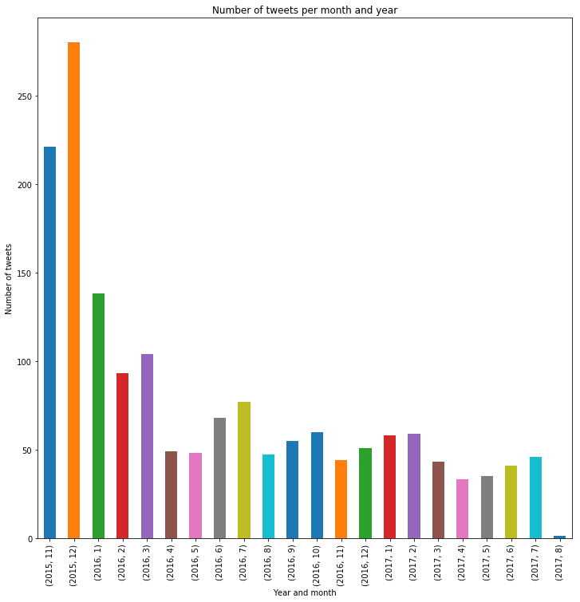

```python
# Create bar chart of number of tweets per month and year
plt.figure(figsize = (12, 12))
twitter_archive_clean['tweet_id'].groupby([twitter_archive_clean.timestamp.dt.year, twitter_archive_clean.timestamp.dt.month]).agg('count').plot(kind = 'bar')
plt.xlabel('Year and month')
plt.ylabel('Number of tweets')
plt.title('Number of tweets per month and year')
plt.show()
```

### Engagement Rate

#### An engagement rate is a metric that measures the level of engagement that a piece of created content is receiving from an audience. It shows how much people interact with the content. This is an important metric to keep an on eye on because higher consumer engagement is a sign of great content ([source](https://trackmaven.com/marketing-dictionary/engagement-rate/)).

#### Engagement rate (%) for a tweet is here defined as the number of retweets and favorites (likes) a post has, divided by the total number of followers the account has, multiplied by 100 to get a percentage number.

```python
# Create column with the engagement rate (%) for each tweet, where engagment is number of retweets and favorites (likes) for a post. To get the engagement rate this is divided by the total number of followers the account has, multiplied by 100 to get a percentage number
twitter_archive_clean['engagement_rate'] = (twitter_archive_clean['retweet_count'] + twitter_archive_clean['favorite_count']) / twitter_archive_clean['followers_count'] * 100
```

```python
twitter_archive_clean['engagement_rate'].describe()
```

```
count    1651.000000
mean        0.159347
std         0.241996
min         0.001229
25%         0.036678
50%         0.075853
75%         0.192925
max         3.322495
Name: engagement_rate, dtype: float64
```

#### On Twitter, an engagement rate between 0% and 0.02% is considered to be low. Engagement rates between 0.02% and 0.09% are considered to be good and an engagement rate between 0.09% and 0.33% is considered to be high ([source](https://blog.scrunch.com/what-is-a-good-engagement-rate-on-twitter)).

#### The table above shows that the avgerage engagement rate for a tweet with an image and rating of a dog posted by WeRateDogs is 0.159%, which lies within the range that is concidered to be a high engagement rate.

```python
# Select row with lowest engagement rate, it did not work to filter by engagement_rate value so I filtered by index number instead
twitter_archive_clean[twitter_archive_clean.index == 2339]
```

|  | tweet_id | timestamp | source | text | expanded_urls | rating_numerator | rating_denominator | name | jpg_url | img_num | retweet_count | favorite_count | followers_count | dog_stage | dog_breed_prediction | dog_breed_confidence_level | engagement_rate |
| --- | --- | --- | --- | --- | --- | --- | --- | --- | --- | --- | --- | --- | --- | --- | --- | --- | --- |
| 2339 | 666102155909144576 | 2015-11-16 03:55:04 | Twitter for iPhone | Oh my. Here you are seeing an Adobe Setter giving birth to twins!!! The world is an amazing place. 11/10 https://t.co/11LvqN4WLq | https://twitter.com/dog_rates/status/666102155909144576/photo/1 | 11.0 | 10.0 | None | https://pbs.twimg.com/media/CT54YGiWUAEZnoK.jpg | 1 | 12 | 80 | 7486905 | None | English setter | 30 | 0.001229 |

```python
# Reference for inserting tweets into notebook (below code block): https://github.com/jupyter/notebook/issues/2790
```

```python
%%html
<blockquote class="twitter-tweet" data-lang="en"><p lang="en" dir="ltr">Oh my. Here you are seeing an Adobe Setter giving birth to twins!!! The world is an amazing place. 11/10 <a href="https://t.co/11LvqN4WLq">pic.twitter.com/11LvqN4WLq</a></p>&mdash; WeRateDogs™ (@dog_rates) <a href="https://twitter.com/dog_rates/status/666102155909144576?ref_src=twsrc%5Etfw">November 16, 2015</a></blockquote>
<script async src="https://platform.twitter.com/widgets.js" charset="utf-8"></script>
```

> Oh my. Here you are seeing an Adobe Setter giving birth to twins!!! The world is an amazing place. 11/10 [pic.twitter.com/11LvqN4WLq](https://t.co/11LvqN4WLq)

> — WeRateDogs™ (@dog_rates) [November 16, 2015](https://twitter.com/dog_rates/status/666102155909144576?ref_src=twsrc%5Etfw)

#### Above table and tweet image shows the tweet posted by WeRateDogs and included in the dataset that has the lowest engagement rate (0.0012%).

```python
# Select row with highest engagement rate, it did not work to filter by engagement_rate value so I filtered by index number instead
twitter_archive_clean[twitter_archive_clean.index == 1039]
```

|  | tweet_id | timestamp | source | text | expanded_urls | rating_numerator | rating_denominator | name | jpg_url | img_num | retweet_count | favorite_count | followers_count | dog_stage | dog_breed_prediction | dog_breed_confidence_level | engagement_rate |
| --- | --- | --- | --- | --- | --- | --- | --- | --- | --- | --- | --- | --- | --- | --- | --- | --- | --- |
| 1039 | 744234799360020481 | 2016-06-18 18:26:18 | Twitter for iPhone | Here's a doggo realizing you can stand in a pool. 13/10 enlightened af (vid by Tina Conrad) https://t.co/7wE9LTEXC4 | https://twitter.com/dog_rates/status/744234799360020481/video/1 | 13.0 | 10.0 | None | https://pbs.twimg.com/ext_tw_video_thumb/744234667679821824/pu/img/1GaWmtJtdqzZV7jy.jpg | 1 | 83961 | 164789 | 7486844 | Doggo | Labrador retriever | 83 | 3.322495 |

```python
%%html
<blockquote class="twitter-tweet" data-lang="en"><p lang="en" dir="ltr">Here&#39;s a doggo realizing you can stand in a pool. 13/10 enlightened af (vid by Tina Conrad) <a href="https://t.co/7wE9LTEXC4">pic.twitter.com/7wE9LTEXC4</a></p>&mdash; WeRateDogs™ (@dog_rates) <a href="https://twitter.com/dog_rates/status/744234799360020481?ref_src=twsrc%5Etfw">June 18, 2016</a></blockquote>
<script async src="https://platform.twitter.com/widgets.js" charset="utf-8"></script>
```

> Here's a doggo realizing you can stand in a pool. 13/10 enlightened af (vid by Tina Conrad) [pic.twitter.com/7wE9LTEXC4](https://t.co/7wE9LTEXC4)

> — WeRateDogs™ (@dog_rates) [June 18, 2016](https://twitter.com/dog_rates/status/744234799360020481?ref_src=twsrc%5Etfw)

#### Above table and tweet image shows the tweet posted by WeRateDogs and included in the dataset that has the highest engagement rate (3.32%), which is an incredibly high engagement rate of a twitter post. Maybe the tweet is so popular becuase it includes a video and not only a photo.

### Engagement Rate over time

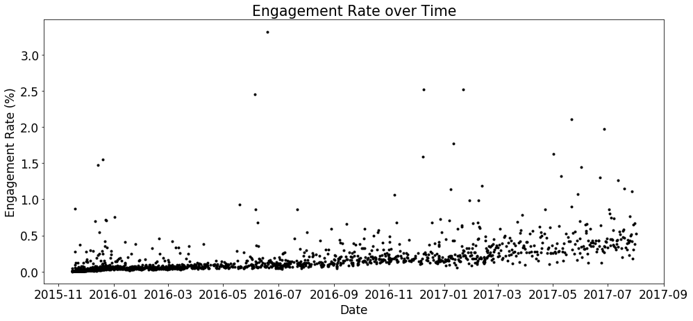

```python
# Scatter plot of engagement rate over time
# Reference: https://jakevdp.github.io/PythonDataScienceHandbook/04.02-simple-scatter-plots.html
plt.rcParams.update({'font.size': 17})
plt.figure(figsize = (16, 7))
plt.plot(twitter_archive_clean['timestamp'], twitter_archive_clean['engagement_rate'], '.', color = 'black');
plt.xlabel('Date')
plt.ylabel('Engagement Rate (%)')
plt.title('Engagement Rate over Time')
plt.show()
```

#### This scatter plot shows the engagement rate over time, one dot represents the engagement rate of one tweet. We can see that there are some extreme cases where the engagement rate is very high relative to all tweets in the dataset. The engagement rate appears to have increased slightly over time and also the variation in engagement rates have become greater, meanwhile the number of tweets have become fewer.

### Dog Breeds

#### The most common dog breed included in tweets from WeRateDogs is the Golden retriever (9.39% of all tweets included in dataset).

```python
# Dog breed distribution in percent
# Reference: https://stackoverflow.com/questions/50558458/pandas-percentage-by-value-in-a-column
twitter_archive_clean['dog_breed_prediction'].value_counts(normalize = True) * 100
```

```
Golden retriever                  9.388250
Labrador retriever                6.420351
Pembroke                          5.693519
Chihuahua                         5.330103
Pug                               3.694730
Toy poodle                        3.028468
Chow                              2.846760
Samoyed                           2.543913
Pomeranian                        2.483343
Malamute                          1.998789
Chesapeake bay retriever          1.877650
Cocker spaniel                    1.817081
French bulldog                    1.817081
Miniature pinscher                1.393095
Eskimo dog                        1.332526
German shepherd                   1.271956
Cardigan                          1.271956
Staffordshire bullterrier         1.211387
Beagle                            1.211387
Siberian husky                    1.211387
Shih-tzu                          1.211387
Maltese dog                       1.150818
Shetland sheepdog                 1.090248
Rottweiler                        1.090248
Lakeland terrier                  1.029679
Italian greyhound                 1.029679
Basset                            1.029679
Kuvasz                            0.969110
West highland white terrier       0.969110
American staffordshire terrier    0.908540
Great pyrenees                    0.908540
Old english sheepdog              0.847971
Pekinese                          0.847971
Kelpie                            0.787402
Vizsla                            0.787402
Schipperke                        0.787402
Boston bull                       0.726832
Dalmatian                         0.726832
Airedale                          0.726832
Norwegian elkhound                0.666263
```

[output cut: 60 more lines]

```
Australian terrier                0.121139
Groenendael                       0.121139
Black-and-tan coonhound           0.121139
Sussex spaniel                    0.121139
Afghan hound                      0.121139
Scotch terrier                    0.060569
Entlebucher                       0.060569
Clumber                           0.060569
Irish wolfhound                   0.060569
Standard schnauzer                0.060569
Bouvier des flandres              0.060569
Silky terrier                     0.060569
Japanese spaniel                  0.060569
Undefined                         0.000000
Name: dog_breed_prediction, dtype: float64
```

### Dog Breeds and Engagement Rate

#### The dog breed with the highest engagement rate is the Bedlington terrier which has an average engagement score of 0.43%.

```python
# Table of average engagement score per dog breed
twitter_archive_clean.groupby('dog_breed_prediction').engagement_rate.mean().sort_values(ascending = False)
```

```
dog_breed_prediction
Bedlington terrier                0.428984
Afghan hound                      0.388929
Saluki                            0.376053
French bulldog                    0.332364
Bouvier des flandres              0.287996
Flat-coated retriever             0.273852
Black-and-tan coonhound           0.271581
Irish water spaniel               0.267499
Whippet                           0.253394
English springer                  0.250931
Standard poodle                   0.249172
Cocker spaniel                    0.240517
Leonberg                          0.240447
Samoyed                           0.239728
Mexican hairless                  0.228947
Eskimo dog                        0.228491
Lakeland terrier                  0.219180
Border terrier                    0.217723
Great pyrenees                    0.216669
Cardigan                          0.212953
Golden retriever                  0.211515
Tibetan mastiff                   0.209033
Labrador retriever                0.207597
Giant schnauzer                   0.193248
Norwegian elkhound                0.189563
Basset                            0.188317
Weimaraner                        0.187715
Pembroke                          0.184475
Australian terrier                0.182065
Malamute                          0.181873
Norwich terrier                   0.178982
Irish setter                      0.178473
Bloodhound                        0.173980
German shepherd                   0.166871
Chesapeake bay retriever          0.163982
Greater swiss mountain dog        0.163397
Kelpie                            0.161961
Chow                              0.160135
Briard                            0.159672
```

[output cut: 61 more lines]

```
Maltese dog                       0.053472
Toy terrier                       0.051361
Lhasa                             0.044534
Entlebucher                       0.043383
Basenji                           0.043319
Welsh springer spaniel            0.041593
Scottish deerhound                0.040488
Standard schnauzer                0.037706
Tibetan terrier                   0.030530
Irish wolfhound                   0.030133
Japanese spaniel                  0.023080
Groenendael                       0.018359
Brabancon griffon                 0.014986
Undefined                              NaN
Name: engagement_rate, dtype: float64
```